# Data Analysis Project

## Data set analyzed: tmdb-movies.csv

## Questions posed:

Since I am analyzing a movie data set, I will be trying to examine this as an entertainment service, such as Netflix or Amazon Video, would. Thus, I want to investigate which factors influence which movies will be the most popular and most highly viewed. This will help me to generate the most revenue and give my viewers the best experience possible.  
So my fundamental question is this: Which factors most strongly influence the popularity of a movie?  
We can derive some further questions from this most fundamental one: Are more recently released movies more popular?  
Do higher budget films tend to be more popular?  
Does runtime affect the popularity of a movie?  
Do the genres of a movie affect its popularity?  
Do genres from certain time periods have a higher popularity rating than other genres of the same time period?  
Do all years have the same or similar amounts of movies stored in this database?  
These are just some guide questions and I will not be answering them all necesairly.

## Terms:

I would like to label some terms, both for my future self and for anyone else who will be examing this document.

### gbo = dataframe group by object. Used as a suffix extension (data_gbo)

### dict = dictionary. Used as suffix extension (data_dict)

## Important Note:

As I have gone through the process of analyzing this data, I have learned how to do it more efficiently. You will see this progression. This progression is mainly in the functions I wrote to wrangle and display data more effectively. For the blocks of code before I wrote and implemented these functions I chose not to go back and revise the code for the purpose of seeing this progression. Often I thought at first that it would just be easier to skip writing a function and do all the leg work myself. However, as my analysis grew increasingly complex, I realized it would be much easier just to have a function do the work.

Also, you'll notice inconsistencies in my code (such as how I named lists and dataframes e.g. swtiching from '' to "" in my lists. Again, I could have gone back and made the code completely consistent but I chose not to because I wanted the my progression and code development to be evident.

## Let's get started

```python
import pandas as pd
import numpy as np
import matplotlib as mpl
import matplotlib.pyplot as plt
import scipy as sp
%matplotlib inline
```

```python
movies_df = pd.read_csv('tmdb-movies.csv')
```

## I will keep all functions used here for organization

```python
def find_rows(movie_list):
    """Finds rows for each movie in movie_rows. Meant to be used with create_dataframe().
    Returns a list of row numbers."""
    rows = []
    for movie in movie_list:
        row_num = int(movies_df.loc[movies_df['original_title'] == movie].index[0])
        rows.append(row_num)
    return rows
```

```python
def find_mean_year_popularity(year_list):
    """Finds the mean popularities for years in a list. Returns a list of means.
    Meant to be used with create_dataframe()."""
    popularity_list = []
    for year in year_list:
        popularity = movies_df.groupby('release_year')\
                ['popularity'].get_group(year).mean()
        popularity_list.append(popularity)
    return np.asarray(popularity_list)
```

```python
def create_dataframe(movie_list):
    """Takes a list of movies and returns a pandas DataFrame of the following form:
    DataFrame = ({
    'title':['one', 'two', 'three'...]
    'release_year':['2000', '2001', '2002'...]
    'popularity':[1,2,3...]
    'mean_year_popularity':[1,2,3]
    })
    Movies in list must be strings and valid movie titles in the movies_df dataframe.
    Ideally this function will be used for movies in one series, but it could be used
    for any movies. And really, any column could be added to this function.
    """
    new_df = pd.DataFrame({
        'title':[],
        'release_year':[],
        'popularity':[],
        'mean_year_popularity':[],
        'vote_count':[],
        'vote_average':[]
    })
    rows = find_rows(movie_list)
    new_df['title'] = movies_df.iloc[rows]['original_title']
    new_df['release_year'] = movies_df.iloc[rows]['release_year']
    release_years = list(movies_df.iloc[rows]['release_year'])
    new_df['popularity'] = movies_df.iloc[rows]['popularity']
    year_popularities = find_mean_year_popularity(release_years)
    new_df['mean_year_popularity'] = year_popularities
    new_df['vote_count'] = movies_df.iloc[rows]['vote_count']
    new_df['vote_average'] = movies_df.iloc[rows]['vote_average']
    return new_df

# This function took forever to figure out!
# Now, Udacity people, I know I'm not supposed to use lists and for loops. However, I have
# clearly demonstrated competence with vectorized operations with parts of this function.
# I tried to accomplish the entire thing with pandas data structures and I kept running into
# error after error. Using for loops and lists is the only way I found to make this code work.
```

```python
def find_movies_by_title(title):
    """Returns any movie in which the title argument is at least partially present.
    Be careful if looking for movies in a series because sometimes the main title
    is not at all present in the title for some movies."""
    return movies_df[movies_df['original_title'].str.contains(title)]
```

```python
def find_movies_by_search(column, value):
    """Retruns any movie for which the value in the column is equal to the
    value searched for. The two arguments must be exactly equal."""
    return movies_df[movies_df[column] == value]
```

```python
def create_pop_plot(dataframe, series_title):
    """Creates a bar graph for a given data set comparing the popularity and
    mean_year_popularity for each movie in the data set."""
    new_plot = dataframe.plot(dataframe['title'],['popularity','mean_year_popularity']
                                 , kind='bar')
    new_plot.set_xlabel('Movie Title')
    new_plot.set_ylabel('Popularity')
    new_plot.set_title('Popularity and average year popularity for {} films'.format(series_title))
    return new_plot
```

```python
def popularity_score(dataframe):
    """Takes a dataframe of a series of movies as input and outputs a score of the mean
    of how popular each movie is compared to the mean popularity for each movie's year.
    The higher the score the higher in general each movie's popularity is compared to its
    year's mean popularity. If a score is negative then that means the average popularities
    of the movies in the series are lower than the average popularities for their
    respective years."""
    popularity_mean = dataframe['popularity'].mean()
    mean_year_popularity_mean = dataframe['mean_year_popularity'].mean()
    return popularity_mean - mean_year_popularity_mean
```

```python
def corr_coef(series_dataframe):
    """Takes as input a series dataframe and returns the correlation coefficient between
    the popularities and mean_year_popularities for each movie."""
    return series_dataframe['popularity'].corr(series_dataframe['mean_year_popularity'])
```

```python
def standardize_data(dataframe):
    """Standardizes data to allow data of different metrics to be compared."""
    return (dataframe - (dataframe.mean()))/dataframe.std()
```

```python
movies_df.head()

# I'm keeping this view of the data frame here for reference.
```

|  | id | imdb_id | popularity | budget | revenue | original_title | cast | homepage | director | tagline | ... | overview | runtime | genres | production_companies | release_date | vote_count | vote_average | release_year | budget_adj | revenue_adj |
| --- | --- | --- | --- | --- | --- | --- | --- | --- | --- | --- | --- | --- | --- | --- | --- | --- | --- | --- | --- | --- | --- |
| 0 | 135397 | tt0369610 | 32.985763 | 150000000 | 1513528810 | Jurassic World | Chris Pratt\|Bryce Dallas Howard\|Irrfan Khan\|Vi... | http://www.jurassicworld.com/ | Colin Trevorrow | The park is open. | ... | Twenty-two years after the events of Jurassic ... | 124 | Action\|Adventure\|Science Fiction\|Thriller | Universal Studios\|Amblin Entertainment\|Legenda... | 6/9/15 | 5562 | 6.5 | 2015 | 1.379999e+08 | 1.392446e+09 |
| 1 | 76341 | tt1392190 | 28.419936 | 150000000 | 378436354 | Mad Max: Fury Road | Tom Hardy\|Charlize Theron\|Hugh Keays-Byrne\|Nic... | http://www.madmaxmovie.com/ | George Miller | What a Lovely Day. | ... | An apocalyptic story set in the furthest reach... | 120 | Action\|Adventure\|Science Fiction\|Thriller | Village Roadshow Pictures\|Kennedy Miller Produ... | 5/13/15 | 6185 | 7.1 | 2015 | 1.379999e+08 | 3.481613e+08 |
| 2 | 262500 | tt2908446 | 13.112507 | 110000000 | 295238201 | Insurgent | Shailene Woodley\|Theo James\|Kate Winslet\|Ansel... | http://www.thedivergentseries.movie/#insurgent | Robert Schwentke | One Choice Can Destroy You | ... | Beatrice Prior must confront her inner demons ... | 119 | Adventure\|Science Fiction\|Thriller | Summit Entertainment\|Mandeville Films\|Red Wago... | 3/18/15 | 2480 | 6.3 | 2015 | 1.012000e+08 | 2.716190e+08 |
| 3 | 140607 | tt2488496 | 11.173104 | 200000000 | 2068178225 | Star Wars: The Force Awakens | Harrison Ford\|Mark Hamill\|Carrie Fisher\|Adam D... | http://www.starwars.com/films/star-wars-episod... | J.J. Abrams | Every generation has a story. | ... | Thirty years after defeating the Galactic Empi... | 136 | Action\|Adventure\|Science Fiction\|Fantasy | Lucasfilm\|Truenorth Productions\|Bad Robot | 12/15/15 | 5292 | 7.5 | 2015 | 1.839999e+08 | 1.902723e+09 |
| 4 | 168259 | tt2820852 | 9.335014 | 190000000 | 1506249360 | Furious 7 | Vin Diesel\|Paul Walker\|Jason Statham\|Michelle ... | http://www.furious7.com/ | James Wan | Vengeance Hits Home | ... | Deckard Shaw seeks revenge against Dominic Tor... | 137 | Action\|Crime\|Thriller | Universal Pictures\|Original Film\|Media Rights ... | 4/1/15 | 2947 | 7.3 | 2015 | 1.747999e+08 | 1.385749e+09 |

5 rows × 21 columns

## Cleaning up data

```python
len(find_movies_by_search('budget', 0))
```

```
5696
```

```python
len(find_movies_by_search('revenue', 0))
```

```
6016
```

There are many movies for which their recorded budget and revenue are 0. If I chose to work with these aspects of the data then it would lead to errant conclusions. Therefore, I'll remove them from the dataframe. Also, there are several other aspects of the data that I don't care about or have no benefit in keeping around. Data aspects such as the home page and the imdb_id (among others). I will remove these too.

```python
movies_df = movies_df.drop(['imdb_id', 'budget', 'revenue', 'homepage',
               'id', 'tagline', 'budget_adj', 'revenue_adj'], axis=1)
```

[output not shown]

```python
movies_df
```

[output not shown]

10866 rows × 13 columns

## How does the popularity releate to the release year?

```
Text(0.5,1,'Mean popularity for movies by year')
```

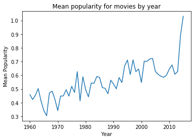

```python
release_year_gbo = movies_df.groupby('release_year')
popularity_by_year = release_year_gbo['popularity']
plt.plot(popularity_by_year.mean())
plt.xlabel('Year')
plt.ylabel('Mean Popularity')
plt.title('Mean popularity for movies by year')
```

So here we have the mean popularity by year from 1960 to 2015. The popularity gradually increases, with some fluxuation, as time increases, until you hit about 2013 where it sky rockets. Perhaps showing the max value by year will shed some more light on this information.

```python
popularity_by_year.max()
```

```
release_year
1960     2.610362
1961     2.631987
1962     3.170651
1963     2.508235
1964     3.153791
1965     1.910465
1966     1.227582
1967     2.550704
1968     3.309196
1969     1.778746
1970     1.936962
1971     3.072555
1972     5.738034
1973     2.272486
```

[output cut: 43 more lines]

Looking at this information, we see that the movie with the highest popularity per year increases fairly regularly over time. However, when we get to 2014 and 2015, the numbers suddenly sky rocket. This data was collected in 2015, which means that the most popular movies at a given time tend to be those produced within a year or two. Looking at this data, you can also gain a sense for which years were not great for film.

So for the most part, the data is relatively steady -other than the most recent two years. There is one year I'd like to examine because it's most popular movie is extraordinairly high. That year is 1977. Now, my guess is that the movie causing this spike is Star Wars IV (the first one ever made). Lets take a look.

```python
movies_df.loc[(movies_df['release_year'] == 1977) & (movies_df['popularity'] == 12.037933)]

# It's not fully necessary to search for the release year and the popularity, but I chose to do it
# this way becasue it is a little more clear than just looking for the popularity. Plus, it is possible,
# but unlikely, that there are multiple movies with this popularity value.
```

|  | popularity | original_title | cast | director | keywords | overview | runtime | genres | production_companies | release_date | vote_count | vote_average | release_year |
| --- | --- | --- | --- | --- | --- | --- | --- | --- | --- | --- | --- | --- | --- |
| 1329 | 12.037933 | Star Wars | Mark Hamill\|Harrison Ford\|Carrie Fisher\|Peter ... | George Lucas | android\|galaxy\|hermit\|death star\|lightsaber | Princess Leia is captured and held hostage by ... | 121 | Adventure\|Action\|Science Fiction | Lucasfilm\|Twentieth Century Fox Film Corporation | 3/20/77 | 4428 | 7.9 | 1977 |

Ah, just as I predicted. It makes sense, really, that this is the movie causing the spike; this is one of the most iconic movies of all time, plus its sequel *Star Wars: The Force Awakens* came out in 2015. Since this data was collected in 2015, I'd say more people than average were watching Star Wars in preparation for it's sequel. And now I'm curious. I want to see how the other Star Wars movies compare. If they're all at the top of their popularities for their respective years or not. More on this later.

Getting back to the fundamental question, which factors most strongly influence the popularity of a movie, we already have a solid answer. **Time**, more specifically the year released, has a very strong influence on which movies will be most popular.

## Star Wars films

So as I found before, the original Star Wars film was far more popular than any other film for the span of a few decades. I attribute this to the fact that Star Wars is one of the most iconic films ever made and that a new Star Wars movie had come out in the same year this data was collected. Now I also want to see how the other Star Wars films stack up for their years. I'll start by examining how popular each film is and see where the trail leads.

### Star Wars The Empire Strikes Back (1980)

```python
movies_df.loc[(movies_df['release_year'] == 1980)].head()
```

|  | popularity | original_title | cast | director | keywords | overview | runtime | genres | production_companies | release_date | vote_count | vote_average | release_year |
| --- | --- | --- | --- | --- | --- | --- | --- | --- | --- | --- | --- | --- | --- |
| 7309 | 5.488441 | The Empire Strikes Back | Mark Hamill\|Harrison Ford\|Carrie Fisher\|Billy ... | Irvin Kershner | rebel\|asteroid\|space battle\|snow storm\|space c... | The epic saga continues as Luke Skywalker, in ... | 124 | Adventure\|Action\|Science Fiction | Lucasfilm\|Twentieth Century Fox Film Corporation | 1/1/80 | 3954 | 8.0 | 1980 |
| 7310 | 2.432001 | The Shining | Jack Nicholson\|Shelley Duvall\|Danny Lloyd\|Scat... | Stanley Kubrick | hotel\|isolation\|hotelier\|colorado\|maze | Jack Torrance accepts a caretaker job at the O... | 144 | Horror\|Thriller | Warner Bros.\|Peregrine | 5/22/80 | 1894 | 7.9 | 1980 |
| 7311 | 1.636256 | Airplane! | Robert Hays\|Julie Hagerty\|Kareem Abdul-Jabbar\|... | Jim Abrahams\|David Zucker\|Jerry Zucker | chicago\|alcohol\|cataclysm\|guitar\|medicine | Still craving for the love of his life, ex-Air... | 88 | Comedy\|Romance | Paramount Pictures | 7/2/80 | 618 | 7.0 | 1980 |
| 7312 | 1.607219 | The Blues Brothers | Dan Aykroyd\|John Belushi\|James Brown\|Cab Callo... | John Landis | dancing\|prison\|chicago\|country music\|nun | Jake Blues is just out of jail, and teams up w... | 133 | Music\|Comedy\|Action\|Crime | Universal Pictures | 6/17/80 | 614 | 7.3 | 1980 |
| 7313 | 1.392663 | The Blue Lagoon | Brooke Shields\|Christopher Atkins\|Leo McKern\|W... | Randal Kleiser | sexual identity\|shipwreck\|lovers\|stranded\|maro... | Two small children and a ship's cook survive a... | 104 | Romance\|Adventure\|Drama | Columbia Pictures Corporation | 7/5/80 | 172 | 5.8 | 1980 |

### Star Wars The Return of the Jedi (1983)

```python
movies_df.loc[(movies_df['release_year'] == 1983)].head()
```

|  | popularity | original_title | cast | director | keywords | overview | runtime | genres | production_companies | release_date | vote_count | vote_average | release_year |
| --- | --- | --- | --- | --- | --- | --- | --- | --- | --- | --- | --- | --- | --- |
| 7987 | 4.828854 | Return of the Jedi | Mark Hamill\|Harrison Ford\|Carrie Fisher\|Billy ... | Richard Marquand | rebel\|emperor\|space battle\|matter of life and ... | As Rebel leaders map their strategy for an all... | 135 | Adventure\|Action\|Science Fiction | Lucasfilm\|Twentieth Century Fox Film Corporation | 5/23/83 | 3101 | 7.8 | 1983 |
| 7988 | 3.178818 | Scarface | Al Pacino\|Steven Bauer\|Michelle Pfeiffer\|Mary ... | Brian De Palma | miami\|corruption\|capitalism\|cuba\|prohibition | After getting a green card in exchange for ass... | 170 | Action\|Crime\|Drama\|Thriller | Universal Pictures | 12/8/83 | 1741 | 7.8 | 1983 |
| 7989 | 1.774018 | Never Say Never Again | Sean Connery\|Kim Basinger\|Klaus Maria Brandaue... | Irvin Kershner | video game\|spy\|bahamas\|british\|stealing | James Bond returns as the secret agent 007 one... | 134 | Adventure\|Action\|Thriller | PSO International\|TaliaFilm II Productions\|Woo... | 10/7/83 | 183 | 5.8 | 1983 |
| 7990 | 1.575742 | Octopussy | Roger Moore\|Maud Adams\|Louis Jourdan\|Kristina ... | John Glen | atomic bomb\|eastern block\|crocodile\|secret int... | James Bond is sent to investigate after a fell... | 131 | Adventure\|Action\|Thriller | Eon Productions | 6/5/83 | 289 | 5.9 | 1983 |
| 7991 | 1.494805 | A Christmas Story | Melinda Dillon\|Darren McGavin\|Peter Billingsle... | Bob Clark | holiday\|nostalgia\|young boy\|bb gun\|essay | The comic mishaps and adventures of a young bo... | 94 | Comedy\|Family | Metro-Goldwyn-Mayer (MGM)\|Christmas Tree Films | 11/18/83 | 186 | 7.1 | 1983 |

So these two movies have been the most popular of their respective years. Let's see what happens when we examine the Star Wars movies that have been traditionally less liked.

### Star Wars The Phantom Menace (1999)

```python
movies_df.loc[(movies_df['release_year'] == 1999)].head()
```

|  | popularity | original_title | cast | director | keywords | overview | runtime | genres | production_companies | release_date | vote_count | vote_average | release_year |
| --- | --- | --- | --- | --- | --- | --- | --- | --- | --- | --- | --- | --- | --- |
| 2409 | 8.947905 | Fight Club | Edward Norton\|Brad Pitt\|Meat Loaf\|Jared Leto\|H... | David Fincher | support group\|dual identity\|nihilism\|rage and ... | A ticking-time-bomb insomniac and a slippery s... | 139 | Drama | Regency Enterprises\|Fox 2000 Pictures\|Taurus F... | 10/14/99 | 5923 | 8.1 | 1999 |
| 2410 | 7.753899 | The Matrix | Keanu Reeves\|Laurence Fishburne\|Carrie-Anne Mo... | Lilly Wachowski\|Lana Wachowski | saving the world\|artificial intelligence\|man v... | Set in the 22nd century, The Matrix tells the ... | 136 | Action\|Science Fiction | Village Roadshow Pictures\|Groucho II Film Part... | 3/30/99 | 6351 | 7.8 | 1999 |
| 2411 | 3.555720 | American Beauty | Kevin Spacey\|Annette Bening\|Thora Birch\|Wes Be... | Sam Mendes | adultery\|coming out\|loss of father\|first time\|... | Lester Burnham, a depressed suburban father in... | 122 | Drama | DreamWorks SKG\|Jinks/Cohen Company | 9/15/99 | 1756 | 7.7 | 1999 |
| 2412 | 3.526029 | Star Wars: Episode I - The Phantom Menace | Liam Neeson\|Ewan McGregor\|Natalie Portman\|Jake... | George Lucas | prophecy\|senate\|queen\|taskmaster\|galaxy | Anakin Skywalker, a young slave strong with th... | 136 | Adventure\|Action\|Science Fiction | Lucasfilm | 5/19/99 | 2823 | 6.3 | 1999 |
| 2413 | 2.943770 | The Mummy | Brendan Fraser\|Rachel Weisz\|John Hannah\|Arnold... | Stephen Sommers | library\|secret passage\|cairo\|egypt\|pastor | Dashing legionnaire Rick O'Connell and Beni, h... | 124 | Adventure\|Fantasy\|Horror\|Action\|Thriller | Universal Pictures\|Alphaville Films | 5/6/99 | 1562 | 6.3 | 1999 |

Ooh, yeah, not as great for this Star Wars, ranking at the 4th most popular film. But still, 4th isn't too bad when there are 224 movies to choose from in this year.

### Star Wars Attack of the Clones (2002)

```python
movies_df.loc[(movies_df['release_year'] == 2002)]
```

|  | popularity | original_title | cast | director | keywords | overview | runtime | genres | production_companies | release_date | vote_count | vote_average | release_year |
| --- | --- | --- | --- | --- | --- | --- | --- | --- | --- | --- | --- | --- | --- |
| 3911 | 8.095275 | The Lord of the Rings: The Two Towers | Elijah Wood\|Ian McKellen\|Viggo Mortensen\|Liv T... | Peter Jackson | elves\|orcs\|middle-earth (tolkien)\|hobbits\|base... | Frodo and Sam are trekking to Mordor to destro... | 179 | Adventure\|Fantasy\|Action | WingNut Films\|New Line Cinema\|The Saul Zaentz ... | 12/18/02 | 5114 | 7.8 | 2002 |
| 3912 | 6.012584 | Harry Potter and the Chamber of Secrets | Daniel Radcliffe\|Rupert Grint\|Emma Watson\|Kenn... | Chris Columbus | flying car\|witch\|magic language\|car journey\|cu... | Ignoring threats to his life, Harry returns to... | 161 | Adventure\|Fantasy\|Family | 1492 Pictures\|Warner Bros.\|Heyday Films\|MIRACL... | 11/13/02 | 3458 | 7.2 | 2002 |
| 3913 | 4.467513 | Ice Age | Ray Romano\|John Leguizamo\|Denis Leary\|Goran Vi... | Chris Wedge\|Carlos Saldanha | human evolution\|parents kids relationship\|squi... | With the impending ice age almost upon them, a... | 81 | Animation\|Comedy\|Family\|Adventure | Twentieth Century Fox Film Corporation\|Blue Sk... | 3/10/02 | 2270 | 6.9 | 2002 |
| 3914 | 3.628943 | The Bourne Identity | Matt Damon\|Franka Potente\|Chris Cooper\|Clive O... | Doug Liman | paris\|barcelona spain\|assassin\|based on novel\|... | Wounded to the brink of death and suffering fr... | 119 | Action\|Drama\|Mystery\|Thriller | Universal Pictures\|Kennedy/Marshall Company, T... | 6/14/02 | 2601 | 7.1 | 2002 |
| 3915 | 3.326646 | Resident Evil | Milla Jovovich\|Michelle Rodriguez\|Eric Mabius\|... | Paul W.S. Anderson | undercover\|mutant\|dystopia\|conspiracy\|zombies | When a virus leaks from a top-secret facility,... | 100 | Horror\|Action\|Science Fiction | Impact Pictures\|Davis-Films\|New Legacy\|Constan... | 3/15/02 | 1265 | 6.3 | 2002 |
| 3916 | 3.241129 | Spider-Man | Tobey Maguire\|Willem Dafoe\|Kirsten Dunst\|James... | Sam Raimi | loss of lover\|spider\|thanksgiving\|bad boss\|hos... | After being bitten by a genetically altered sp... | 121 | Fantasy\|Action | Columbia Pictures\|Marvel Enterprises | 5/1/02 | 3170 | 6.6 | 2002 |
| 3917 | 3.128314 | Star Wars: Episode II - Attack of the Clones | Ewan McGregor\|Natalie Portman\|Hayden Christens... | George Lucas | senate\|investigation\|army\|death star\|jedi | Ten years after the invasion of Naboo, the gal... | 142 | Adventure\|Action\|Science Fiction | Lucasfilm | 5/15/02 | 2549 | 6.4 | 2002 |
| 3918 | 2.973115 | Catch Me If You Can | Leonardo DiCaprio\|Tom Hanks\|Christopher Walken... | Steven Spielberg | con man\|biography\|fbi agent\|overhead camera sh... | Frank W. Abagnale Jr. is a cunning con man –... | 141 | Drama\|Crime | DreamWorks SKG\|Kemp Company\|Splendid Pictures | 12/25/02 | 2277 | 7.6 | 2002 |
| 3919 | 2.388226 | Men in Black II | Tommy Lee Jones\|Will Smith\|Rip Torn\|Lara Flynn... | Barry Sonnenfeld | saving the world\|secret identity\|sun glasses\|u... | Kay and Jay reunite to provide our best, last ... | 88 | Action\|Adventure\|Comedy\|Science Fiction | Columbia Pictures\|Amblin Entertainment\|Columbi... | 7/3/02 | 1950 | 5.9 | 2002 |
| 3920 | 2.364204 | The Pianist | Adrien Brody\|Thomas Kretschmann\|Frank Finlay\|M... | Roman Polanski | individual\|resistance\|radio station\|war crimes... | The Pianist is a film adapted from the biograp... | 150 | Drama\|War | Bac Films\|Canal+Polska\|Heritage Films\|Studio B... | 9/24/02 | 938 | 7.9 | 2002 |
| 3921 | 2.103595 | Minority Report | Tom Cruise\|Colin Farrell\|Samantha Morton\|Max v... | Steven Spielberg | self-fulfilling prophecy\|evidence\|hologram\|dys... | John Anderton is a top "Precrime" cop in the l... | 145 | Action\|Thriller\|Science Fiction\|Mystery | DreamWorks SKG\|Cruise/Wagner Productions\|Ambli... | 6/20/02 | 1595 | 6.9 | 2002 |
| 3922 | 2.095296 | Lilo & Stitch | Chris Sanders\|Daveigh Chase\|Tia Carrere\|David ... | Dean DeBlois\|Chris Sanders | sister sister relationship\|extraterrestrial te... | A lonely Hawaiian girl named Lilo is being rai... | 85 | Animation | Walt Disney Pictures\|Walt Disney Feature Anima... | 6/21/02 | 681 | 6.9 | 2002 |
| 3923 | 1.955546 | The Transporter | Jason Statham\|Shu Qi\|François Berléand\|Matt ... | Louis Leterrier\|Corey Yuen Kwai | car journey\|transportation\|auto\|human trafficking | Former Special Forces officer, Frank Martin wi... | 92 | Action\|Crime\|Thriller | TF1 Films Productions\|Current Entertainment\|Ca... | 10/2/02 | 1119 | 6.5 | 2002 |
| 3924 | 1.936728 | xXx | Vin Diesel\|Asia Argento\|Marton Csokas\|Samuel L... | Rob Cohen | sports car\|biological weapon\|cold war\|prague | Xander Cage is your standard adrenaline junkie... | 124 | Action | Columbia Pictures\|Original Film\|Revolution Stu... | 8/9/02 | 849 | 5.7 | 2002 |
| 3925 | 1.936492 | Treasure Planet | Joseph Gordon-Levitt\|David Hyde Pierce\|Emma Th... | Ron Clements\|John Musker | cyborg\|based on novel\|space marine\|mutiny\|loss... | When space galleon cabin boy Jim Hawkins disco... | 95 | Adventure\|Animation\|Family\|Fantasy\|Science Fic... | Walt Disney Pictures\|Walt Disney Feature Anima... | 11/26/02 | 545 | 7.0 | 2002 |
| 3926 | 1.846196 | Die Another Day | Pierce Brosnan\|Halle Berry\|Rosamund Pike\|Rick ... | Lee Tamahori | NaN | The ever-daring James Bond taking on a North K... | 133 | Adventure\|Action\|Thriller | Eon Productions | 11/17/02 | 692 | 5.8 | 2002 |
| 3927 | 1.839408 | 28 Days Later... | Cillian Murphy\|Naomie Harris\|Noah Huntley\|Chri... | Danny Boyle | london\|manchester city\|submachine gun\|gas stat... | Twenty-eight days after a killer virus was acc... | 113 | Horror\|Thriller\|Science Fiction | DNA Films\|British Film Council | 10/31/02 | 1015 | 6.9 | 2002 |
| 3928 | 1.809883 | Maid in Manhattan | Jennifer Lopez\|Ralph Fiennes\|Natasha Richardso... | Wayne Wang | hotel\|politician\|mistaken identity\|maid\|single... | A senatorial candidate falls for a hotel maid,... | 105 | Comedy\|Drama\|Romance | Columbia Pictures\|Hughes Entertainment\|Revolut... | 12/12/02 | 281 | 5.7 | 2002 |
| 3929 | 1.778527 | Blade II | Wesley Snipes\|Kris Kristofferson\|Ron Perlman\|L... | Guillermo del Toro | katana\|mutation\|silver\|superhero\|tragic villain | A rare mutation has occurred within the vampir... | 117 | Science Fiction\|Horror\|Action\|Thriller | New Line Cinema\|Marvel Entertainment, LLC\|Amen... | 3/22/02 | 961 | 6.1 | 2002 |
| 3930 | 1.751530 | Gangs of New York | Leonardo DiCaprio\|Daniel Day-Lewis\|Cameron Dia... | Martin Scorsese | fire\|irish-american\|immigrant\|gang war\|pickpocket | 1863. America was born in the streets. Amsterd... | 167 | Drama\|History\|Crime | Miramax Films\|Initial Entertainment Group (IEG... | 12/14/02 | 1068 | 6.9 | 2002 |
| 3931 | 1.694723 | Panic Room | Jodie Foster\|Kristen Stewart\|Forest Whitaker\|D... | David Fincher | burglar\|bunker\|housebreaking\|safe\|money | Trapped in their New York brownstone's panic r... | 112 | Crime\|Drama\|Thriller | Columbia Pictures Corporation\|Hofflund/Polone\|... | 3/29/02 | 670 | 6.4 | 2002 |
| 3932 | 1.594587 | Stuart Little 2 | Michael J. Fox\|Geena Davis\|Hugh Laurie\|Jonatha... | Rob Minkoff | mouse\|falcon\|bird\|friendship\|family | Stuart, an adorable white mouse, still lives h... | 78 | Family\|Adventure\|Animation\|Comedy | Columbia Pictures\|Sony Pictures Entertainment | 7/19/02 | 366 | 5.4 | 2002 |
| 3933 | 1.568528 | National Lampoon’s Van Wilder | Ryan Reynolds\|Tara Reid\|Tim Matheson\|Kal Penn\|... | Walt Becker | sex\|college\|doggystyle\|flirting\|exposé | Van Wilder is an outgoing, and extremely popul... | 92 | Comedy\|Romance | Tapestry Films\|Artisan Entertainment | 3/29/02 | 684 | 5.9 | 2002 |
| 3934 | 1.558805 | 8 Mile | Eminem\|Mekhi Phifer\|Brittany Murphy\|Kim Basing... | Curtis Hanson | individual\|street gang\|adolescence\|rap\|hip-hop | The setting is Detroit in 1995. The city is di... | 110 | Drama | Imagine Entertainment\|Mikona Productions GmbH ... | 11/8/02 | 944 | 6.7 | 2002 |
| 3935 | 1.525009 | Mr. Deeds | Adam Sandler\|Winona Ryder\|John Turturro\|Allen ... | Steven Brill | love letter\|new hampshire\|ferrari\|liar\|city co... | When Longfellow Deeds, a small-town pizzeria o... | 96 | Comedy\|Romance | New Line Cinema\|Columbia Pictures Corporation\|... | 6/28/02 | 379 | 5.7 | 2002 |
| 3936 | 1.496493 | Bend It Like Beckham | Parminder Nagra\|Keira Knightley\|Jonathan Rhys ... | Gurinder Chadha | london\|gay\|tradition\|broken engagement\|culture... | Jess Bhamra, the daughter of a strict Indian c... | 112 | Comedy\|Drama\|Romance | Fox Searchlight Pictures\|Kintop Pictures\|Filmf... | 4/11/02 | 309 | 6.0 | 2002 |
| 3937 | 1.494612 | Cinderella II: Dreams Come True | Jennifer Hale\|Rob Paulsen\|Corey Burton\|Andre S... | John Kafka | cinderella\|princess\|anthropomorphic animal\|car... | As a newly crowned princess, Cinderella quickl... | 74 | Animation\|Fantasy\|Romance | Walt Disney Television Animation\|Walt Disney A... | 2/23/02 | 154 | 5.6 | 2002 |
| 3938 | 1.486895 | Two Weeks Notice | Sandra Bullock\|Hugh Grant\|Alicia Witt\|Dana Ive... | Marc Lawrence | new york\|parish hall\|romantic comedy\|lawyer\|bi... | Dedicated environmental lawyer Lucy Kelson goe... | 101 | Romance\|Comedy | Village Roadshow Pictures\|Castle Rock Entertai... | 12/19/02 | 263 | 5.8 | 2002 |
| 3939 | 1.381699 | Signs | Mel Gibson\|Joaquin Phoenix\|Rory Culkin\|Abigail... | M. Night Shyamalan | symbolism\|water\|peasant\|alien life-form\|farm | A family living on a farm finds mysterious cro... | 106 | Drama\|Thriller\|Science Fiction\|Mystery | Kennedy/Marshall Company, The\|Touchstone Pictu... | 8/2/02 | 905 | 6.3 | 2002 |
| 3940 | 1.359987 | The Ring | Naomi Watts\|Martin Henderson\|David Dorfman\|Bri... | Gore Verbinski | island\|videoband\|poltergeist\|telephone\|suspense | It sounded like just another urban legend: A v... | 115 | Horror\|Mystery\|Thriller | DreamWorks SKG\|BenderSpink\|Parkes+MacDonald Im... | 10/18/02 | 810 | 6.4 | 2002 |
| ... | ... | ... | ... | ... | ... | ... | ... | ... | ... | ... | ... | ... | ... |
| 4147 | 0.144924 | Lost in La Mancha | Terry Gilliam\|Tony Grisoni\|Philip A. Patterson... | Keith Fulton\|Louis Pepe | director\|don quixote\|cervantes | Fulton and Pepe's 2000 documentary captures Te... | 93 | Documentary\|Foreign | Quixote Films\|Low Key Productions\|Eastcroft Pr... | 2/11/02 | 31 | 7.0 | 2002 |
| 4148 | 0.143573 | Morvern Callar | Samantha Morton\|Kathleen McDermott\|Linda McGui... | Lynne Ramsay | independent film\|woman director | Following her boyfriend's suicide, supermarket... | 97 | Drama\|Foreign | Company Pictures | 1/1/02 | 12 | 7.0 | 2002 |
| 4149 | 0.140786 | Getting There | Mary-Kate Olsen\|Ashley Olsen\|Billy Aaron Brown... | Steve Purcell | road trip\|twins\|teenager | This film is about Mary-Kate and Ashley turnin... | 90 | Family | NaN | 6/11/02 | 23 | 5.5 | 2002 |
| 4150 | 0.211695 | People I Know | Al Pacino\|Kim Basinger\|Ryan O'Neal\|Téa Leoni\|... | Daniel Algrant | drug addiction\|press\|release from prison\|women... | A New York press agent must scramble when his ... | 100 | Drama\|Thriller | NaN | 11/21/02 | 23 | 5.8 | 2002 |
| 4151 | 0.137005 | Max | John Cusack\|Noah Taylor\|Leelee Sobieski\|Molly ... | Menno Meyjes | infidelity\|controversy | In 1918, a young, disillusioned Adolph Hitler ... | 106 | War\|Drama | Film Council\|Alliance Atlantis Communications\|... | 9/10/02 | 19 | 6.2 | 2002 |
| 4152 | 0.136897 | Ônibus 174 | Yvonne Bezerra de Mello\|Sandro do Nascimento\|R... | José Padilha\|Felipe Lacerda | slum\|rio de janeiro\|bus hijacking\|teacher | Documentary depicts what happened in Rio de Ja... | 150 | Documentary\|Foreign | Zazen Produções | 10/8/02 | 13 | 7.6 | 2002 |
| 4153 | 0.135820 | Le fils | Olivier Gourmet\|Morgan Marinne\|Isabella Soupar... | Jean-Pierre Dardenne\|Luc Dardenne | NaN | A joinery instructor at a rehab center refuses... | 103 | Mystery\|Drama | Les Films Du Fleuve\|Archipel 35\|Radio Télévi... | 5/23/02 | 15 | 5.6 | 2002 |
| 4154 | 0.134028 | Rabbits | Scott Coffey\|Rebekah Del Rio\|Laura Harring\|Nao... | David Lynch | NaN | A story of a group of humanoid rabbits and the... | 42 | Comedy\|Drama\|Fantasy | NaN | 1/1/02 | 21 | 6.2 | 2002 |
| 4155 | 0.128012 | Tuck Everlasting | Alexis Bledel\|William Hurt\|Sissy Spacek\|Jonath... | Jay Russell | NaN | Natalie Babbitt's award winning book for child... | 90 | Fantasy\|Drama\|Science Fiction\|Romance\|Family | Walt Disney Pictures | 10/11/02 | 87 | 6.5 | 2002 |
| 4156 | 0.117779 | Roger Dodger | Campbell Scott\|Jesse Eisenberg\|Isabella Rossel... | Dylan Kidd | new york\|prostitute\|alcohol\|sex\|brothel | After breaking up with his lover and boss, a s... | 106 | Comedy\|Drama | Holedigger Films\|Roger Dodger LLC | 5/9/02 | 25 | 7.1 | 2002 |
| 4157 | 0.111966 | Los lunes al sol | Javier Bardem\|Luis Tosar\|Nieve de Medina\|Enriq... | Fernando León de Aranoa | spain\|bar\|ship\|drama\|friends | After the closure of their shipyard in Norther... | 113 | Drama\|Foreign | Vía Digital\|Eurimages\|Continental Produccione... | 9/27/02 | 16 | 6.5 | 2002 |
| 4158 | 0.111667 | Bang Bang You're Dead | Tom Cavanagh\|Ben Foster\|Randy Harrison\|Janel M... | Guy Ferland | bomb\|high school | Trevor is a troubled high school student, than... | 87 | Drama\|Thriller | Every Guy Productions | 6/7/02 | 14 | 6.8 | 2002 |
| 4159 | 0.115480 | John Carpenter’s Vampires: Los Muertos | Jon Bon Jovi\|Cristián de la Fuente\|Diego Luna... | Tommy Lee Wallace | vampire slayer\|arrow catching\|female villain\|i... | Tough-as-nails vampire hunter Derek Bliss is o... | 93 | Horror\|Thriller\|Action | Screen Gems\|Storm King Productions | 9/23/02 | 18 | 5.2 | 2002 |
| 4160 | 0.108064 | The Third Wheel | Luke Wilson\|Denise Richards\|Jay Lacopo\|Meredit... | Jordan Brady | NaN | The clumsy and shy Stanley is a nice fellow, b... | 87 | Comedy\|Romance | NaN | 5/31/02 | 11 | 6.2 | 2002 |
| 4161 | 0.104804 | Stealing Harvard | Jason Lee\|Tom Green\|Leslie Mann\|Dennis Farina\|... | Bruce McCulloch | robbery\|fool\|studies\|house\|uncle | John and his girlfriend have vowed to marry on... | 85 | Action\|Comedy\|Drama | Columbia Pictures\|Imagine Entertainment\|Revolu... | 9/13/02 | 20 | 4.1 | 2002 |
| 4162 | 0.097758 | 3 zéros | Samuel Le Bihan\|Gérard Lanvin\|LorÃ nt Deutsch... | Fabien Onteniente | soccer | A Fleury-Mérogis, un match de foot a lieu dan... | 97 | Comedy | Bac Films\|TF1 Films Production\|Canal+\|Mandarin... | 4/24/02 | 13 | 5.3 | 2002 |
| 4163 | 0.095114 | Plots with a View | Brenda Blethyn\|Alfred Molina\|Christopher Walke... | Nick Hurran | competition\|small town\|coffin\|politician\|run away | A politician's wife and the mortician who has ... | 94 | Comedy\|Romance | Spice Factory\|Great British Films\|Snowfall Films | 10/4/02 | 16 | 6.5 | 2002 |
| 4164 | 0.090605 | The Century of the Self | Martin Bergmann\|Ann Bernays\|Edward Bernays\|Ann... | Adam Curtis | tv mini-series | A documentary about the rise of psychoanalysis... | 235 | Documentary | British Broadcasting Corporation (BBC)\|RDF Media | 3/17/02 | 14 | 8.3 | 2002 |
| 4165 | 0.029120 | The Master of Disguise | Dana Carvey\|Brent Spiner\|Jennifer Esposito\|Har... | Perry Andelin Blake | aftercreditsstinger\|duringcreditsstinger | A sweet-natured Italian waiter named Pistachio... | 80 | Comedy\|Family | Columbia Pictures\|Revolution Studios\|Happy Mad... | 8/2/02 | 43 | 4.1 | 2002 |
| 4166 | 0.084451 | Sweet Sixteen | Martin Compston\|Annmarie Fulton\|William Ruane\|... | Ken Loach | glasgow\|brother sister relationship\|puberty\|dr... | Determined to have a normal family life once h... | 106 | Crime\|Drama | Alta Films S.A.\|TTornasol Films S.A. | 5/21/02 | 17 | 5.8 | 2002 |
| 4167 | 0.079351 | Deuces Wild | Stephen Dorff\|Fairuza Balk\|Brad Renfro\|Norman ... | Scott Kalvert | gang\|new york city\|drug overdose | 1950s New York City. A bad and bloody gang war... | 96 | Action\|Crime\|Drama\|Romance | United Artists | 5/3/02 | 16 | 5.3 | 2002 |
| 4168 | 0.070257 | Inuyasha: Kagami no Naka no MugenjÅ | Francesco Pezzulli\|Maria Letizia Scifoni\|Fabio... | Toshiya Shinohara | NaN | With their most formidable foe vanquished, Inu... | 99 | Action\|Adventure\|Animation\|Fantasy | Shogakukan Production | 12/22/02 | 10 | 6.2 | 2002 |
| 4169 | 0.076900 | Ping Pong | Yosuke Kubozuka\|Sam Lee\|Nakamura ShidÅ II\|Naot... | Fumihiko Sori | ping pong\|sport\|independent film\|based on mang... | As children, the introverted Smile was being b... | 114 | Comedy\|Drama | NaN | 7/20/02 | 12 | 7.0 | 2002 |
| 4170 | 0.009266 | Is It College Yet? | Tracy Grandstaff\|Wendy Hoopes | Karen Disher | NaN | All vile things must come to an end, and for D... | 90 | Animation\|Comedy | NaN | 1/1/02 | 14 | 7.2 | 2002 |
| 4171 | 0.063246 | VeggieTales: Jonah | Phil Vischer\|Mike Nawrocki\|Tim Hodge\|Lisa Visc... | Mike Nawrocki\|Phil Vischer | NaN | Get ready as Bob the Tomato, Larry the Cucumbe... | 82 | Action\|Adventure\|Animation\|Comedy\|Family | Big Idea Productions | 10/4/02 | 17 | 6.1 | 2002 |
| 4172 | 0.051189 | Wishmaster 4: The Prophecy Fulfilled | Michael Trucco\|Tara Spencer-Nairn\|Jason Thomps... | Chris Angel | NaN | The unspeakable evil of the soul-devouring dji... | 92 | Horror | Overseas FilmGroup\|GFT Entertainment\|Artisan E... | 6/10/02 | 11 | 4.3 | 2002 |
| 4173 | 0.011798 | Kaante | Sanjay Dutt\|Amitabh Bachchan\|Sunil Shetty\|Mahe... | Sanjay Gupta | NaN | Kill, threaten, kidnap, maim, murder, steal...... | 152 | Action\|Drama\|Foreign | NaN | 12/20/02 | 10 | 5.7 | 2002 |
| 4174 | 0.041099 | An Evening with Kevin Smith | Jason Mewes\|Scott Mosier\|Kevin Smith | J.M. Kenny | director\|anecdotes | Kevin Smith interacts in Q&amp;A sessions thro... | 224 | Comedy\|Documentary | NaN | 12/17/02 | 10 | 6.8 | 2002 |
| 4175 | 0.063581 | Biggie and Tupac | Tupac Shakur\|Nick Broomfield\|The Notorious B.I... | Nick Broomfield | rap\|hip-hop\|rap music | In 1997, rap superstars Tupac Shakur and Chris... | 107 | Documentary | NaN | 1/11/02 | 18 | 6.3 | 2002 |
| 4176 | 0.017708 | The Kid Stays in the Picture | Robert Evans\|Eddie Albert\|Francis Ford Coppola... | Nanette Burstein\|Brett Morgen | cocaine\|arranged marriage\|love\|hollywood\|woman... | Documentary about legendary Paramount producer... | 93 | Documentary | Ministry of Propaganda Films\|Woodland Pictures... | 1/18/02 | 10 | 7.4 | 2002 |

266 rows × 13 columns

Surprisingly, this movie is even worse than The Phantom Menace, being ranked 7th.

### Star Wars Revenve of the Sith (2005)

```python
movies_df.loc[(movies_df['release_year'] == 2005)]
```

|  | popularity | original_title | cast | director | keywords | overview | runtime | genres | production_companies | release_date | vote_count | vote_average | release_year |
| --- | --- | --- | --- | --- | --- | --- | --- | --- | --- | --- | --- | --- | --- |
| 6190 | 5.939927 | Harry Potter and the Goblet of Fire | Daniel Radcliffe\|Rupert Grint\|Emma Watson\|Ralp... | Mike Newell | diving\|library\|flying\|fireworks\|cutting the cord | Harry starts his fourth year at Hogwarts, comp... | 157 | Adventure\|Fantasy\|Family | Patalex IV Productions Limited\|Warner Bros.\|He... | 11/5/05 | 3406 | 7.3 | 2005 |
| 6191 | 5.400826 | Batman Begins | Christian Bale\|Michael Caine\|Liam Neeson\|Katie... | Christopher Nolan | martial arts\|dc comics\|crime fighter\|secret id... | Driven by tragedy, billionaire Bruce Wayne ded... | 140 | Action\|Crime\|Drama | DC Comics\|Legendary Pictures\|Warner Bros.\|DC E... | 6/14/05 | 4914 | 7.3 | 2005 |
| 6192 | 3.628726 | The Chronicles of Narnia: The Lion, the Witch ... | William Moseley\|Anna Popplewell\|Skandar Keynes... | Andrew Adamson | saving the world\|witch\|based on novel\|brother ... | Siblings Lucy, Edmund, Susan and Peter step th... | 143 | Adventure\|Family\|Fantasy | Walt Disney\|Walden Media | 12/7/05 | 1402 | 6.5 | 2005 |
| 6193 | 3.617106 | V for Vendetta | Natalie Portman\|Hugo Weaving\|Stephen Rea\|Steph... | James McTeigue | detective\|vatican\|fascism\|satanism\|fascist | In a world in which Great Britain has become a... | 132 | Action\|Thriller\|Fantasy | Studio Babelsberg\|DC Comics\|Virtual Studios\|An... | 12/11/05 | 2670 | 7.6 | 2005 |
| 6194 | 3.520836 | Sin City | Jessica Alba\|Devon Aoki\|Alexis Bledel\|Powers B... | Robert Rodriguez\|Frank Miller\|Quentin Tarantino | dystopia\|based on comic book\|based on graphic ... | Welcome to Sin City. This town beckons to the ... | 124 | Action\|Thriller\|Crime | Dimension Films\|Troublemaker Studios\|Miramax | 3/31/05 | 1691 | 7.1 | 2005 |
| 6195 | 3.508379 | Charlie and the Chocolate Factory | Johnny Depp\|Freddie Highmore\|AnnaSophia Robb\|J... | Tim Burton | london\|father-son relationship\|chocolate\|facto... | A young boy wins a tour through the most magni... | 115 | Adventure\|Comedy\|Family\|Fantasy | Village Roadshow Pictures\|The Zanuck Company\|W... | 7/9/05 | 1826 | 6.5 | 2005 |
| 6196 | 3.457537 | Star Wars: Episode III - Revenge of the Sith | Ewan McGregor\|Natalie Portman\|Hayden Christens... | George Lucas | showdown\|death star\|vision\|cult figure\|hatred | Years after the onset of the Clone Wars, the n... | 140 | Science Fiction\|Adventure\|Action | Lucasfilm | 5/17/05 | 2629 | 7.0 | 2005 |
| 6197 | 3.087036 | The Hitchhiker's Guide to the Galaxy | Martin Freeman\|Zooey Deschanel\|Sam Rockwell\|Mo... | Garth Jennings | bureaucracy\|england\|dolphin\|android\|based on n... | Mere seconds before the Earth is to be demolis... | 109 | Adventure\|Comedy\|Family\|Science Fiction | Spyglass Entertainment\|Everyman Pictures\|Hamme... | 1/15/05 | 780 | 6.6 | 2005 |
| 6198 | 2.623346 | The Island | Ewan McGregor\|Scarlett Johansson\|Djimon Hounso... | Michael Bay | clone\|transplantation\|love of one's life\|dysto... | Lincoln Six-Echo is a resident of a seemingly ... | 136 | Action\|Thriller\|Science Fiction\|Adventure | DreamWorks SKG\|Warner Bros.\|Parkes/MacDonald P... | 7/20/05 | 1027 | 6.4 | 2005 |
| 6199 | 2.444998 | Madagascar | Ben Stiller\|Chris Rock\|David Schwimmer\|Jada Pi... | Eric Darnell\|Tom McGrath | lion\|hippopotamus\|giraffe\|penguin\|zebra | Zoo animals leave the comforts of man-made hab... | 86 | Family\|Animation | DreamWorks SKG\|Pacific Data Images (PDI)\|Dream... | 5/25/05 | 2107 | 6.4 | 2005 |
| 6200 | 2.368513 | Fantastic Four | Ioan Gruffudd\|Jessica Alba\|Chris Evans\|Michael... | Tim Story | flying\|fire\|brother sister relationship\|marria... | During a space voyage, four scientists are alt... | 106 | Action\|Adventure\|Fantasy\|Science Fiction | Twentieth Century Fox Film Corporation\|1492 Pi... | 7/7/05 | 1715 | 5.6 | 2005 |
| 6201 | 2.265330 | Constantine | Keanu Reeves\|Rachel Weisz\|Shia LaBeouf\|Djimon ... | Francis Lawrence | flying\|confession\|exorcism\|archangel gabriel\|h... | John Constantine has literally been to Hell an... | 121 | Drama\|Fantasy\|Horror | Village Roadshow Pictures\|DC Comics\|Lonely Fil... | 2/15/05 | 1049 | 6.5 | 2005 |
| 6202 | 2.248624 | Wedding Crashers | Owen Wilson\|Vince Vaughn\|Christopher Walken\|Ra... | David Dobkin | sailing\|wedding\|fake identity\|lying | John and his buddy, Jeremy are emotional crimi... | 119 | Comedy\|Romance | New Line Cinema\|Tapestry Films\|Avery Pix | 7/14/05 | 795 | 6.3 | 2005 |
| 6203 | 2.220063 | Æon Flux | Charlize Theron\|Marton Csokas\|Jonny Lee Miller... | Karyn Kusama | martial arts\|dystopia\|surrealism\|based on cart... | 400 years into the future, disease has wiped o... | 93 | Action\|Science Fiction | Paramount Pictures\|Lakeshore Entertainment\|MTV... | 11/30/05 | 408 | 5.3 | 2005 |
| 6204 | 2.072050 | The Pacifier | Vin Diesel\|Lauren Graham\|Faith Ford\|Chris Pott... | Adam Shankman | missile\|bodybuilder\|children\|body guard\|scientist | Disgraced Navy SEAL Shane Wolfe is handed a ne... | 95 | Action\|Comedy\|Drama\|Family\|Thriller | Walt Disney Pictures\|Spyglass Entertainment | 3/4/05 | 493 | 5.8 | 2005 |
| 6205 | 1.844731 | War of the Worlds | Tom Cruise\|Dakota Fanning\|Miranda Otto\|Justin ... | Steven Spielberg | post traumatic stress disorder\|new jersey\|air... | The extraordinary battle for the future of hum... | 116 | Adventure\|Thriller\|Science Fiction | Paramount Pictures\|DreamWorks SKG\|Cruise/Wagne... | 6/28/05 | 1238 | 5.9 | 2005 |
| 6206 | 1.813128 | Memoirs of a Geisha | Zhang Ziyi\|Gong Li\|Youki Kudoh\|Tsai Chin\|Suzuk... | Rob Marshall | japan\|prostitute\|sister sister relationship\|br... | A sweeping romantic epic set in Japan in the y... | 145 | Drama\|History\|Romance | DreamWorks SKG\|Spyglass Entertainment\|Columbia... | 12/6/05 | 409 | 7.1 | 2005 |
| 6207 | 1.785950 | The 40 Year Old Virgin | Steve Carell\|Catherine Keener\|Paul Rudd\|Romany... | Judd Apatow | first time\|virgin | Andy Stitzer has a pleasant life with a nice a... | 116 | Comedy\|Romance | Universal Pictures\|Apatow Productions | 8/11/05 | 1236 | 6.2 | 2005 |
| 6208 | 1.766397 | Chicken Little | Zach Braff\|Garry Marshall\|Don Knotts\|Patrick S... | Mark Dindal | fish\|small town\|space marine\|chicken\|alien | When the sky really is falling and sanity has ... | 81 | Animation\|Family\|Comedy | Walt Disney Pictures\|Walt Disney Feature Anima... | 11/4/05 | 542 | 5.6 | 2005 |
| 6209 | 1.726470 | Hitch | Will Smith\|Eva Mendes\|Kevin James\|Amber Vallet... | Andy Tennant | speed date\|romantic comedy\|dating | Dating coach Alex 'Hitch' Hitchens mentors a b... | 118 | Comedy\|Drama\|Romance | Columbia Pictures Corporation\|Overbrook Entert... | 2/10/05 | 1010 | 6.3 | 2005 |
| 6210 | 1.699822 | Transporter 2 | Jason Statham\|Amber Valletta\|Kate Nauta\|Alessa... | Louis Leterrier | martial arts\|war on drugs\|bodyguard\|baby-snatc... | Professional driver Frank Martin is living in ... | 87 | Action\|Thriller\|Crime | Canal Plus\|Twentieth Century Fox Film Corporat... | 8/2/05 | 677 | 6.1 | 2005 |
| 6211 | 1.632638 | Prime | Uma Thurman\|Bryan Greenberg\|Meryl Streep\|Annie... | Ben Younger | new york\|date\|lovesickness\|jewry\|jealousy | A career driven professional from Manhattan is... | 102 | Comedy\|Drama\|Romance | Universal Pictures\|Team Todd\|Prime Film Produc... | 9/21/05 | 139 | 5.5 | 2005 |
| 6212 | 1.610259 | Nanny McPhee | Emma Thompson\|Colin Firth\|Kelly Macdonald\|Thom... | Kirk Jones | loss of mother\|nanny\|education\|wizardry\|children | Widower Cedric Brown (Colin Firth) hires Nanny... | 97 | Fantasy\|Comedy\|Family | Universal Pictures\|Three Strange Angels\|Studio... | 10/21/05 | 355 | 6.1 | 2005 |
| 6213 | 1.592578 | Kingdom of Heaven | Orlando Bloom\|Eva Green\|Jeremy Irons\|Marton Cs... | Ridley Scott | crusade\|epic\|knight\|swordsman\|religious | After his wife dies, a blacksmith named Balian... | 144 | Drama\|Action\|Adventure\|History\|War | Studio Babelsberg\|Twentieth Century Fox Film C... | 5/3/05 | 677 | 6.4 | 2005 |
| 6214 | 1.513147 | Monster-in-Law | Jennifer Lopez\|Jane Fonda\|Michael Vartan\|Wanda... | Robert Luketic | bad mother-in-law\|surgeon\|dogsitter\|falling in... | Office temp Charlotte Cantilini thinks she's f... | 101 | Comedy | New Line Cinema\|Spring Creek Productions\|Bende... | 5/13/05 | 240 | 5.7 | 2005 |
| 6215 | 1.508329 | King Kong | Naomi Watts\|Jack Black\|Adrien Brody\|Thomas Kre... | Peter Jackson | film business\|screenplay\|show business\|film ma... | In 1933 New York, an overly ambitious movie pr... | 187 | Adventure\|Drama\|Action | WingNut Films\|Universal Pictures\|Big Primate P... | 12/14/05 | 1289 | 6.4 | 2005 |
| 6216 | 1.497085 | Be Cool | John Travolta\|Uma Thurman\|Vince Vaughn\|Cedric ... | F. Gary Gray | baseball bat\|widow\|recording contract\|recordin... | Disenchanted with the movie industry, Chili Pa... | 118 | Comedy\|Crime | Double Feature Films\|Jersey Films\|Nina Saxon F... | 3/4/05 | 170 | 5.3 | 2005 |
| 6217 | 1.496807 | Into the Blue | Paul Walker\|Jessica Alba\|Scott Caan\|Ashley Sco... | John Stockwell | diving\|cocaine\|shipwreck\|sailing\|airplane | Red-hot action superstars Paul Walker and Jess... | 110 | Action\|Thriller\|Adventure\|Crime | Columbia Pictures Corporation\|Mandalay Picture... | 9/30/05 | 289 | 5.9 | 2005 |
| 6218 | 1.480854 | Pride & Prejudice | Keira Knightley\|Matthew Macfadyen\|Rosamund Pik... | Joe Wright | bachelor\|prejudice\|suitor\|georgian\|pride | Pride and Prejudice is a humorous story of lov... | 128 | Drama\|Romance | Universal Pictures\|StudioCanal\|Scion Films\|Foc... | 9/16/05 | 749 | 7.6 | 2005 |
| 6219 | 1.475604 | Brokeback Mountain | Heath Ledger\|Jake Gyllenhaal\|Randy Quaid\|Miche... | Ang Lee | gay\|countryside\|homophobia\|loss of lover\|wyoming | Brokeback Mountain is an Ang Lee film about tw... | 134 | Drama\|Romance | River Road Entertainment\|Alberta Film Entertai... | 9/2/05 | 780 | 7.2 | 2005 |
| ... | ... | ... | ... | ... | ... | ... | ... | ... | ... | ... | ... | ... | ... |
| 6524 | 0.100198 | DeVour | Jensen Ackles\|Shannyn Sossamon\|Dominique Swain... | David Winkler | tattoo\|sex\|nudity\|nightmare\|daydream | Friends become increasingly addicted to a vide... | 90 | Horror | Sony Pictures Home Entertainment\|Bigel Enterta... | 5/31/05 | 15 | 4.5 | 2005 |
| 6525 | 0.359890 | Don't Come Knocking | Sam Shepard\|Jessica Lange\|Sarah Polley\|Tim Rot... | Wim Wenders | NaN | Howard Spence has seen better days. Once a big... | 123 | Drama\|Music | Sony Pictures Classics\|Reverse Angle Internati... | 5/19/05 | 11 | 6.0 | 2005 |
| 6526 | 0.097543 | We Feed the World - Essen Global | Jean Ziegler\|Peter Brabeck\|Karl Otrok | Erwin Wagenhofer | globalization\|brazil\|bread\|third world\|anti-gl... | A documentary that exposes the shocking truths... | 96 | Documentary\|Foreign | NaN | 9/10/05 | 11 | 7.5 | 2005 |
| 6527 | 0.294572 | Human Trafficking | Mira Sorvino\|Donald Sutherland\|Robert Carlyle\|... | Christian Duguay | corruption\|eastern europe\|philippines\|small co... | When a sixteen-year-old girl from the Ukraine,... | 176 | Drama | Muse Entertainment Enterprises\|For Sale Produc... | 10/24/05 | 12 | 7.0 | 2005 |
| 6528 | 0.128733 | U2: Vertigo 2005 - Live from Chicago | Bono\|The Edge\|Adam Clayton\| Larry Mullen Jr.\|G... | Hamish Hamilton\|Erica Forstadt | rock and roll\|musical\|tour\|concert\|u2 | The DVD features 23 electric performances, wit... | 139 | Music | Line by Line Productions | 11/14/05 | 10 | 7.6 | 2005 |
| 6529 | 0.092869 | Stone Cold | Tom Selleck\|Jane Adams\|Reg Rogers\|Viola Davis\|... | Robert Harmon | cop\|new england\|jesse stone | Jesse Stone is a former L.A. homicide detectiv... | 87 | Crime\|Drama\|Thriller | Brandman Productions | 2/20/05 | 16 | 6.1 | 2005 |
| 6530 | 0.092724 | Saw Rebirth | Whit Anderson\|Stan Kirsch\|Jeff Shuter\|George W... | Jeff Shuter\|Daniel Viney | NaN | This comic, set in the world of SAW goes back ... | 6 | NaN | NaN | 10/24/05 | 24 | 5.9 | 2005 |
| 6531 | 0.091840 | Boudu | Gérard Depardieu\|Catherine Frot\|Gérard Jugno... | Gérard Jugnot | NaN | No overview found. | 104 | Comedy | Novo Arturo Films\|DD Productions\|TF1 Films Pro... | 3/9/05 | 14 | 5.0 | 2005 |
| 6532 | 0.090029 | Je vous trouve très beau | Michel Blanc\|Medeea Marinescu\|Wladimir Yordano... | Isabelle Mergault | peasant\|man looking for wife\|romania\|woman dir... | Aymé Pigrenet, a recently widowed farmer, is ... | 97 | Comedy | Gaumont | 11/7/05 | 21 | 6.1 | 2005 |
| 6533 | 0.082986 | The Comedians of Comedy | Patton Oswalt\|Brian Posehn\|Maria Bamford\|Zach ... | Michael Blieden | NaN | The Comedians of Comedy is an occasional stand... | 103 | Comedy\|Documentary | NaN | 3/1/05 | 10 | 7.0 | 2005 |
| 6534 | 0.171456 | The Prize Winner of Defiance, Ohio | Julianne Moore\|Woody Harrelson\|Laura Dern\|Trev... | Jane Anderson | woman director | Based on the true story of Evelyn Ryan, a midw... | 99 | Drama | NaN | 9/28/05 | 10 | 5.6 | 2005 |
| 6535 | 0.145446 | The Poseidon Adventure | Adam Baldwin\|Rutger Hauer\|Steve Guttenberg\|Bry... | John Putch | capsized ship | A cruise ship succumbs to a terrorist act and ... | 173 | Adventure\|Drama\|Thriller\|Action | Larry Levinson Productions\|Silverstar Ltd. | 11/20/05 | 13 | 3.9 | 2005 |
| 6536 | 0.078796 | Ellie Parker | Naomi Watts\|Scott Coffey\|Jennifer Syme\|Mark Pe... | Scott Coffey | alcohol\|sex\|infidelity\|nightclub\|nudity | An aspiring actress from Australia, Ellie Park... | 95 | Comedy\|Drama | Strand Releasing | 1/21/05 | 10 | 5.2 | 2005 |
| 6537 | 0.078642 | Feed | Alex O'Loughlin\|Patrick Thompson\|Gabby Millgat... | Brett Leonard | detective\|overweight\|sociopath\|internet\|torture | A cybercrime investigator tracks a man suspect... | 101 | Mystery\|Thriller | TLA Releasing | 5/11/05 | 11 | 5.6 | 2005 |
| 6538 | 0.042640 | Return of the Living Dead: Necropolis | Aimee-Lynn Chadwick\|Cory Hardrict\|John Keefe\|J... | Ellory Elkayem | undead\|zombies | A group of teenagers who, in an attempt to res... | 88 | Comedy\|Horror | Castel Film Romania\|Denholm Trading Inc.\|Auror... | 10/15/05 | 12 | 4.4 | 2005 |
| 6539 | 0.075624 | Tsotsi | Presley Chweneyagae\|Jerry Mofokeng\|Terry Pheto... | Gavin Hood | slum\|baby\|fight\|nudity\|leader | The South African multi-award winning film abo... | 94 | Crime\|Drama | Movieworld Productions\|Industrial Development ... | 8/18/05 | 42 | 6.8 | 2005 |
| 6540 | 0.073715 | Wal-Mart: The High Cost of Low Price | Lee Scott\|Don Hunter\|Jon Hunter\|Jeremy Hunter\|... | Robert Greenwald | usa\|capitalism\|department store\|protest\|community | This documentary takes the viewer on a deeply ... | 98 | Documentary | Brave New Films | 11/4/05 | 14 | 6.9 | 2005 |
| 6541 | 0.073547 | Alien Apocalypse | Bruce Campbell\|Renee O'Connor\|Michael Cory Dav... | Josh Becker | alien life-form\|space invasion\|alien\|astronaut | An astronaut doctor Ivan Hood and his fellow a... | 88 | Drama\|Horror\|Comedy\|Thriller\|Science Fiction | Sci-Fi Channel | 3/26/05 | 12 | 3.0 | 2005 |
| 6542 | 0.066779 | Un amour Ã taire | Jérémie Renier\|Louise Monot\|Bruno Todeschini... | Christian Faure | gay interest\|german occupation of france | A young Jewish girl, Sarah, is looking to esca... | 102 | Drama | Merlin Productions | 3/7/05 | 11 | 6.1 | 2005 |
| 6543 | 0.063725 | La Moustache | Vincent Lindon\|Emmanuelle Devos\|Mathieu Amalri... | Emmanuel Carrère | hotel\|based on novel\|bath\|joke\|health | One day, on a whim, Marc decides to shave off ... | 87 | Drama\|Thriller\|Mystery\|Foreign | Procirep\|Cofimage 16\|Pathé Renn Productions\|L... | 5/15/05 | 10 | 5.4 | 2005 |
| 6544 | 0.063234 | Left Behind III: World at War | Louis Gossett, Jr.\|Kirk Cameron\|Brad Johnson\|J... | Craig R. Baxley | NaN | A year and a half ago the world was hit with t... | 95 | Action\|Adventure\|Drama\|Fantasy\|Science Fiction | NaN | 1/1/05 | 12 | 5.1 | 2005 |
| 6545 | 0.062064 | Duma | Alex Michaeletos\|Campbell Scott\|Mary Makhatho\|... | Carroll Ballard | adolescence\|loss of father\|lion\|south africa\|b... | An orphaned cheetah becomes the best friend an... | 100 | Adventure\|Drama\|Family | John Wells Productions\|Pandora Pictures\|Gaylor... | 4/22/05 | 22 | 7.0 | 2005 |
| 6546 | 0.163782 | George Carlin: Life Is Worth Losing | George Carlin | Rocco Urbisci | comedian\|religion and supernatural\|dying and d... | Carlin returns to the stage in his 13th live c... | 74 | Documentary\|Comedy\|TV Movie | Cable Stuff Productions | 11/5/05 | 14 | 7.2 | 2005 |
| 6547 | 0.028809 | Metal: A Headbanger's Journey | Sam Dunn\|Chris Adler\|Tom Araya\|Gavin Baddeley\|... | Sam Dunn\|Scot McFadyen\|Jessica Joy Wise | heavy metal\|music\|music festival\|anthropology\|... | The film discusses the traits and originators ... | 91 | Documentary\|Music | Banger Productions | 9/14/05 | 24 | 8.0 | 2005 |
| 6548 | 0.188153 | Bubble | Debbie Doebereiner\|Omar Cowan\|Dustin James Ash... | Steven Soderbergh | murder\|independent film\|doll factory | Set against the backdrop of a decaying Midwest... | 73 | Drama\|Crime\|Mystery | Magnolia Pictures\|Extension 765 | 9/3/05 | 15 | 6.6 | 2005 |
| 6549 | 0.021811 | The Devil and Daniel Johnston | Daniel Johnston | Jeff Feuerzeig | west virginia\|independent film\|archive footage... | This 2006 documentary film chronicles the life... | 110 | Documentary | NaN | 1/23/05 | 12 | 8.3 | 2005 |
| 6550 | 0.021261 | Wassup Rockers | Jonathan Velasquez\|Francisco Pedrasa\|Milton Ve... | Larry Clark | independent film | Instead of adhering to the norms of their Sout... | 111 | Drama | Glass Key\|Wildcard Productions | 9/12/05 | 12 | 5.9 | 2005 |
| 6551 | 0.000973 | Mon petit doigt m'a dit... | Catherine Frot\|André Dussollier\|Geneviève Bu... | Pascal Thomas | NaN | No overview found. | 105 | Comedy\|Mystery | Rhône-Alpes Cinéma\|France2 Cinéma | 4/13/05 | 13 | 5.7 | 2005 |
| 6552 | 0.006440 | Quatre étoiles | José Garcia\|Isabelle Carré\|Renée Le Calm\|Fr... | Christian Vincent | NaN | No overview found. | 0 | Comedy | NaN | 1/1/05 | 15 | 5.9 | 2005 |
| 6553 | 0.001983 | Paheli | Shah Rukh Khan\|Rani Mukerji\|Naseeruddin Shah | Amol Palekar | NaN | Kishanlal marries the beautiful Lachchi, but t... | 141 | Drama\|Thriller\|Science Fiction\|Romance\|Foreign | Red Chillies Entertainment | 6/24/05 | 13 | 6.2 | 2005 |

364 rows × 13 columns

This one is also ranked 7th in popularity. Now I'll create a data frame with the Star Wars movies, their popularities, and release years.

```python
starwars_df = pd.DataFrame({
    'title':['A New Hope', 'The Empire Strikes Back', 'Return of the Jedi',
            'The Phantom Menace', 'Attack of the Clones', 'Revenge of the Sith'],
    'release_year':[1977, 1980, 1983, 1999, 2002, 2005],
    'popularity':[12.037933, 5.488441, 4.828854, 3.526029, 3.128314, 3.457537],
    'mean_year_popularity':[(popularity_by_year.get_group(1977).mean()),
                           (popularity_by_year.get_group(1980).mean()),
                           (popularity_by_year.get_group(1983).mean()),
                           (popularity_by_year.get_group(1999).mean()),
                           (popularity_by_year.get_group(2002).mean()),
                           (popularity_by_year.get_group(2005).mean())]
})
```

```
Text(0.5,1,'Popularity and average popularity by year for Star Wars films')
```

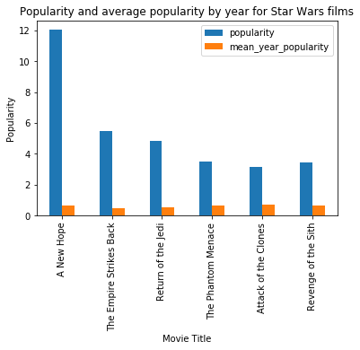

```python
starwars_plot = starwars_df.plot(starwars_df['title'],['popularity','mean_year_popularity']
                                 , kind='bar')
starwars_plot.set_xlabel('Movie Title')
starwars_plot.set_ylabel('Popularity')
starwars_plot.set_title('Popularity and average popularity by year for Star Wars films')
```

So, it's interesting to see that the average popularity for each year is about the same, and each Star Wars movie is still high above it, even if not quite as high the original film. This indicates to me that perhaps people started to watch the original Star Wars but didn't want to watch the entire series. Each film becomes progressively less popuar, with the exception of Revenge of the Sith. So perhaps people got excited about watching the first one, and many were satisfied with just watching that. All the movies after the first one decrease in popularity (generally), but not as sharply as popularity decreased from the first film to the second one. So, my conclusion is that if you decide to watch the second movie in the series then there is a high chance that you'll watch more if not all of them.

Star Wars is unique in that there have been many movies made in the series. There are very few other movie series like that to my knowledge. My tentative conclusion at this point is that when there is a new movie coming out that is part of a series, popularity for the other movies in that series increases as well, but not as much as it did for the Star Wars films. I say this because the Star Wars films span several decades, and so the original films fall into the category of "popular when our parents were young" (I'm 20, by the way). This means that there are now many people who haven't seen any Star Wars movies. So people, in preparation for the new Star Wars movie that was going to come out at the time this data was collected, wanted to have some backgroud knowledge of Star Wars before watching this new movie. Many watched the first one, didn't care enough to watch any others, and called it good. Most other movie series won't be like that because they don't span such a time frame as Star Wars. Many who will want to see a new movie coming out that is part of a series will have already seen the other movies in the series, and they wont be as inclined to go rewatch them. This, however, is only a hypothesis and not a conclusion. I cannot make a conclusion as I only have 2015 data to examine, and because of that I don't know how popular Star Wars movies are in years when a Star Wars movie is not coming out.

## Exploring further how movies being released as part of a series affect the popularity of other movies in the series

To start this endeavor, I will go through the movies released in 2015 and see if any are part of a series. I will be examening how far down each movie is within its year by looking at the row number of the most popular movie in that year (the most popular movie by year is always the first one) then looking at the row number of the movie I'm looking for. If necessary, I'll then subtract the most popular movie's row from the target movie's row to give me how far down the list it is. Also, I'll compare the mean popularity of a given year to how popular each movie is in graphical form.

```python
movies_df.loc[(movies_df['release_year'] == 2015)]
```

|  | popularity | original_title | cast | director | keywords | overview | runtime | genres | production_companies | release_date | vote_count | vote_average | release_year |
| --- | --- | --- | --- | --- | --- | --- | --- | --- | --- | --- | --- | --- | --- |
| 0 | 32.985763 | Jurassic World | Chris Pratt\|Bryce Dallas Howard\|Irrfan Khan\|Vi... | Colin Trevorrow | monster\|dna\|tyrannosaurus rex\|velociraptor\|island | Twenty-two years after the events of Jurassic ... | 124 | Action\|Adventure\|Science Fiction\|Thriller | Universal Studios\|Amblin Entertainment\|Legenda... | 6/9/15 | 5562 | 6.5 | 2015 |
| 1 | 28.419936 | Mad Max: Fury Road | Tom Hardy\|Charlize Theron\|Hugh Keays-Byrne\|Nic... | George Miller | future\|chase\|post-apocalyptic\|dystopia\|australia | An apocalyptic story set in the furthest reach... | 120 | Action\|Adventure\|Science Fiction\|Thriller | Village Roadshow Pictures\|Kennedy Miller Produ... | 5/13/15 | 6185 | 7.1 | 2015 |
| 2 | 13.112507 | Insurgent | Shailene Woodley\|Theo James\|Kate Winslet\|Ansel... | Robert Schwentke | based on novel\|revolution\|dystopia\|sequel\|dyst... | Beatrice Prior must confront her inner demons ... | 119 | Adventure\|Science Fiction\|Thriller | Summit Entertainment\|Mandeville Films\|Red Wago... | 3/18/15 | 2480 | 6.3 | 2015 |
| 3 | 11.173104 | Star Wars: The Force Awakens | Harrison Ford\|Mark Hamill\|Carrie Fisher\|Adam D... | J.J. Abrams | android\|spaceship\|jedi\|space opera\|3d | Thirty years after defeating the Galactic Empi... | 136 | Action\|Adventure\|Science Fiction\|Fantasy | Lucasfilm\|Truenorth Productions\|Bad Robot | 12/15/15 | 5292 | 7.5 | 2015 |
| 4 | 9.335014 | Furious 7 | Vin Diesel\|Paul Walker\|Jason Statham\|Michelle ... | James Wan | car race\|speed\|revenge\|suspense\|car | Deckard Shaw seeks revenge against Dominic Tor... | 137 | Action\|Crime\|Thriller | Universal Pictures\|Original Film\|Media Rights ... | 4/1/15 | 2947 | 7.3 | 2015 |
| 5 | 9.110700 | The Revenant | Leonardo DiCaprio\|Tom Hardy\|Will Poulter\|Domhn... | Alejandro González Iñárritu | father-son relationship\|rape\|based on novel\|mo... | In the 1820s, a frontiersman, Hugh Glass, sets... | 156 | Western\|Drama\|Adventure\|Thriller | Regency Enterprises\|Appian Way\|CatchPlay\|Anony... | 12/25/15 | 3929 | 7.2 | 2015 |
| 6 | 8.654359 | Terminator Genisys | Arnold Schwarzenegger\|Jason Clarke\|Emilia Clar... | Alan Taylor | saving the world\|artificial intelligence\|cybor... | The year is 2029. John Connor, leader of the r... | 125 | Science Fiction\|Action\|Thriller\|Adventure | Paramount Pictures\|Skydance Productions | 6/23/15 | 2598 | 5.8 | 2015 |
| 7 | 7.667400 | The Martian | Matt Damon\|Jessica Chastain\|Kristen Wiig\|Jeff ... | Ridley Scott | based on novel\|mars\|nasa\|isolation\|botanist | During a manned mission to Mars, Astronaut Mar... | 141 | Drama\|Adventure\|Science Fiction | Twentieth Century Fox Film Corporation\|Scott F... | 9/30/15 | 4572 | 7.6 | 2015 |
| 8 | 7.404165 | Minions | Sandra Bullock\|Jon Hamm\|Michael Keaton\|Allison... | Kyle Balda\|Pierre Coffin | assistant\|aftercreditsstinger\|duringcreditssti... | Minions Stuart, Kevin and Bob are recruited by... | 91 | Family\|Animation\|Adventure\|Comedy | Universal Pictures\|Illumination Entertainment | 6/17/15 | 2893 | 6.5 | 2015 |
| 9 | 6.326804 | Inside Out | Amy Poehler\|Phyllis Smith\|Richard Kind\|Bill Ha... | Pete Docter | dream\|cartoon\|imaginary friend\|animation\|kid | Growing up can be a bumpy road, and it's no ex... | 94 | Comedy\|Animation\|Family | Walt Disney Pictures\|Pixar Animation Studios\|W... | 6/9/15 | 3935 | 8.0 | 2015 |
| 10 | 6.200282 | Spectre | Daniel Craig\|Christoph Waltz\|Léa Seydoux\|Ralp... | Sam Mendes | spy\|based on novel\|secret agent\|sequel\|james bond | A cryptic message from Bond’s past sends him... | 148 | Action\|Adventure\|Crime | Columbia Pictures\|Danjaq\|B24 | 10/26/15 | 3254 | 6.2 | 2015 |
| 11 | 6.189369 | Jupiter Ascending | Mila Kunis\|Channing Tatum\|Sean Bean\|Eddie Redm... | Lana Wachowski\|Lilly Wachowski | jupiter\|space\|woman director\|3d\|interspecies r... | In a universe where human genetic material is ... | 124 | Science Fiction\|Fantasy\|Action\|Adventure | Village Roadshow Pictures\|Dune Entertainment\|A... | 2/4/15 | 1937 | 5.2 | 2015 |
| 12 | 6.118847 | Ex Machina | Domhnall Gleeson\|Alicia Vikander\|Oscar Isaac\|S... | Alex Garland | dancing\|artificial intelligence\|helicopter\|dis... | Caleb, a 26 year old coder at the world's larg... | 108 | Drama\|Science Fiction | DNA Films\|Universal Pictures International (UP... | 1/21/15 | 2854 | 7.6 | 2015 |
| 13 | 5.984995 | Pixels | Adam Sandler\|Michelle Monaghan\|Peter Dinklage\|... | Chris Columbus | video game\|nerd\|alien attack\|3d\|pixels | Video game experts are recruited by the milita... | 105 | Action\|Comedy\|Science Fiction | Columbia Pictures\|Happy Madison Productions | 7/16/15 | 1575 | 5.8 | 2015 |
| 14 | 5.944927 | Avengers: Age of Ultron | Robert Downey Jr.\|Chris Hemsworth\|Mark Ruffalo... | Joss Whedon | marvel comic\|comic\|sequel\|superhero\|vision | When Tony Stark tries to jumpstart a dormant p... | 141 | Action\|Adventure\|Science Fiction | Marvel Studios\|Prime Focus\|Revolution Sun Studios | 4/22/15 | 4304 | 7.4 | 2015 |
| 15 | 5.898400 | The Hateful Eight | Samuel L. Jackson\|Kurt Russell\|Jennifer Jason ... | Quentin Tarantino | bounty hunter\|wyoming\|mountains\|hangman\|voice ... | Bounty hunters seek shelter from a raging bliz... | 167 | Crime\|Drama\|Mystery\|Western | Double Feature Films\|The Weinstein Company\|Fil... | 12/25/15 | 2389 | 7.4 | 2015 |
| 16 | 5.749758 | Taken 3 | Liam Neeson\|Forest Whitaker\|Maggie Grace\|Famke... | Olivier Megaton | revenge\|murder\|on the run\|fugitive\|framed | Ex-government operative Bryan Mills finds his ... | 109 | Crime\|Action\|Thriller | Twentieth Century Fox Film Corporation\|M6 Film... | 1/1/15 | 1578 | 6.1 | 2015 |
| 17 | 5.573184 | Ant-Man | Paul Rudd\|Michael Douglas\|Evangeline Lilly\|Cor... | Peyton Reed | marvel comic\|superhero\|aftercreditsstinger\|dur... | Armed with the astonishing ability to shrink i... | 115 | Science Fiction\|Action\|Adventure | Marvel Studios | 7/14/15 | 3779 | 7.0 | 2015 |
| 18 | 5.556818 | Cinderella | Lily James\|Cate Blanchett\|Richard Madden\|Helen... | Kenneth Branagh | cinderella\|magic\|fairy tale\|princess\|shoe | When her father unexpectedly passes away, youn... | 112 | Romance\|Fantasy\|Family\|Drama | Walt Disney Pictures\|Genre Films\|Beagle Pug Fi... | 3/12/15 | 1495 | 6.8 | 2015 |
| 19 | 5.476958 | The Hunger Games: Mockingjay - Part 2 | Jennifer Lawrence\|Josh Hutcherson\|Liam Hemswor... | Francis Lawrence | revolution\|strong woman\|dystopia\|game of death\|3d | With the nation of Panem in a full scale war, ... | 136 | War\|Adventure\|Science Fiction | Studio Babelsberg\|StudioCanal\|Lionsgate\|Walt D... | 11/18/15 | 2380 | 6.5 | 2015 |
| 20 | 5.462138 | Tomorrowland | Britt Robertson\|George Clooney\|Raffey Cassidy\|... | Brad Bird | inventor\|apocalypse\|destiny\|imax\|dreamer | Bound by a shared destiny, a bright, optimisti... | 130 | Action\|Family\|Science Fiction\|Adventure\|Mystery | Walt Disney Pictures\|Babieka\|A113 | 5/19/15 | 1899 | 6.2 | 2015 |
| 21 | 5.337064 | Southpaw | Jake Gyllenhaal\|Rachel McAdams\|Forest Whitaker... | Antoine Fuqua | sport | Billy "The Great" Hope, the reigning junior mi... | 123 | Action\|Drama | Escape Artists\|Riche-Ludwig Productions | 6/15/15 | 1386 | 7.3 | 2015 |
| 22 | 4.907832 | San Andreas | Dwayne Johnson\|Alexandra Daddario\|Carla Gugino... | Brad Peyton | california\|earthquake\|catastrophe\|disaster fil... | In the aftermath of a massive earthquake in Ca... | 114 | Action\|Drama\|Thriller | New Line Cinema\|Village Roadshow Pictures\|Warn... | 5/27/15 | 2060 | 6.1 | 2015 |
| 23 | 4.710402 | Fifty Shades of Grey | Dakota Johnson\|Jamie Dornan\|Jennifer Ehle\|Eloi... | Sam Taylor-Johnson | based on novel\|billionaire\|bdsm\|woman director... | When college senior Anastasia Steele steps in ... | 125 | Drama\|Romance | Focus Features\|Trigger Street Productions\|Mich... | 2/11/15 | 1865 | 5.3 | 2015 |
| 24 | 4.648046 | The Big Short | Christian Bale\|Steve Carell\|Ryan Gosling\|Brad ... | Adam McKay | bank\|fraud\|biography\|wall street\|finances | The men who made millions from a global econom... | 130 | Comedy\|Drama | Paramount Pictures\|Plan B Entertainment\|Regenc... | 12/11/15 | 1545 | 7.3 | 2015 |
| 25 | 4.566713 | Mission: Impossible - Rogue Nation | Tom Cruise\|Jeremy Renner\|Simon Pegg\|Rebecca Fe... | Christopher McQuarrie | spy\|sequel\|mission | Ethan and team take on their most impossible m... | 131 | Action | Paramount Pictures\|Skydance Productions\|China ... | 7/23/15 | 2349 | 7.1 | 2015 |
| 26 | 4.564549 | Ted 2 | Mark Wahlberg\|Seth MacFarlane\|Amanda Seyfried\|... | Seth MacFarlane | sperm bank\|sequel\|buddy\|courthouse\|teddy bear | Newlywed couple Ted and Tami-Lynn want to have... | 115 | Comedy | Universal Pictures\|Media Rights Capital\|Fuzzy ... | 6/25/15 | 1666 | 6.3 | 2015 |
| 27 | 4.503789 | Kingsman: The Secret Service | Taron Egerton\|Colin Firth\|Samuel L. Jackson\|Mi... | Matthew Vaughn | spy\|great britain\|secret organization\|secret a... | The story of a super-secret spy organization t... | 130 | Crime\|Comedy\|Action\|Adventure | Twentieth Century Fox Film Corporation\|Marv Fi... | 1/24/15 | 3833 | 7.6 | 2015 |
| 28 | 4.062293 | Spotlight | Mark Ruffalo\|Michael Keaton\|Rachel McAdams\|Lie... | Tom McCarthy | child abuse\|journalism\|judge\|florida\|boston | The true story of how The Boston Globe uncover... | 128 | Drama\|Thriller\|History | Participant Media\|Open Road Films\|Anonymous Co... | 11/6/15 | 1559 | 7.8 | 2015 |
| 29 | 3.968891 | Maze Runner: The Scorch Trials | Dylan O'Brien\|Kaya Scodelario\|Thomas Brodie-Sa... | Wes Ball | based on novel\|resistance\|maze\|post-apocalypti... | Thomas and his fellow Gladers face their great... | 132 | Action\|Science Fiction\|Thriller | Gotham Group\|Temple Hill Entertainment\|TSG Ent... | 9/9/15 | 1849 | 6.4 | 2015 |
| ... | ... | ... | ... | ... | ... | ... | ... | ... | ... | ... | ... | ... | ... |
| 599 | 0.048863 | The Stranger | Lorenza Izzo\|Ariel Levy\|Aaron Burns\|Cristobal ... | Guillermo Amoedo | NaN | A supernatural thriller, laced by flashbacks, ... | 93 | Drama\|Thriller\|Horror\|Mystery | Sobras International Pictures | 6/12/15 | 20 | 4.9 | 2015 |
| 600 | 0.047256 | Star Wars: TIE Fighter | NaN | Paul Johnson | space battle\|animation\|space opera\|military | Paul “OtaKing” Johnson drops a real treat i... | 7 | Science Fiction\|Action\|Animation | NaN | 3/24/15 | 29 | 7.6 | 2015 |
| 601 | 0.046453 | Dough | Jonathan Pryce\|Philip Davis\|Ian Hart\|Pauline C... | John Goldschmidt | NaN | An old Jewish baker struggles to keep his busi... | 97 | Drama\|Comedy | NaN | 4/14/15 | 15 | 4.9 | 2015 |
| 602 | 0.038840 | The Bad Education Movie | Jack Whitehall\|Mathew Horne\|Sarah Solemani\|Nik... | Elliot Hegarty | NaN | Mr Wickers and his class go on one final schoo... | 90 | Comedy | Tiger Aspect Productions | 8/21/15 | 23 | 5.2 | 2015 |
| 603 | 0.038804 | Student Bodies | Whitney Moore\|Tom Arnold\|Simon Rex\|Lucius Bast... | Andrew Drazek | NaN | After experiencing a series of sexually relate... | 92 | Comedy | Tiberius Film | 9/3/15 | 14 | 6.0 | 2015 |
| 604 | 0.037487 | The Subjects | Paul O'Brien\|Charlotte Nicdao\|Emily Wheaton\|Sp... | Robert Mond | experiment\|locked in a room\|drug trial | Eight strangers go into a locked room for clin... | 80 | Thriller\|Science Fiction | Instinct Entertainment | 10/8/15 | 12 | 4.7 | 2015 |
| 605 | 0.037147 | Walking with the Dead | Tim Ogletree\|Joey Oglesby\|Dave Sheridan\|Troy O... | Scott Dow | spoof\|zombies | THE WALKING DECEASED is the Scary Movie of the... | 90 | Science Fiction\|Comedy | Splendid Film | 3/20/15 | 18 | 3.9 | 2015 |
| 606 | 0.036987 | Floride | Jean Rochefort\|Sandrine Kiberlain\|Laurent Luca... | Philippe Le Guay | NaN | Although he's now eighty years old, Claude Lhe... | 110 | Comedy | Gaumont\|France 2 Cinéma\|Rhône-Alpes Cinéma\|... | 8/12/15 | 16 | 6.3 | 2015 |
| 607 | 0.079539 | The Outskirts | Victoria Justice\|Eden Sher\|Ashley Rickards\|Ava... | Peter Hutchings | school\|teen | After falling victim to a humiliating prank by... | 95 | Comedy | BCDF Pictures | 7/15/15 | 12 | 4.0 | 2015 |
| 608 | 0.034534 | Twinsters | Anais Bordier\|Samantha Futerman\|Kanoa Goo | Samantha Futerman\|Ryan Miyamoto | twin sister\|woman director\|sisterhood | Adopted from South Korea, raised on different ... | 90 | Family\|Documentary | Small Package Films | 7/17/15 | 54 | 7.4 | 2015 |
| 609 | 0.033378 | The Jinx: The Life and Deaths of Robert Durst | Robert Durst\|Andrew Jarecki\|Marc Smerling\|Zach... | Andrew Jarecki | murder\|crime\|real life | Robert Durst, scion of one of New York’s bil... | 240 | Documentary | Blumhouse Productions\|Hit the Ground Running F... | 2/8/15 | 72 | 8.4 | 2015 |
| 610 | 0.056244 | The Curse of Downers Grove | Bella Heathcote\|Lucas Till\|Helen Slater\|Penelo... | Derick Martini | self-defense\|car mechanic\|graduation\|high scho... | The town of Downers Grove looks like your aver... | 89 | Thriller\|Mystery\|Horror\|Drama | Myriad Pictures\|AliBella Pictures\|Bystander Fi... | 8/21/15 | 11 | 4.2 | 2015 |
| 611 | 0.032678 | World of Tomorrow | Julia Pott\|Winona Mae | Don Hertzfeldt | NaN | A little girl is contacted by a mysterious woman. | 17 | Animation\|Comedy\|Science Fiction | Bitter Films | 3/31/15 | 47 | 8.2 | 2015 |
| 612 | 0.030819 | Dawg Fight | Dhafir Harris | Billy Corben | NaN | In a crime-plagued neighborhood near Miami, br... | 109 | Documentary | Rakontur | 3/13/15 | 17 | 6.4 | 2015 |
| 613 | 0.030113 | King Jack | Charlie Plummer\|Cory Nichols\|Christian Madsen\|... | Felix Thompson | small town\|independent film\|coming of age\|rura... | Growing up in a rural town filled with violent... | 81 | Drama | Whitewater Films\|Stink Films\|Buffalo Picture H... | 4/1/15 | 13 | 6.8 | 2015 |
| 614 | 0.030005 | The Suicide Theory | Leon Cain\|Steve Mazoukis | Dru Brown | suicide\|underground\|cult\|buddy | Steven Ray was never quite normal. But when tr... | 98 | Drama\|Thriller | Seven8 Media | 7/10/15 | 17 | 6.5 | 2015 |
| 615 | 0.028082 | Stalked By My Neighbor | Amy Pietz\|Kelcie Stranahan\|Katrina Norman\|Gran... | Doug Campbell | NaN | A girl and her mother escape to suburban safet... | 88 | Thriller | Johnson Production Group\|Shadowland | 3/21/15 | 14 | 5.5 | 2015 |
| 616 | 0.026797 | The Outfield | Cameron Dallas\|Hamilton Nash Grier\|Olivia Stuc... | Michael Goldfine | NaN | The film follows a trio of varsity baseball pl... | 0 | Drama\|Comedy | NaN | 11/10/15 | 20 | 6.6 | 2015 |
| 617 | 0.025288 | Buzzard | Joshua Burge\|Joel Potrykus\|Teri Ann Nelson\|Joe... | Joel Potrykus | hotel\|bank\|spaghetti\|punk\|nintendo | Paranoia forces small-time scam artist Marty t... | 97 | Horror\|Comedy\|Drama | Sob Noisse Movies | 3/6/15 | 11 | 6.1 | 2015 |
| 618 | 0.025252 | The Gamechangers | Daniel Radcliffe\|Bill Paxton\|Joe Dempsie | Owen Harris | video game\|journalist\|ghetto\|biography\|christian | This 90-minute factual drama goes behind the s... | 90 | Drama\|TV Movie | BBC Films\|British Broadcasting Corporation (BB... | 9/15/15 | 11 | 7.0 | 2015 |
| 619 | 0.023026 | Residue | Natalia Tena\|Iwan Rheon\|Jamie Draven\|Danny Web... | Alex Garcia Lopez | NaN | The government cover-up of the causes behind a... | 102 | Science Fiction\|Mystery\|Horror\|Thriller | Screen Yorkshire\|Gloucester Place Films\|Green ... | 3/20/15 | 15 | 4.5 | 2015 |
| 620 | 0.129696 | All Hallows' Eve 2 | NaN | Antonio Padovan\|Bryan Norton\|Marc Roussel\|Ryan... | NaN | A woman finds a VHS tape on her doorstep that ... | 90 | NaN | Ruthless Pictures\|Hollywood Shorts | 10/6/15 | 13 | 5.0 | 2015 |
| 621 | 0.019804 | Always Watching: A Marble Hornets Story | Alexandra Breckenridge\|Doug Jones\|Jake McDorma... | James Moran | NaN | A group of student film makers are creating "P... | 91 | Horror | Good Universe\|Mosaic Films\|Institution Post | 4/7/15 | 19 | 4.2 | 2015 |
| 622 | 0.019133 | A Ballerina's Tale | Misty Copeland\|Victoria Rowell\|Bevy Smith\|Deir... | Nelson George | NaN | A feature documentary on African American ball... | 85 | Documentary | NaN | 10/14/15 | 16 | 6.0 | 2015 |
| 623 | 0.018224 | Man vs. Snake | Tim McVey\|Dwayne Richard\|Tom Asaki\|Billy Mitch... | Tim Kinzy\|Andrew Seklir | video game\|games\|arcade\|nibbler | 1984. One shiny quarter. 44.5 hours of continu... | 93 | Documentary | NaN | 9/27/15 | 10 | 6.8 | 2015 |
| 624 | 0.017625 | Once I Was a Beehive | Paris Warner\|Lisa Clark\|Hailey Smith\|Clare Nie... | Maclain Nelson | NaN | Comedy - Lane Speer is a 16 year old girl who ... | 119 | Comedy\|Drama\|Family | Escapology\|Main Dog Productions | 8/14/15 | 10 | 6.5 | 2015 |
| 625 | 0.017050 | John Mulaney: The Comeback Kid | John Mulaney | Rhys Thomas | stand up comedy | Armed with boyish charm and a sharp wit, the f... | 62 | Comedy | 3 Arts Entertainment\|Irwin Entertainment | 11/13/15 | 19 | 6.7 | 2015 |
| 626 | 0.014647 | Meet the Patels | Ravi Patel | Geeta Patel\|Ravi Patel | woman director | Finding love is never easy. For Ravi Patel, a ... | 88 | Documentary | NaN | 9/11/15 | 20 | 6.7 | 2015 |
| 627 | 0.030371 | I Hate Christian Laettner | Rob Lowe\|Ken Jeong\|Verne Troyer\|Mike Krzyzewski | Rory Karpf | individual\|sport\|baskeball | He made perhaps the most dramatic shot in the ... | 90 | Documentary | NaN | 3/15/15 | 10 | 6.7 | 2015 |
| 628 | 0.003920 | The Emperor's New Clothes | Russell Brand | Michael Winterbottom | NaN | Michael Winterbottom, celebrated director of 2... | 107 | Documentary | NaN | 4/24/15 | 11 | 6.1 | 2015 |

629 rows × 13 columns

Okay! So even just looking through the first few movies released in 2015 I see that many are part of a series -far more than I expected. Because of this sheer volume, I'll only examine the first 5 movies that are part of large movie series, containing 3 or more movies (and I've already examined Star Wars). I will exclude Insurgent because it is only part of a two-movie series (at the time this data was collected). Also, its prequel *Divergent* was released in 2014 and was a very popular movie just on its own. I'm looking for older movies that may have regained popularity recently because of a new release in its series. Thus, I don't think this series would represent very well the common behavior of movie series in general.

## Jurassic World (Jurassic Park series)

The chronological titles of all films in this series (when this data was collected) are: Jurassic Park, The Lost World: Jurassic Park, Jurassic Park III, and Jurassic World. Let's see how these movies compare in their respective years.

### Jurassic Park (1993)

```python
movies_df[(movies_df['release_year'] == 1993)]
```

|  | popularity | original_title | cast | director | keywords | overview | runtime | genres | production_companies | release_date | vote_count | vote_average | release_year |
| --- | --- | --- | --- | --- | --- | --- | --- | --- | --- | --- | --- | --- | --- |
| 10220 | 2.571339 | Groundhog Day | Bill Murray\|Andie MacDowell\|Chris Elliott\|Step... | Harold Ramis | deja vu\|groundhog\|weather forecast\|telecaster\|... | A narcissistic TV weatherman, along with his a... | 101 | Romance\|Fantasy\|Drama\|Comedy | Columbia Pictures | 2/11/93 | 1339 | 7.2 | 1993 |
| 10221 | 2.455618 | The Nightmare Before Christmas | Danny Elfman\|Chris Sarandon\|Catherine O'Hara\|W... | Henry Selick | holiday\|fire\|santa claus\|magic\|halloween | Tired of scaring humans every October 31 with ... | 76 | Fantasy\|Animation\|Family | Walt Disney Pictures\|Tim Burton Animation Comp... | 10/9/93 | 1172 | 7.4 | 1993 |
| 10222 | 2.377288 | Schindler's List | Liam Neeson\|Ben Kingsley\|Ralph Fiennes\|Carolin... | Steven Spielberg | factory\|concentration camp\|hero\|holocaust\|worl... | The true story of how businessman Oskar Schind... | 195 | Drama\|History\|War | Universal Pictures\|Amblin Entertainment | 11/29/93 | 2632 | 8.1 | 1993 |
| 10223 | 2.204926 | Jurassic Park | Sam Neill\|Laura Dern\|Jeff Goldblum\|Richard Att... | Steven Spielberg | exotic island\|dna\|paleontology\|tyrannosaurus r... | A wealthy entrepreneur secretly creates a them... | 127 | Adventure\|Science Fiction | Universal Pictures\|Amblin Entertainment | 6/11/93 | 3169 | 7.4 | 1993 |
| 10224 | 1.960217 | Demolition Man | Sylvester Stallone\|Wesley Snipes\|Sandra Bulloc... | Marco Brambilla | helicopter\|martial arts\|crime fighter\|social c... | Simon Phoenix, a violent criminal cryogenicall... | 115 | Action\|Adventure\|Comedy\|Science Fiction | Silver Pictures\|Warner Bros. | 10/8/93 | 580 | 6.1 | 1993 |
| 10225 | 1.732126 | Mrs. Doubtfire | Robin Williams\|Sally Field\|Pierce Brosnan\|Harv... | Chris Columbus | san francisco\|parents kids relationship\|restau... | Loving but irresponsible dad Daniel Hillard, e... | 125 | Comedy\|Drama\|Family | Twentieth Century Fox Film Corporation\|Blue Wolf | 11/24/93 | 809 | 6.9 | 1993 |
| 10226 | 1.708867 | The Fugitive | Harrison Ford\|Tommy Lee Jones\|Sela Ward\|Julian... | Andrew Davis | chicago\|showdown\|undercover\|surgeon\|death sent... | Dr. Richard Kimble, unjustly accused of murder... | 130 | Adventure\|Action\|Thriller\|Crime\|Mystery | Warner Bros. | 8/6/93 | 717 | 7.0 | 1993 |
| 10227 | 1.355970 | In the Line of Fire | Clint Eastwood\|Rene Russo\|John Malkovich\|Dylan... | Wolfgang Petersen | cia\|assassin\|running\|white house\|u.s. president | Veteran Secret Service agent Frank Horrigan is... | 128 | Action\|Drama\|Thriller\|Crime\|Mystery | Castle Rock Entertainment\|Columbia Pictures Co... | 7/8/93 | 170 | 6.5 | 1993 |
| 10228 | 1.294131 | Philadelphia | Tom Hanks\|Denzel Washington\|Jason Robards\|Mary... | Jonathan Demme | gay\|aids\|homophobia\|jurors\|court | No one would take his case until one man was w... | 125 | Drama\|Mystery | TriStar Pictures | 12/22/93 | 514 | 7.5 | 1993 |
| 10229 | 1.242232 | Dazed and Confused | Jason London\|Rory Cochrane\|Wiley Wiggins\|Sasha... | Richard Linklater | 1970s\|texas\|summer\|teenager | The adventures of a group of Texas teens on th... | 102 | Comedy\|Drama | Gramercy Pictures\|Alphaville Productions | 9/24/93 | 320 | 7.3 | 1993 |
| 10230 | 1.207245 | Last Action Hero | Arnold Schwarzenegger\|F. Murray Abraham\|Art Ca... | John McTiernan | magic\|movie in movie\|spoof\|cartoon cat\|ticket | Danny is obsessed with a fictional movie chara... | 130 | Adventure\|Fantasy\|Action\|Comedy\|Family | Columbia Pictures Corporation\|Oak Productions | 6/17/93 | 367 | 5.8 | 1993 |
| 10231 | 1.190247 | A Perfect World | Kevin Costner\|Clint Eastwood\|Laura Dern\|T.J. L... | Clint Eastwood | hostage\|escape from prison\|escaped convict\|chi... | A kidnapped boy strikes up a friendship with h... | 138 | Crime\|Drama\|Thriller | Malpaso Productions\|Warner Bros. | 11/24/93 | 188 | 6.9 | 1993 |
| 10232 | 1.176724 | Robin Hood: Men in Tights | Cary Elwes\|Dom DeLuise\|Roger Rees\|Dave Chappel... | Mel Brooks | witch\|tree house\|robin hood\|taxes\|thief | Robin Hood comes home after fighting in the Cr... | 104 | Comedy | Gaumont\|Brooksfilms | 7/28/93 | 273 | 6.3 | 1993 |
| 10233 | 1.132123 | Addams Family Values | Raúl Juliá\|Anjelica Huston\|Christopher Lloyd... | Barry Sonnenfeld | jealousy\|baby\|butler\|yuppie\|nanny | Siblings Wednesday and Pugsley Addams will sto... | 94 | Comedy\|Family\|Fantasy | Paramount Pictures\|Orion Pictures\|Scott Rudin ... | 11/19/93 | 254 | 6.3 | 1993 |
| 10234 | 1.041911 | Cliffhanger | Sylvester Stallone\|John Lithgow\|Michael Rooker... | Renny Harlin | airplane\|hijacking\|climbing\|heist\|mountain cli... | A year after losing his friend in a tragic 4,0... | 112 | Action\|Adventure\|Thriller | TriStar Pictures\|Canal+\|Carolco Pictures\|RCS V... | 5/28/93 | 312 | 6.1 | 1993 |
| 10235 | 1.038971 | Sliver | Sharon Stone\|William Baldwin\|Tom Berenger\|Poll... | Phillip Noyce | new york\|male nudity\|female nudity\|sex\|based o... | A women moves into an apartment in Manhattan a... | 108 | Drama\|Thriller | Paramount Pictures | 5/21/93 | 62 | 4.7 | 1993 |
| 10236 | 1.024955 | Teenage Mutant Ninja Turtles III | Paige Turco\|Stuart Wilson\|Sab Shimono\|Vivian W... | Stuart Gillard | japan\|time travel\|ninjas | The four turtles travel back in time to the da... | 96 | Action\|Adventure\|Comedy\|Family\|Fantasy | New Line Cinema\|Golden Harvest Pictures\|Clearw... | 3/17/93 | 95 | 5.2 | 1993 |
| 10237 | 1.023326 | Stalingrad | Dominique Horwitz\|Thomas Kretschmann\|Jochen Ni... | Joseph Vilsmaier | general\|world war ii\|soviet troops\|adolf hitle... | "Stalingrad" follows the progress of a German ... | 134 | Drama\|History\|War | Royal Film\|Bavaria Film\|B.A. Produktion\|Perath... | 1/21/93 | 51 | 6.6 | 1993 |
| 10238 | 0.996113 | The Wrong Trousers | Peter Sallis | Nick Park | robbery\|inventor\|penguin\|telecontrol\|surrealism | Gromit finds himself being pushed out of his r... | 30 | Animation\|Comedy\|Family | Aardman Animations | 12/17/93 | 146 | 7.4 | 1993 |
| 10239 | 0.980554 | Cool Runnings | Leon Robinson\|Doug E. Doug\|Rawle D. Lewis\|Mali... | Jon Turteltaub | winter\|trainer\|olympic games\|jamaica\|training ... | Cool Runnings is an American film from directo... | 98 | Comedy | Walt Disney | 9/30/93 | 289 | 6.8 | 1993 |
| 10240 | 0.940335 | Sleepless in Seattle | Tom Hanks\|Meg Ryan\|Bill Pullman\|Ross Malinger\|... | Nora Ephron | father-son relationship\|lovesickness\|journalis... | A young boy who tries to set his dad up on a d... | 105 | Comedy\|Drama\|Romance | TriStar Pictures | 6/24/93 | 362 | 6.4 | 1993 |
| 10241 | 0.926373 | Tombstone | Kurt Russell\|Val Kilmer\|Sam Elliott\|Bill Paxto... | George P. Cosmatos | retirement\|wyatt earp\|right and justice\|histor... | Legendary marshal Wyatt Earp, now a weary gunf... | 130 | Action\|Adventure\|Drama\|History\|Western | Hollywood Pictures\|Cinergi Pictures Entertainment | 12/25/93 | 373 | 7.3 | 1993 |
| 10242 | 0.913982 | Benny & Joon | Johnny Depp\|Mary Stuart Masterson\|Aidan Quinn\|... | Jeremiah S. Chechik | brother sister relationship\|autism\|car garage | A mentally ill young woman finds her love in a... | 98 | Action\|Comedy\|Drama\|Romance | Roth-Arnold Productions\|Metro-Goldwyn-Mayer (MGM) | 4/16/93 | 124 | 6.8 | 1993 |
| 10243 | 0.892862 | For Love or Money | Michael J. Fox\|Gabrielle Anwar\|Anthony Higgins... | Barry Sonnenfeld | hotel\|lover (female)\|concierge\|deception\|mistress | New York concierge Doug Ireland wants to go in... | 94 | Comedy\|Romance | Universal Studios\|Imagine Entertainment | 10/1/93 | 35 | 5.4 | 1993 |
| 10244 | 0.885824 | Carlito's Way | Al Pacino\|Sean Penn\|Penelope Ann Miller\|John L... | Brian De Palma | prison\|1970s\|puerto rican\|release from prison\|... | A Puerto-Rican ex-con, just released from pris... | 144 | Action\|Crime\|Drama\|Thriller | Universal Pictures\|Epic Productions\|Bregman/Ba... | 11/10/93 | 394 | 7.4 | 1993 |
| 10245 | 0.873616 | Hot Shots! Part Deux | Charlie Sheen\|Lloyd Bridges\|Valeria Golino\|Ric... | Jim Abrahams | swordplay\|secret agent\|liberation of hostage\|s... | Topper Harley is found to be working as an odd... | 86 | Action\|Comedy\|War | Twentieth Century Fox Film Corporation\|Sidley ... | 5/21/93 | 255 | 6.1 | 1993 |
| 10246 | 0.853733 | True Romance | Christian Slater\|Patricia Arquette\|Michael Rap... | Tony Scott | father-son relationship\|film producer\|mexican ... | Clarence marries hooker Alabama, steals cocain... | 120 | Action\|Thriller\|Crime\|Romance | Davis-Films\|August Entertainment\|Warner Bros.\|... | 9/9/93 | 402 | 7.3 | 1993 |
| 10247 | 0.834235 | Super Mario Bros. | Bob Hoskins\|John Leguizamo\|Dennis Hopper\|Saman... | Annabel Jankel\|Rocky Morton | saving the world\|brother brother relationship\|... | Mario and Luigi, plumbers from Brooklyn, find ... | 104 | Adventure\|Comedy\|Family\|Fantasy | Hollywood Pictures\|Cinergi Pictures Entertainm... | 5/27/93 | 114 | 4.0 | 1993 |
| 10248 | 0.830934 | Sister Act 2: Back in the Habit | Whoopi Goldberg\|Kathy Najimy\|James Coburn\|Barn... | Bill Duke | musical\|monastery | Deloris Van Cartier is again asked to don the ... | 107 | Music\|Comedy | Touchstone Pictures | 12/9/93 | 173 | 5.8 | 1993 |
| 10249 | 0.815631 | Judgment Night | Emilio Estevez\|Cuba Gooding Jr.\|Denis Leary\|Je... | Stephen Hopkins | chicago\|drug dealer\|boxing match\|escape\|one night | While racing to a boxing match, Frank, Mike, J... | 110 | Action\|Thriller\|Crime | Largo Entertainment\|JVC Entertainment Networks | 10/15/93 | 36 | 6.4 | 1993 |
| ... | ... | ... | ... | ... | ... | ... | ... | ... | ... | ... | ... | ... | ... |
| 10368 | 0.191721 | Man's Best Friend | Ally Sheedy\|Lance Henriksen\|Robert Costanzo\|Fr... | John Lafia | killer\|dog\|mutated | A dog turns from man's best friend into man's ... | 97 | Horror\|Science Fiction\|Thriller | New Line Cinema\|Roven-Cavallo Entertainment | 11/19/93 | 10 | 5.5 | 1993 |
| 10369 | 0.190206 | Boxing Helena | Julian Sands\|Sherilyn Fenn\|Bill Paxton\|Kurtwoo... | Jennifer Chambers Lynch | dream\|nudity\|suspense\|unrequited love\|kidnapping | A top surgeon is besotted with a beautiful wom... | 107 | Drama\|Romance | Mainline Pictures | 6/18/93 | 27 | 4.6 | 1993 |
| 10370 | 0.181982 | Fong Sai Yuk | Jet Li\|Josephine Siao\|Vincent Zhao\|Michelle Re... | Corey Yuen Kwai | kung fu | This Hong Kong martial-arts extravaganza tells... | 106 | Adventure\|Action\|Comedy | Eastern Productions | 3/4/93 | 20 | 7.1 | 1993 |
| 10371 | 0.181726 | The Thing Called Love | River Phoenix\|Samantha Mathis\|Dermot Mulroney\|... | Peter Bogdanovich | country music | Miranda Presley moves from New York to Nashvil... | 116 | Music\|Drama\|Romance | Paramount Pictures | 7/16/93 | 14 | 5.8 | 1993 |
| 10372 | 0.181665 | Cannibal! The Musical | Trey Parker\|Dian Bachar\|Ian Hardin\|Jon Hegel\|M... | Trey Parker | musical | Heading through Colorado Territory in search o... | 97 | Comedy\|History\|Horror | Avenging Conscience\|Troma Entertainment\|Cannib... | 10/1/93 | 19 | 6.7 | 1993 |
| 10373 | 0.174646 | Once Upon a Forest | Michael Crawford\|Ben Vereen\|Ellen Blain\|Benji ... | Charles Grosvenor | friendship\|animal | A young mouse, mole and hedgehog risk their li... | 71 | Animation\|Family\|Adventure | Hanna-Barbera Productions | 6/18/93 | 12 | 6.1 | 1993 |
| 10374 | 0.168519 | Ticks | Ami Dolenz\|Seth Green\|Clint Howard\|Peter Scola... | Tony Randel | animal horror | Teens camping in a northern California retreat... | 85 | Horror\|Science Fiction | NaN | 10/12/93 | 13 | 5.2 | 1993 |
| 10375 | 0.246549 | Necronomicon | Jeffrey Combs\|Bruce Payne\|Belinda Bauer\|Richar... | Christophe Gans\|Shusuke Kaneko\|Brian Yuzna | NaN | H.P. Lovecraft anthology is divided into four ... | 96 | Horror | Davis-Films | 11/1/93 | 12 | 4.8 | 1993 |
| 10376 | 0.152064 | Just One of the Girls | Corey Haim\|Nicole Eggert\|Cameron Bancroft\|Joha... | Michael Keusch | cheerleader\|role reversal\|high school | Chris has to change school to attend a music p... | 91 | Comedy | Entertainment Securities | 9/13/93 | 10 | 6.4 | 1993 |
| 10377 | 0.151355 | The Meteor Man | Robert Townsend\|Marla Gibbs\|Eddie Griffin\|Robe... | Robert Townsend | street gang\|hero\|music teacher\|supernatural po... | One night Jefferson Reed gets hit in the chest... | 100 | Fantasy\|Action\|Comedy\|Science Fiction\|Family | Metro-Goldwyn-Mayer (MGM)\|Tinsel Townsend | 8/6/93 | 12 | 4.8 | 1993 |
| 10378 | 0.140785 | Dragon: The Bruce Lee Story | Jason Scott Lee\|Lauren Holly\|Robert Wagner\|Mic... | Rob Cohen | life and death\|martial arts\|training\|bruce lee | This film is a glimpse into the life, love and... | 120 | Drama\|Action | Universal Pictures | 5/7/93 | 72 | 6.9 | 1993 |
| 10379 | 0.132556 | The Snapper | Colm Meaney\|Tina Kellegher\|Ruth McCabe\|Eanna M... | Stephen Frears | pub\|apparition\|independent film\|mother daughte... | Set in Ireland, Sharon Curley is a 20 year old... | 91 | Comedy\|Drama | Miramax Films\|BBC Films | 8/6/93 | 10 | 5.6 | 1993 |
| 10380 | 0.130780 | Mr. Nanny | Hulk Hogan\|David Johansen\|Madeline Zima\|Robert... | Michael Gottlieb | nanny\|wrestler | A former pro-wrestler is hired to be the bodyg... | 84 | Family\|Comedy\|Action | New Line Cinema | 10/8/93 | 25 | 5.2 | 1993 |
| 10381 | 0.128982 | Return of the Living Dead 3 | Melinda Clarke\|J. Trevor Edmond\|Kent McCord\|Sa... | Brian Yuzna | gang\|zombies | Colonel Reynolds and his group of government s... | 97 | Horror\|Romance\|Science Fiction | Ozla Productions | 10/1/93 | 34 | 5.6 | 1993 |
| 10382 | 0.271575 | Boiling Point | Wesley Snipes\|Dennis Hopper\|Lolita Davidovich\|... | James B. Harris | NaN | Red is an aging scam-artist who's just been re... | 92 | Drama\|Action\|Adventure\|Crime\|Thriller | StudioCanal\|Warner Bros. | 4/16/93 | 13 | 4.7 | 1993 |
| 10383 | 0.126597 | Doppelganger | Drew Barrymore\|George Newbern\|Leslie Hope\|Denn... | Avi Nesher | shower\|nudity\|nightmare\|seduction\|stalker | A woman moves from NYC to LA after a murder, i... | 104 | Horror\|Mystery\|Thriller | Planet Productions | 3/1/93 | 10 | 5.5 | 1993 |
| 10384 | 0.093730 | The Adventures of Huck Finn | Elijah Wood\|Courtney B. Vance\|Robbie Coltrane\|... | Stephen Sommers | southern accent\|wanted man\|lynch mob\|reflectio... | Climb aboard for an extraordinary version of M... | 108 | Action\|Adventure\|Drama\|Family | Walt Disney Pictures | 4/2/93 | 15 | 6.6 | 1993 |
| 10385 | 0.265865 | å¤ªæžå¼ ä¸‰ä¸° | Jet Li\|Michelle Yeoh\|Chin Siu-Ho\|Fennie Yuen K... | Yuen Woo-Ping | buddhism\|monk\|rebel\|martial arts\|emperor | Falsely accused for cheating in a martial arts... | 96 | Action\|Comedy\|Drama\|Thriller | Golden Harvest Company\|Eastern Productions | 11/18/93 | 29 | 7.0 | 1993 |
| 10386 | 0.118854 | The Making of 'The Nightmare Before Christmas' | Mike Belzer\|Tim Burton\|Bonita DeCarlo\|Greg Dyk... | NaN | behind the scenes\|stop motion animation\|animat... | The Making of Tim Burton and Henry Selick's 19... | 25 | Documentary | Buena Vista Home Entertainment | 10/3/93 | 15 | 7.5 | 1993 |
| 10387 | 0.116288 | My Boyfriend's Back | Andrew Lowery\|Traci Lind\|Danny Zorn\|Edward Her... | Bob Balaban | zombies\|hen\|graveyard\|strapped down | Missy McCloud is the most beautiful girl in sc... | 85 | Comedy\|Romance | Touchstone Pictures | 8/6/93 | 10 | 4.8 | 1993 |
| 10388 | 0.276590 | The Real McCoy | Kim Basinger\|Val Kilmer\|Terence Stamp\|David Dw... | Russell Mulcahy | prison\|master thief\|motherly love\|bank robbery | Karen McCoy is released from prison with nothi... | 100 | Action\|Crime\|Drama\|Thriller | Universal Pictures | 9/10/93 | 21 | 5.6 | 1993 |
| 10389 | 0.418515 | Surf Ninjas | Rob Schneider\|Ernie Reyes, Jr.\|Tone Loc\|John K... | Neal Israel | surfing\|surf\|ninjas | Two Asian-American "surfer-dude" brothers disc... | 87 | Action\|Adventure\|Comedy\|Family | New Line Cinema | 9/20/93 | 20 | 5.3 | 1993 |
| 10390 | 0.093323 | Wong Fei Hung V: Tit gai dau ng gung | Jet Li\|Sharla Cheung Man\|Alan Chui Chung-San\|D... | Wong Jing | NaN | Jet Li stars in this comic spectacle as a Chin... | 111 | Action\|Comedy\|Foreign | NaN | 4/1/93 | 15 | 5.3 | 1993 |
| 10391 | 0.276654 | Xi yan | Kuei Ya-Lei\|Sihung Lung\|May Chin\|Winston Chao\|... | Ang Lee | gay\|new york\|father-son relationship\|wife husb... | A Taiwanese-American man is happily settled in... | 109 | Comedy\|Drama\|Romance | Ang Lee Productions\|Good Machine | 8/4/93 | 20 | 6.8 | 1993 |
| 10392 | 0.085248 | Clean, Shaven | Peter Greene\|Alice Levitt\|Megan Owen\|Jennifer ... | Lodge Kerrigan | schizophrenia\|terror\|sex\|paranoia\|adoption | Peter Winter is a young schizophrenic who is d... | 79 | Drama\|Crime | DSM III\|Warner Bros. | 9/5/93 | 11 | 6.3 | 1993 |
| 10393 | 0.085043 | Acción mutante | Antonio Resines\|Alex Angulo\|Frédérique Feder... | Ãlex de la Iglesia | terrorist\|mutant\|future | In a future world ruled by good-looking people... | 94 | Action\|Comedy\|Science Fiction | CiBy 2000\|El Deseo S.A. | 2/3/93 | 18 | 5.6 | 1993 |
| 10394 | 0.037970 | CB4 | Chris Rock\|Allen Payne\|Phil Hartman\|Charlie Mu... | Tamra Davis | rap\|hip-hop\|wheelchair\|jeep\|satire | A "rockumentary", covering the rise to fame of... | 89 | Music\|Comedy | Universal Pictures | 3/12/93 | 16 | 6.5 | 1993 |
| 10395 | 0.143989 | 12:01 | Jonathan Silverman\|Helen Slater\|Martin Landau\|... | Jack Sholder | NaN | Office employee Barry Thomas is caught in a "t... | 92 | Science Fiction\|Thriller | Chanticleer Films\|Fox West Pictures\|New Line T... | 7/5/93 | 18 | 5.9 | 1993 |
| 10396 | 0.014992 | The Thief and the Cobbler | Vincent Price\|Anthony Quayle\|Sean Connery\|Joan... | Richard Williams | NaN | It is written among the limitless constellatio... | 72 | Fantasy\|Animation\|Science Fiction\|Family | Richard Williams Productions | 9/23/93 | 14 | 6.3 | 1993 |
| 10397 | 0.012941 | Bill Hicks: Revelations | Bill Hicks | Chris Bould | comedian\|stand-up\|stand up comedy | Since his untimely death from pancreatic cance... | 60 | Comedy | NaN | 5/27/93 | 11 | 7.8 | 1993 |

178 rows × 13 columns

So here, Jurassic Park is ranked 4th in popularity for 1993.

### The Lost World: Jurassic Park (1997)

I won't be able to simply count where this one stacks compared to other movies for its year because it's too far down the list. Not a great start. I will be counting by looking at the row number for the movie in 1997 with the highest popularity then subtracting that from the row number for this Jurassic Park movie. That will tell me how far down it is.

```python
movies_df[(movies_df['original_title'] == 'The Lost World: Jurassic Park')]
```

|  | popularity | original_title | cast | director | keywords | overview | runtime | genres | production_companies | release_date | vote_count | vote_average | release_year |
| --- | --- | --- | --- | --- | --- | --- | --- | --- | --- | --- | --- | --- | --- |
| 5391 | 0.21055 | The Lost World: Jurassic Park | Jeff Goldblum\|Julianne Moore\|Pete Postlethwait... | Steven Spielberg | exotic island\|dna\|paleontology\|tyrannosaurus r... | Four years after Jurassic Park's genetically b... | 129 | Adventure\|Action\|Science Fiction | Universal Pictures\|Amblin Entertainment | 5/23/97 | 1655 | 6.1 | 1997 |

```python
movies_df[(movies_df['release_year'] == 1997)].head()
```

|  | popularity | original_title | cast | director | keywords | overview | runtime | genres | production_companies | release_date | vote_count | vote_average | release_year |
| --- | --- | --- | --- | --- | --- | --- | --- | --- | --- | --- | --- | --- | --- |
| 5230 | 6.668990 | Eddie Izzard: Glorious | Eddie Izzard\|Mac McDonald\|Rhona Mitra | Peter Richardson | bible\|stand up comedy\|concert film\|old testame... | Eddie Izzard's routine has a loose trajectory ... | 99 | Comedy | NaN | 11/17/97 | 11 | 5.5 | 1997 |
| 5231 | 4.355219 | Titanic | Kate Winslet\|Leonardo DiCaprio\|Frances Fisher\|... | James Cameron | shipwreck\|iceberg\|ship\|panic\|titanic | 84 years later, a 101-year-old woman named Ros... | 194 | Drama\|Romance\|Thriller | Paramount Pictures\|Twentieth Century Fox Film ... | 11/18/97 | 4654 | 7.3 | 1997 |
| 5232 | 3.488910 | Hercules | Tate Donovan\|Josh Keaton\|Roger Bart\|Danny DeVi... | John Musker\|Ron Clements | hades\|musical\|peasant\|olymp\|animation | Bestowed with superhuman strength, a young mor... | 93 | Animation\|Family\|Fantasy\|Adventure\|Comedy | Walt Disney Pictures | 6/26/97 | 909 | 7.0 | 1997 |
| 5233 | 3.153414 | Men in Black | Tommy Lee Jones\|Will Smith\|Linda Fiorentino\|Vi... | Barry Sonnenfeld | secret identity\|sun glasses\|undercover\|space m... | Men in Black follows the exploits of agents Ka... | 98 | Action\|Adventure\|Comedy\|Science Fiction | Amblin Entertainment\|Columbia Pictures Corpora... | 7/1/97 | 2864 | 6.7 | 1997 |
| 5234 | 3.077454 | Gattaca | Ethan Hawke\|Jude Law\|Gore Vidal\|Uma Thurman\|Al... | Andrew Niccol | paraplegic\|suicide attempt\|cheating\|dna\|spaceman | Science fiction drama about a future society i... | 106 | Thriller\|Science Fiction\|Mystery\|Romance | Columbia Pictures\|Jersey Films | 9/7/97 | 1117 | 7.3 | 1997 |

So, *The Lost World: Jurassic Park's* row number is 5391. The most popular movie of 1997's row number is 5230. That puts this movie at rank 161 for 1997 in popularity. Yikes! And it's popularity is rated at 0.21055. The next movie is probably even worse then I would expect.

### Jurassic Park III (2001)

I'll have to do for this one what I did for the previous movie: find the row number for the most popular 2001 movie then subtract it from Jurassic Park III's row.

```python
movies_df[(movies_df['original_title'] == 'Jurassic Park III')]
```

|  | popularity | original_title | cast | director | keywords | overview | runtime | genres | production_companies | release_date | vote_count | vote_average | release_year |
| --- | --- | --- | --- | --- | --- | --- | --- | --- | --- | --- | --- | --- | --- |
| 2820 | 0.167033 | Jurassic Park III | Sam Neill\|William H. Macy\|TÃ©a Leoni\|Trevor Mo... | Joe Johnston | exotic island\|dna\|paleontology\|tyrannosaurus r... | In need of funds for research, Dr. Alan Grant ... | 92 | Adventure\|Action\|Thriller\|Science Fiction | Universal Studios\|Amblin Entertainment | 7/18/01 | 1366 | 5.6 | 2001 |

```python
movies_df[(movies_df['release_year'] == 2001)]
```

|  | popularity | original_title | cast | director | keywords | overview | runtime | genres | production_companies | release_date | vote_count | vote_average | release_year |
| --- | --- | --- | --- | --- | --- | --- | --- | --- | --- | --- | --- | --- | --- |
| 2633 | 8.575419 | The Lord of the Rings: The Fellowship of the Ring | Elijah Wood\|Ian McKellen\|Viggo Mortensen\|Liv T... | Peter Jackson | elves\|dwarves\|orcs\|middle-earth (tolkien)\|hobbits | Young hobbit Frodo Baggins, after inheriting a... | 178 | Adventure\|Fantasy\|Action | WingNut Films\|New Line Cinema\|The Saul Zaentz ... | 12/18/01 | 6079 | 7.8 | 2001 |
| 2634 | 8.021423 | Harry Potter and the Philosopher's Stone | Daniel Radcliffe\|Rupert Grint\|Emma Watson\|John... | Chris Columbus | witch\|christmas party\|magic\|cutting the cord\|h... | Harry Potter has lived under the stairs at his... | 152 | Adventure\|Fantasy\|Family | 1492 Pictures\|Warner Bros.\|Heyday Films | 11/16/01 | 4265 | 7.2 | 2001 |
| 2635 | 4.436367 | Mulholland Drive | Naomi Watts\|Laura Harring\|Ann Miller\|Dan Heday... | David Lynch | schizophrenia\|identity\|amnesia\|loss of sense o... | After a car wreck on the winding Mulholland Dr... | 147 | Thriller\|Drama\|Mystery | Asymmetrical Productions\|Les Films Alain Sarde... | 5/16/01 | 709 | 7.4 | 2001 |
| 2636 | 3.851009 | Donnie Darko | Jake Gyllenhaal\|Patrick Swayze\|Drew Barrymore\|... | Richard Kelly | parents kids relationship\|airplane\|time travel... | After narrowly escaping a bizarre accident, a ... | 113 | Fantasy\|Drama\|Mystery | Pandora Cinema\|Flower Films\|Adam Fields Produc... | 1/18/01 | 1777 | 7.5 | 2001 |
| 2637 | 3.204295 | Monsters, Inc. | John Goodman\|Billy Crystal\|Mary Gibbs\|Steve Bu... | Lee Unkrich\|David Silverman\|Pete Docter | monster\|infant\|energy supply\|company\|rival | James Sullivan and Mike Wazowski are monsters,... | 92 | Fantasy\|Animation\|Family\|Comedy | Walt Disney Pictures\|Pixar Animation Studios | 11/1/01 | 3899 | 7.3 | 2001 |
| 2638 | 2.971372 | A.I. Artificial Intelligence | Haley Joel Osment\|Frances O'Connor\|Sam Robards... | Steven Spielberg | ocean\|artificial intelligence\|prophecy\|android... | 11-year-old David, the first android with huma... | 146 | Drama\|Science Fiction\|Adventure | DreamWorks SKG\|Amblin Entertainment\|Stanley Ku... | 6/29/01 | 1133 | 6.6 | 2001 |
| 2639 | 2.918566 | Shrek | Mike Myers\|Eddie Murphy\|Cameron Diaz\|John Lith... | Andrew Adamson\|Vicky Jenson | liberation\|lordship\|castle\|magic mirror\|robin ... | It ain't easy bein' green -- especially if you... | 90 | Adventure\|Animation\|Comedy\|Family\|Fantasy | DreamWorks SKG\|Pacific Data Images (PDI)\|Dream... | 5/16/01 | 2284 | 7.1 | 2001 |
| 2640 | 2.717399 | Bridget Jones's Diary | Renée Zellweger\|Colin Firth\|Hugh Grant\|Gemma ... | Sharon Maguire | holiday\|london\|england\|alcohol\|sex | Bridget Jones’s Diary is a romantic love sto... | 97 | Comedy\|Romance\|Drama | Miramax Films\|Universal Pictures\|Studio Canal\|... | 4/13/01 | 751 | 6.5 | 2001 |
| 2641 | 2.642249 | Ocean's Eleven | George Clooney\|Brad Pitt\|Matt Damon\|Andy GarcÃ... | Steven Soderbergh | prison\|pickpocket\|strip club\|con artist\|atlant... | Less than 24 hours into his parole, charismati... | 116 | Thriller\|Crime | Village Roadshow Pictures\|Section Eight\|NPV En... | 12/7/01 | 2645 | 7.0 | 2001 |
| 2642 | 2.478879 | Pearl Harbor | Ben Affleck\|Josh Hartnett\|Kate Beckinsale\|Cuba... | Michael Bay | nurse\|patriotism\|hawaii\|world war ii\|pilot | The lifelong friendship between Rafe McCawley ... | 183 | History\|Romance\|War | Jerry Bruckheimer Films\|Touchstone Pictures | 5/21/01 | 1044 | 6.6 | 2001 |
| 2643 | 2.449323 | The Mummy Returns | Brendan Fraser\|Rachel Weisz\|John Hannah\|Arnold... | Stephen Sommers | son\|ancient egypt\|bracelet | Rick and Evelyn O'Connell, along with their 8 ... | 130 | Action\|Adventure\|Drama\|Fantasy\|Horror | Universal Pictures\|Alphaville Films\|Imhotep Pr... | 4/28/01 | 1372 | 5.8 | 2001 |
| 2644 | 2.217239 | Atlantis: The Lost Empire | Michael J. Fox\|Corey Burton\|Claudia Christian\|... | Gary Trousdale\|Kirk Wise | sea\|atlantis\|animation\|underwater\|sea monster | The world's most highly qualified crew of arch... | 95 | Animation\|Family\|Adventure\|Science Fiction | Walt Disney Pictures\|Walt Disney Feature Anima... | 6/2/01 | 689 | 6.5 | 2001 |
| 2645 | 2.179727 | Lara Croft: Tomb Raider | Angelina Jolie\|Jon Voight\|Iain Glen\|Noah Taylo... | Simon West | treasure\|buddhist monk\|planetary configuration... | English aristocrat Lara Croft is skilled in ha... | 100 | Adventure\|Fantasy\|Action\|Thriller | Paramount Pictures\|Toho-Towa\|Mutual Film Compa... | 6/11/01 | 1510 | 5.6 | 2001 |
| 2646 | 2.169826 | A Beautiful Mind | Russell Crowe\|Ed Harris\|Jennifer Connelly\|Chri... | Ron Howard | individual\|schizophrenia\|massachusetts\|love of... | At Princeton University, John Nash struggles t... | 135 | Drama\|Romance | Imagine Entertainment\|DreamWorks SKG\|Universal... | 12/11/01 | 1786 | 7.5 | 2001 |
| 2647 | 2.116602 | American Pie 2 | Jason Biggs\|Thomas Ian Nicholas\|Chris Klein\|Se... | J.B. Rogers | sex\|party\|summer\|beach house\|group of friends | The whole gang are back and as close as ever. ... | 108 | Comedy\|Romance | Universal Pictures\|Liveplanet\|Zide-Perry Produ... | 8/10/01 | 777 | 5.9 | 2001 |
| 2648 | 2.061559 | The Princess Diaries | Anne Hathaway\|Julie Andrews\|Heather Matarazzo\|... | Garry Marshall | heir to the throne\|grandmother granddaughter r... | A socially awkward but very bright 15-year-old... | 115 | Comedy\|Family\|Romance | Walt Disney Pictures\|BrownHouse Productions\|Bo... | 8/3/01 | 534 | 6.3 | 2001 |
| 2649 | 1.925281 | Moulin Rouge! | Nicole Kidman\|Ewan McGregor\|John Leguizamo\|Jim... | Baz Luhrmann | duke\|musical\|writer's block\|terminal illness\|w... | A celebration of love and creative inspiration... | 127 | Romance\|Drama\|Music | Bazmark Films\|Twentieth Century Fox Film Corpo... | 3/9/01 | 714 | 7.2 | 2001 |
| 2650 | 1.862114 | Planet of the Apes | Mark Wahlberg\|Tim Roth\|Helena Bonham Carter\|Mi... | Tim Burton | gorilla\|space marine\|space suit\|revolution\|chimp | After a spectacular crash-landing on an unchar... | 119 | Thriller\|Science Fiction\|Action\|Adventure | Twentieth Century Fox Film Corporation\|Tim Bur... | 7/25/01 | 702 | 5.5 | 2001 |
| 2651 | 1.857978 | The Royal Tenenbaums | Gene Hackman\|Anjelica Huston\|Ben Stiller\|Gwyne... | Wes Anderson | child prodigy\|terminal illness\|dysfunctional f... | An estranged family of former child prodigies ... | 110 | Comedy\|Drama | Touchstone Pictures | 10/5/01 | 679 | 7.3 | 2001 |
| 2652 | 1.846848 | Blow | Johnny Depp\|Penélope Cruz\|Ethan Suplee\|Ray Li... | Ted Demme | 1970s\|war on drugs\|drug addiction\|drug traffic... | A boy named George Jung grows up in a struggli... | 124 | Crime\|Drama | New Line Cinema | 4/4/01 | 788 | 7.3 | 2001 |
| 2653 | 1.839325 | Enemy at the Gates | Jude Law\|Rachel Weisz\|Ed Harris\|Joseph Fiennes... | Jean-Jacques Annaud | winter\|sniper\|world war ii\|stalingrad | Enemy at the Gates is a war film from Jean-Jac... | 131 | War | Paramount Pictures\|Swanford Films\|Mandalay Pic... | 3/13/01 | 583 | 7.1 | 2001 |
| 2654 | 1.735123 | Black Hawk Down | Josh Hartnett\|Ewan McGregor\|Jason Isaacs\|Tom S... | Ridley Scott | prisoner of war\|wound\|somalia\|warlord\|famine | When U.S. Rangers and an elite Delta Force tea... | 144 | Action\|History\|War | Jerry Bruckheimer Films\|Revolution Studios\|Sco... | 12/28/01 | 1201 | 7.1 | 2001 |
| 2655 | 1.697753 | Legally Blonde | Reese Witherspoon\|Luke Wilson\|Selma Blair\|Matt... | Robert Luketic | harvard law school\|reference to britney spears... | Elle Woods has it all. She's the president of ... | 96 | Comedy | Marc Platt Productions\|Metro-Goldwyn-Mayer (MGM) | 7/13/01 | 480 | 6.1 | 2001 |
| 2656 | 1.692141 | A Knight's Tale | Heath Ledger\|Rufus Sewell\|Shannyn Sossamon\|Pau... | Brian Helgeland | poetry\|knight\|tournament\|duel\|torture | William Thatcher, a peasant, is sent to appren... | 132 | Adventure\|Drama\|Romance\|Action | Columbia Pictures Corporation\|Escape Artists\|B... | 5/11/01 | 521 | 6.5 | 2001 |
| 2657 | 1.581446 | Zoolander | Ben Stiller\|Owen Wilson\|Christine Taylor\|Will ... | Ben Stiller | male model\|time magazine\|fashion show\|fashion ... | Clear the runway for Derek Zoolander, VH1's th... | 89 | Comedy | Paramount Pictures\|Village Roadshow Pictures\|N... | 9/28/01 | 791 | 6.1 | 2001 |
| 2658 | 1.456526 | Not Another Teen Movie | Chyler Leigh\|Chris Evans\|Jaime Pressly\|Eric Ch... | Joel Gallen | underdog\|ball\|kiss\|high school\|school party | On a bet, a gridiron hero at John Hughes High ... | 89 | Comedy | Original Film\|Columbia Pictures Corporation\|Ne... | 12/7/01 | 223 | 5.3 | 2001 |
| 2659 | 1.450364 | Scary Movie 2 | Anna Faris\|Marlon Wayans\|James DeBello\|Shawn W... | Keenen Ivory Wayans | sex\|exorcism\|secret door | While the original parodied slasher flicks lik... | 83 | Comedy | Gold/Miller Productions\|Wayans Bros. Entertain... | 7/4/01 | 474 | 5.5 | 2001 |
| 2660 | 1.447916 | Rush Hour 2 | Chris Tucker\|Jackie Chan\|Zhang Ziyi\|Roselyn SÃ... | Brett Ratner | duringcreditsstinger | It's vacation time for Carter as he finds hims... | 90 | Action\|Comedy\|Crime\|Thriller | New Line Cinema | 8/3/01 | 622 | 6.5 | 2001 |
| 2661 | 1.446063 | Training Day | Denzel Washington\|Ethan Hawke\|Scott Glenn\|Tom ... | Antoine Fuqua | police brutality\|war on drugs\|drug traffic\|dru... | On his first day on the job as a narcotics off... | 122 | Action\|Crime\|Drama\|Thriller | Village Roadshow Pictures\|NPV Entertainment\|Wa... | 10/5/01 | 1029 | 7.2 | 2001 |
| 2662 | 1.406682 | The Others | Nicole Kidman\|Christopher Eccleston\|Alakina Ma... | Alejandro Amenábar | nanny\|haunted house\|channel islands\|parallel u... | Grace is a religious woman who lives in an old... | 101 | Horror\|Drama\|Mystery\|Thriller | Cruise/Wagner Productions\|Canal Plus\|Sogecine\|... | 8/2/01 | 872 | 7.1 | 2001 |
| ... | ... | ... | ... | ... | ... | ... | ... | ... | ... | ... | ... | ... | ... |
| 2845 | 0.164669 | Novocaine | Chelcie Ross\|Steve Martin\|Laura Dern\|Lynne Thi... | David Atkins | murder\|independent film\|drug\|dentist | A dentist finds himself a murder suspect after... | 95 | Comedy\|Crime\|Thriller | Numb Gums Production Inc. | 11/23/01 | 12 | 5.9 | 2001 |
| 2846 | 0.263210 | Sugar & Spice | Marla Sokoloff\|Marley Shelton\|Melissa George\|M... | Francine McDougall | rebel\|american football\|robbery\|bank\|mask | When Jack (James Marsden) and Diane (Marley Sh... | 81 | Crime\|Comedy | New Line Cinema | 1/24/01 | 31 | 5.4 | 2001 |
| 2847 | 0.150234 | Winning London | Mary-Kate Olsen\|Ashley Olsen\|Brandon Tyler\|Jes... | Craig Shapiro | london\|competition\|travel\|twins\|teenager | When Chloe and Riley Lawrence are invited to L... | 93 | Comedy\|Family | NaN | 3/27/01 | 27 | 5.7 | 2001 |
| 2848 | 0.149414 | Rudolph the Red-Nosed Reindeer & the Island of... | Rick Moranis\|Kathleen Barr\|Jamie Lee Curtis | William R. Kowalchuk Jr. | NaN | When the mysterious Toy Taker grabs all of San... | 74 | Animation\|Family | NaN | 10/14/01 | 11 | 6.0 | 2001 |
| 2849 | 0.148963 | Bones | Snoop Dogg\|Pam Grier\|Michael T. Weiss\|Clifton ... | Ernest R. Dickerson | black people\|drug dealer\|dying and death\|skele... | Over 20 years after his death by a gunshot, Ji... | 96 | Action\|Horror\|Thriller | New Line Cinema | 10/24/01 | 17 | 4.0 | 2001 |
| 2850 | 0.138861 | Dogtown and Z-Boys | Sean Penn\|Jay Adams\|Henry Rollins\|Steve Caball... | Stacy Peralta | skateboarding\|independent film | Dogtown and Z-Boys follows the evolution of sk... | 91 | Documentary | Agi Orsi Productions\|Vans Off the Wall | 1/18/01 | 28 | 6.7 | 2001 |
| 2851 | 0.133455 | CQ | Jeremy Davies\|Angela Lindvall\|Élodie Bouchez\|... | Roman Coppola | NaN | A young filmmaker in 1960s Paris juggles direc... | 88 | Comedy\|Drama\|Science Fiction | United Artists | 5/12/01 | 13 | 5.9 | 2001 |
| 2852 | 0.198530 | The Anniversary Party | Alan Cumming\|Jennifer Jason Leigh\|John Benjami... | Alan Cumming\|Jennifer Jason Leigh | infidelity\|ecstasy\|party\|independent film\|woma... | While celebrating their reconciliation and six... | 115 | Comedy\|Drama | Fine Line Features\|Ghoulardi Film Company\|Pas ... | 5/15/01 | 11 | 5.6 | 2001 |
| 2853 | 0.130018 | Vizontele | YÄ±lmaz ErdoÄŸan\|Demet Akbag\|Altan Erkekli\|Cem... | YÄ±lmaz ErdoÄŸan | NaN | The story takes place in a small town (called ... | 110 | NaN | NaN | 2/2/01 | 12 | 7.2 | 2001 |
| 2854 | 0.128910 | The Wash | Dr. Dre\|Snoop Dogg\|DJ Pooh\|Angell Conwell\|Bruc... | DJ Pooh | sex\|fight\|surprise during end credits\|illegal ... | With the rent due and his car booted, Sean (Dr... | 93 | Action\|Comedy | Lionsgate | 11/16/01 | 15 | 5.6 | 2001 |
| 2855 | 0.128169 | Down | Naomi Watts\|James Marshall\|Michael Ironside\|Ed... | Dick Maas | new york\|terrorist\|secret\|nightmare\|investigation | After the elevators at a New York City skyscra... | 111 | Action\|Horror\|Mystery\|Thriller | First Floor Features | 5/11/01 | 10 | 3.7 | 2001 |
| 2856 | 0.126065 | Made | Vince Vaughn\|Jon Favreau\|Sean Combs\|Famke Jans... | Jon Favreau | NaN | Two aspiring boxers lifelong friends get invol... | 94 | Action\|Comedy\|Thriller | Artisan Entertainment | 7/13/01 | 19 | 5.8 | 2001 |
| 2857 | 0.116784 | Soul Survivors | Eliza Dushku\|Melissa Sagemiller\|Wes Bentley\|Ca... | Stephen Carpenter | NaN | A female collage co-ed freshman who was involv... | 84 | Drama\|Horror\|Mystery\|Thriller | NaN | 9/6/01 | 21 | 4.5 | 2001 |
| 2858 | 0.115221 | Dagon | Ezra Godden\|Francisco Rabal\|Raquel Meroño\|Mac... | Stuart Gordon | spain\|brother sister relationship\|dream\|mutant... | A boating accident off the coast of Spain send... | 95 | Fantasy\|Horror\|Thriller | NaN | 10/12/01 | 23 | 6.1 | 2001 |
| 2859 | 0.115051 | In the Time of the Butterflies | Salma Hayek\|Edward James Olmos\|Mía Maestro\|De... | Mariano Barroso | government\|dictatorship\|butterfly\|dominican re... | In the Time of the Butterflies is inspired by ... | 95 | TV Movie\|Thriller\|Drama\|History\|Romance | Ventanarosa Productions\|Metro-Goldwyn-Mayer (M... | 10/21/01 | 10 | 6.1 | 2001 |
| 2860 | 0.114896 | Halloweentown II: Kalabar's Revenge | Kimberly J. Brown\|Debbie Reynolds\|Daniel Kount... | Mary Lambert | witch\|magic\|sequel\|warlock\|disney channel | The Cromwell clan live in the real world, exce... | 81 | Adventure\|Family\|Fantasy\|TV Movie | Just Singer Entertainment | 10/12/01 | 38 | 6.0 | 2001 |
| 2861 | 0.108157 | Children of the Corn: Revelation | Claudette Mink\|Kyle Cassie\|Michael Ironside\|Tr... | Guy Magar | NaN | When a girl named Jamie repeatedly tries to co... | 82 | Horror\|Thriller | Neo Art & Logic | 10/9/01 | 10 | 4.3 | 2001 |
| 2862 | 0.200262 | Holiday in the Sun | Mary-Kate Olsen\|Ashley Olsen\|Austin Nichols\|Me... | Steve Purcell | exotic island\|twin sister\|smuggling\|vacation\|a... | Sisters Alex and Madison are whisked away to t... | 87 | Action\|Adventure\|Comedy\|Family | Dualstar Entertainment Group\|Dualstar Productions | 11/10/01 | 17 | 5.6 | 2001 |
| 2863 | 0.100277 | Belphégor - Le fantôme du Louvre | Sophie Marceau\|Michel Serrault\|Frédéric Dief... | Jean-Paul Salomé | mummy\|mumie | A collection of artifacts from an archeologica... | 97 | Fantasy\|Science Fiction | Mars Distribution | 4/4/01 | 16 | 4.0 | 2001 |
| 2864 | 0.097715 | Lost and Delirious | Piper Perabo\|Jessica Paré\|Mischa Barton\|Jacki... | Léa Pool | sex\|based on novel\|roommate\|identity\|secret | Lost and Delirious is the story of three adole... | 103 | Drama\|Romance | Cité-Amérique\|Dummett Films | 1/21/01 | 55 | 6.8 | 2001 |
| 2865 | 0.089976 | Baby Boy | Tyrese Gibson\|Taraji P. Henson\|Omar Gooding\|Vi... | John Singleton | single parent\|intolerance\|condom\|bootlegger\|fi... | The story of Jody, a misguided, 20-year-old Af... | 130 | Drama\|Comedy\|Crime | Columbia Pictures | 6/27/01 | 29 | 7.4 | 2001 |
| 2866 | 0.080857 | The Lost World | Bob Hoskins\|James Fox\|Tom Ward\|Matthew Rhys\|El... | Stuart Orme | based on novel\|dinosaur\|sir arthur conan doyle... | This Lost World is a splendid BBC TV dramatisa... | 150 | Adventure\|Fantasy\|Science Fiction | BBC\|A&E Television Networks\|RTL | 12/25/01 | 11 | 6.4 | 2001 |
| 2867 | 0.074420 | Manic | Joseph Gordon-Levitt\|Don Cheadle\|Elden Henson\|... | Jordan Melamed | independent film | Lyle is filled with rage. After badly beating ... | 100 | Drama | NaN | 1/27/01 | 10 | 6.6 | 2001 |
| 2868 | 0.047972 | Chori Chori Chupke Chupke | Salman Khan\|Preity Zinta\|Rani Mukerji\|Amrish P... | Abbas Alibhai Burmawalla\|Mastan Alibhai Burmaw... | musical | Raj and Priya Malhotra have been married for s... | 155 | Romance\|Drama\|Foreign | NaN | 3/9/01 | 10 | 5.5 | 2001 |
| 2869 | 0.061917 | The Luck of the Irish | Ryan Merriman\|Alexis Lopez\|Timothy Omundson\|Ch... | Paul Hoen | NaN | A teenager must battle for a gold charm to kee... | 86 | TV Movie\|Comedy\|Family\|Adventure | NaN | 3/9/01 | 14 | 5.3 | 2001 |
| 2870 | 0.047949 | Tanguy | Eric Berger\|Sabine Azéma\|André Dussollier\|HÃ... | Étienne Chatiliez | paris\|china\|parents kids relationship\|flat\|mam... | No overview found. | 108 | Comedy | Les Productions du Champ Poirier\|TPS Cinéma\|T... | 11/21/01 | 34 | 5.7 | 2001 |
| 2871 | 0.026783 | Double Take | Orlando Jones\|Eddie Griffin\|Garcelle Beauvais\|... | George Gallo | mexico\|cia\|fbi\|train | The governor of a Mexican state is assassinate... | 88 | Adventure\|Drama\|Action\|Comedy\|Romance | Touchstone Pictures | 1/12/01 | 13 | 5.8 | 2001 |
| 2872 | 0.011723 | Rivers and Tides | Andy Goldsworthy | Thomas Riedelsheimer | rainbow\|clay\|wool\|installation\|nova scotia canada | Portrait of Andy Goldsworthy, an artist whose ... | 90 | Documentary\|Foreign | NaN | 2/13/01 | 12 | 7.1 | 2001 |
| 2873 | 0.007336 | Little Secrets | Evan Rachel Wood\|Michael Angarano\|David Gallagher | Blair Treu | NaN | Emily Lindstrom, 14, is an aspiring concert vi... | 96 | Drama\|Family | NaN | 10/17/01 | 14 | 6.4 | 2001 |
| 2874 | 0.001349 | Slashers | Tony Curtis Blondell | Maurice Devereaux | NaN | Japan's number one extreme reality show is hav... | 99 | Comedy\|Horror\|Fantasy | NaN | 1/1/01 | 11 | 5.5 | 2001 |

242 rows × 13 columns

So Jurassic Park III's rating for 2001 is (2820 - 2633) = 187, with a popularity rating of 0.167033. Comparing these movies to the Star Wars films is not making my hypothesis seem very likely. Let's look at this information visually to see what we're dealing with here.

```python
jurassicpark_list = [
"Jurassic Park",
"The Lost World: Jurassic Park",
"Jurassic Park III"
]
jurassicpark_df = create_dataframe(jurassicpark_list)
jurassicpark_df
```

|  | mean_year_popularity | popularity | release_year | title | vote_average | vote_count |
| --- | --- | --- | --- | --- | --- | --- |
| 10223 | 0.547056 | 2.204926 | 1993 | Jurassic Park | 7.4 | 3169 |
| 5391 | 0.712003 | 0.210550 | 1997 | The Lost World: Jurassic Park | 6.1 | 1655 |
| 2820 | 0.702658 | 0.167033 | 2001 | Jurassic Park III | 5.6 | 1366 |

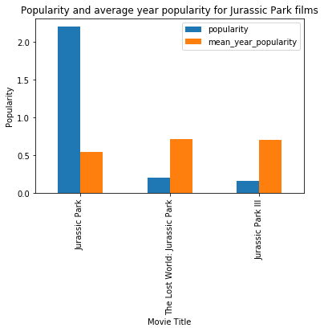

```python
jurassicpark_plot = create_pop_plot(jurassicpark_df, 'Jurassic Park')
```

## Mad Max: Fury Road (Max Max series)

### Mad Max (1979)

```python
movies_df[(movies_df['release_year'] == 1979)]
```

|  | popularity | original_title | cast | director | keywords | overview | runtime | genres | production_companies | release_date | vote_count | vote_average | release_year |
| --- | --- | --- | --- | --- | --- | --- | --- | --- | --- | --- | --- | --- | --- |
| 7825 | 4.935897 | Alien | Sigourney Weaver\|Tom Skerritt\|Veronica Cartwri... | Ridley Scott | android\|self-destruction\|countdown\|space marin... | During its return to the earth, commercial spa... | 117 | Horror\|Action\|Thriller\|Science Fiction | Twentieth Century-Fox Productions\|Brandywine P... | 5/25/79 | 2724 | 7.6 | 1979 |
| 7826 | 2.319520 | Apocalypse Now | Martin Sheen\|Marlon Brando\|Robert Duvall\|Laure... | Francis Ford Coppola | guerilla\|river\|vietnam\|vietcong\|cambodia | At the height of the Vietnam war, Captain Benj... | 153 | Drama\|War | Zoetrope Studios | 8/15/79 | 1100 | 7.8 | 1979 |
| 7827 | 2.012021 | Mad Max | Mel Gibson\|Joanne Samuel\|Hugh Keays-Byrne\|Stev... | George Miller | chain\|baby\|bridge\|post-apocalyptic\|dystopia | In a dystopic future Australia, a vicious bike... | 93 | Adventure\|Action\|Thriller\|Science Fiction | Kennedy Miller Productions\|Mad Max Films\|Cross... | 4/12/79 | 667 | 6.5 | 1979 |
| 7828 | 1.823058 | Star Trek: The Motion Picture | William Shatner\|Leonard Nimoy\|George Takei\|Jam... | Robert Wise | artificial intelligence\|uss enterprise\|starfle... | When a destructive space entity is spotted app... | 132 | Science Fiction\|Adventure\|Mystery | Paramount Pictures | 12/6/79 | 304 | 6.0 | 1979 |
| 7829 | 1.691143 | Moonraker | Roger Moore\|Lois Chiles\|Michael Lonsdale\|Corin... | Lewis Gilbert | venice\|mass murder\|space marine\|space suit\|mar... | During the transportation of a Space Shuttle a... | 126 | Action\|Adventure\|Thriller\|Science Fiction | Eon Productions | 6/26/79 | 299 | 5.7 | 1979 |
| 7830 | 1.465088 | Life of Brian | Graham Chapman\|John Cleese\|Terry Gilliam\|Eric ... | Terry Jones | christianity\|male nudity\|jewry\|resistance\|glad... | A brilliant parody from the British comedy gro... | 94 | Comedy | HandMade Films\|Python (Monty) Pictures | 8/16/79 | 716 | 7.5 | 1979 |
| 7831 | 1.394910 | Beneath the Valley of the Ultra-Vixens | Uschi Digard\|Ann Marie\|Stuart Lancaster\|Michae... | Russ Meyer | male nudity\|female nudity\|sex\|nudity\|blow job | Believe it or not even in Smalltown USA there ... | 93 | Comedy | RM Films International | 5/11/79 | 12 | 5.0 | 1979 |
| 7832 | 1.119476 | The Warriors | Michael Beck\|James Remar\|David Patrick Kelly\|D... | Walter Hill | gang war\|gangster boss\|coney island\|gang\|new y... | Prominent gang leader Cyrus calls a meeting of... | 93 | Action\|Adventure\|Crime\|Drama\|Thriller | Paramount Pictures | 2/9/79 | 206 | 7.0 | 1979 |
| 7833 | 1.049233 | Rocky II | Sylvester Stallone\|Talia Shire\|Burt Young\|Carl... | Sylvester Stallone | transporter\|coma\|wife husband relationship\|int... | After Rocky goes the distance with champ Apoll... | 119 | Drama | United Artists | 6/15/79 | 504 | 6.8 | 1979 |
| 7834 | 0.973049 | Caligola | Malcolm McDowell\|Teresa Ann Savoy\|Helen Mirren... | Tinto Brass | italy\|assassination\|rape\|sexuality\|roman empire | The perversion behind imperial Rome, the epic ... | 156 | Drama\|History\|Romance | Penthouse Films International\|Felix Cinematorg... | 1/21/79 | 65 | 5.3 | 1979 |
| 7835 | 0.961390 | Manhattan | Woody Allen\|Diane Keaton\|Michael Murphy\|Mariel... | Woody Allen | new york\|adultery\|based on novel\|lolita\|love | The life of a divorced television writer datin... | 96 | Comedy\|Drama\|Romance | Jack Rollins & Charles H. Joffe Productions | 4/25/79 | 310 | 7.7 | 1979 |
| 7836 | 0.794667 | Phantasm | Angus Scrimm\|A. Michael Baldwin\|Bill Thornbury... | Don Coscarelli | evil\|ice cream man Â \|mausoleum\|tall man\|senti... | A young boy and his friends face off against a... | 89 | Horror\|Science Fiction | New Breed Productions | 3/28/79 | 50 | 6.1 | 1979 |
| 7837 | 0.683837 | Hair | John Savage\|Treat Williams\|Annie Golden\|Beverl... | MiloÅ¡ Forman | hippie\|free love\|commune\|vietnam war\|army | Claude heads to New York upon receiving his dr... | 121 | Drama\|Comedy\|History\|Music | United Artists\|CIP Filmproduktion GmbH | 3/14/79 | 59 | 7.0 | 1979 |
| 7838 | 0.593218 | The Amityville Horror | James Brolin\|Margot Kidder\|Rod Steiger\|Don Str... | Stuart Rosenberg | haunted house\|long island\|indian burial ground... | George Lutz and his wife Kathleen, move into t... | 117 | Drama\|Horror\|Thriller | American International Pictures (AIP) | 7/27/79 | 81 | 6.2 | 1979 |
| 7839 | 0.567776 | Escape from Alcatraz | Clint Eastwood\|Patrick McGoohan\|Roberts Blosso... | Don Siegel | prison\|island\|mouse\|alcatraz\|biography | Escape from Alcatraz tells the story of the on... | 111 | Crime\|Drama | Paramount Pictures\|Malpaso Company | 6/22/79 | 273 | 7.1 | 1979 |
| 7840 | 0.550722 | All That Jazz | Roy Scheider\|Jessica Lange\|Leland Palmer\|Ann R... | Bob Fosse | show business\|film making\|tap dancing\|movie in... | Bob Fosse's semi-autobiographical film celebra... | 123 | Drama\|Music | Twentieth Century Fox Film Corporation\|Columbi... | 12/20/79 | 42 | 6.8 | 1979 |
| 7841 | 0.517874 | Nosferatu: Phantom der Nacht | Klaus Kinski\|Isabelle Adjani\|Bruno Ganz\|Roland... | Werner Herzog | transylvania\|small town\|coffin\|pest\|castle | Jonathan Harker is sent away to Count Dracula'... | 107 | Drama\|Horror | Gaumont\|Werner Herzog Filmproduktion\|Zweites D... | 4/11/79 | 55 | 7.3 | 1979 |
| 7842 | 0.516927 | The Black Hole | Maximilian Schell\|Anthony Perkins\|Robert Forst... | Gary Nelson | killer robot\|space marine\|ghost ship\|black hole | The explorer craft U.S.S. Palomino is returnin... | 98 | Adventure\|Family\|Science Fiction\|Action | Walt Disney Productions | 12/18/79 | 54 | 5.8 | 1979 |
| 7843 | 0.498186 | Being There | Peter Sellers\|Shirley MacLaine\|Melvyn Douglas\|... | Hal Ashby | washington d.c.\|u.s. president\|identity\|policy... | A simple-minded gardener named Chance has spen... | 130 | Comedy\|Drama | United Artists\|Lorimar Film Entertainment | 12/19/79 | 89 | 7.6 | 1979 |
| 7844 | 0.474093 | Meatballs | Bill Murray\|Harvey Atkin\|Kate Lynch\|Russ Banha... | Ivan Reitman | summer camp\|underwear on flagpole\|famous speec... | Tripper is the head counselor at a budget summ... | 92 | Comedy | Canadian Film Development Corporation (CFDC)\|F... | 6/28/79 | 37 | 5.6 | 1979 |
| 7845 | 0.473733 | The Villain | Kirk Douglas\|Ann-Margret\|Arnold Schwarzenegger... | Hal Needham | chase\|train\|explosion\|falling from height\|glue | Handsome Stranger has agreed to escort Charmin... | 89 | Comedy\|Western | Rastar Pictures | 7/26/79 | 21 | 5.9 | 1979 |
| 7846 | 0.431672 | Salem's Lot | David Soul\|James Mason\|Lance Kerwin\|Bonnie Bed... | Tobe Hooper | home\|return\|menace\|antiquary\|vampire | Vampires are invading a small New England town... | 184 | Mystery\|Horror\|Thriller | Warner Bros. Television | 11/17/79 | 60 | 5.9 | 1979 |
| 7847 | 0.426947 | The Concorde... Airport '79 | Alain Delon\|Susan Blakely\|Robert Wagner\|Sylvia... | David Lowell Rich | stewardess\|missile\|pilot\|hot air balloon\|panic | The last of the 'Airport' series again stars G... | 123 | Action\|Drama\|Thriller | Universal Pictures | 8/17/79 | 23 | 4.7 | 1979 |
| 7848 | 0.416453 | Kramer vs. Kramer | Dustin Hoffman\|Meryl Streep\|Jane Alexander\|Jus... | Robert Benton | wife husband relationship\|custody battle\|marri... | Ted Kramer is a career man for whom his work c... | 105 | Drama | Columbia Pictures | 12/19/79 | 240 | 7.3 | 1979 |
| 7849 | 0.411419 | The China Syndrome | Jane Fonda\|Jack Lemmon\|Michael Douglas\|Scott B... | James Bridges | california\|telecaster\|energy policy\|radiation\|... | While doing a series of reports on alternative... | 122 | Thriller\|Drama | Columbia Pictures\|IPC Films | 3/16/79 | 35 | 6.0 | 1979 |
| 7850 | 0.516572 | The Jerk | Steve Martin\|Bernadette Peters\|Catlin Adams\|Ma... | Carl Reiner | wild comedy\|blow\|neominstrelsy\|phone book\|shar... | After discovering he's not really black like t... | 94 | Comedy | Universal Pictures\|Aspen Film Society | 12/14/79 | 136 | 7.0 | 1979 |
| 7851 | 0.387797 | 1941 | Dan Aykroyd\|Ned Beatty\|John Belushi\|Lorraine G... | Steven Spielberg | submarine\|california\|world war ii\|war ship\|pea... | It's been six days since the attack on Pearl H... | 113 | Action\|Comedy | Columbia Pictures\|Universal Pictures\|A-Team | 12/14/79 | 62 | 5.4 | 1979 |
| 7852 | 0.360116 | ...And Justice for All | Al Pacino\|Jack Warden\|John Forsythe\|Christine ... | Norman Jewison | suspense\|lawyer\|courtroom\|extramarital affair | An ethical Baltimore defense lawyer disgusted ... | 119 | Crime\|Drama\|Mystery\|Thriller | Columbia Pictures Corporation | 10/19/79 | 48 | 6.7 | 1979 |
| 7853 | 0.315247 | Time After Time | Malcolm McDowell\|David Warner\|Mary Steenburgen... | Nicholas Meyer | jack the ripper\|time travel | The Wildest Chase Of The Century! London 1893 ... | 112 | Adventure\|Drama\|Comedy\|Science Fiction\|Thriller | Orion Pictures | 8/31/79 | 29 | 6.4 | 1979 |
| 7854 | 0.307429 | Breaking Away | Dennis Quaid\|Daniel Stern\|Jackie Earle Haley\|D... | Peter Yates | bicycle\|sport\|cycling\|bicycle race | Dave, nineteen, has just graduated high school... | 100 | Drama\|Comedy | Twentieth Century Fox Film Corporation | 5/24/79 | 34 | 7.2 | 1979 |
| 7855 | 0.267070 | Quadrophenia | Phil Daniels\|Leslie Ash\|Philip Davis\|Mark Wing... | Franc Roddam | england\|fab four\|music\|woodstock\|music festival | Based on the 1973 rock opera album of the same... | 120 | Drama\|Music | Polytel\|The Who Films | 9/14/79 | 30 | 7.3 | 1979 |
| 7856 | 0.263240 | Tess | Nastassja Kinski\|Peter Firth\|Leigh Lawson\|John... | Roman Polanski | rape\|based on novel\|peasant\|historian\|marriage | This multiple-Oscar-winning film by Roman Pola... | 171 | Drama\|Romance | Renn Productions\|Société Française de Produ... | 10/6/79 | 33 | 6.4 | 1979 |
| 7857 | 0.262123 | The Frisco Kid | Gene Wilder\|Harrison Ford\|Ramon Bieri\|Val Biso... | Robert Aldrich | NaN | Rabbi Avram arrives in Philadelphia from Polan... | 114 | Western\|Comedy | Warner Bros. | 7/6/79 | 16 | 5.9 | 1979 |
| 7858 | 0.255216 | The First Great Train Robbery | Sean Connery\|Donald Sutherland\|Lesley-Anne Dow... | Michael Crichton | writer director\|held at swordpoint\|public hang... | In Victorian England, a master criminal makes ... | 110 | Thriller\|Adventure\|Drama\|Crime | Starling Films | 1/25/79 | 38 | 6.3 | 1979 |
| 7859 | 0.245390 | 10 | Dudley Moore\|Julie Andrews\|Bo Derek\|Robert Web... | Blake Edwards | mexico\|beach\|fantasy\|honeymoon\|marriage | A Hollywood songwriter goes through a mid-life... | 122 | Comedy\|Romance | Orion Pictures Corporation\|Geoffrey Productions | 10/4/79 | 27 | 5.3 | 1979 |
| 7860 | 0.159632 | The Black Stallion | Kelly Reno\|Mickey Rooney\|Teri Garr\|Clarence Mu... | Carroll Ballard | poker\|horse\|barn\|training\|sport | While traveling with his father, young Alec be... | 118 | Adventure\|Family | United Artists | 10/17/79 | 28 | 6.8 | 1979 |
| 7861 | 0.151386 | The Electric Horseman | Robert Redford\|Jane Fonda\|Valerie Perrine\|Will... | Sydney Pollack | rodeo\|horse\|doping\|performance\|love | Sonny Steele used to be a rodeo star, but his ... | 122 | Drama\|Comedy\|Western\|Romance | Columbia Pictures\|Universal Pictures\|Wildwood ... | 12/21/79 | 11 | 4.8 | 1979 |
| 7862 | 0.147473 | The Bugs Bunny/Road Runner Movie | Mel Blanc | Chuck Jones | NaN | A collection of Warner Brothers short cartoon ... | 98 | Comedy\|Animation\|Family | Warner Bros. Animation | 9/30/79 | 10 | 6.0 | 1979 |
| 7863 | 0.195559 | All Quiet on the Western Front | Richard Thomas\|Ernest Borgnine\|Donald Pleasenc... | Delbert Mann | germany\|france\|world war i\|westfront\|soldier | At the start of World War I, Paul Baumer is a ... | 150 | Drama\|History\|War | Norman Rosemont Productions\|Marble Arch Produc... | 11/14/79 | 19 | 6.1 | 1979 |
| 7864 | 0.141546 | The Apple Dumpling Gang Rides Again | Tim Conway\|Don Knotts\|Tim Matheson\|Kenneth Mar... | Vincent McEveety | spoof | Amos and Theodore, the two bumbling outlaw wan... | 88 | Comedy\|Family\|Western | Walt Disney Productions | 6/27/79 | 10 | 6.7 | 1979 |
| 7865 | 0.189906 | Meteor | Sean Connery\|Natalie Wood\|Karl Malden\|Brian Ke... | Ronald Neame | meteor\|disaster\|disaster film\|disaster movie | After a collision with a comet, a nearly 8km w... | 107 | Action\|Science Fiction\|Thriller | Palladium Productions\|American International P... | 10/19/79 | 14 | 4.5 | 1979 |
| 7866 | 0.178663 | Scum | Ray Winstone\|Mick Ford\|Julian Firth\|John Blund... | Alan Clarke | suicide\|prison\|england\|corruption\|riot | This is the hard and shocking story of life in... | 98 | Crime\|Drama | Berwick Street Productions\|Boyd's Company\|Kend... | 9/12/79 | 11 | 7.1 | 1979 |
| 7867 | 0.167108 | Hardcore | George C. Scott\|Peter Boyle\|Season Hubley\|Dick... | Paul Schrader | pornography\|runaway\|snuff\|daughter\|father | A conservative Midwest businessman ventures in... | 109 | Crime\|Drama\|Thriller | Columbia Pictures Corporation\|A-Team | 2/9/79 | 16 | 6.1 | 1979 |
| 7868 | 0.164320 | Hanover Street | Harrison Ford\|Lesley-Anne Down\|Christopher Plu... | Peter Hyams | london\|world war ii\|secret mission\|bomber pilot | Margaret is a nurse in England during WW2, and... | 109 | Drama\|Romance\|War | Columbia Pictures Corporation\|Hanover Street | 5/18/79 | 10 | 5.5 | 1979 |
| 7869 | 0.216684 | Love at First Bite | George Hamilton\|Susan Saint James\|Richard Benj... | Stan Dragoti | coffin\|vampire\|dracula\|romantic comedy\|spoof | Dracula and Renefield relocate to 70's era New... | 96 | Romance\|Comedy\|Horror | Melvin Simon Productions\|American Internationa... | 4/27/79 | 13 | 6.0 | 1979 |
| 7870 | 0.160160 | The Brood | Oliver Reed\|Samantha Eggar\|Art Hindle\|Henry Be... | David Cronenberg | psychologist\|body horror\|canuxploitation | A man tries to uncover an unconventional psych... | 92 | Horror\|Thriller\|Science Fiction | Canadian Film Development Corporation (CFDC)\|V... | 5/25/79 | 47 | 6.1 | 1979 |
| 7871 | 0.158960 | Stridulum | Glenn Ford\|Lance Henriksen\|John Huston\|Joanne ... | Giulio Paradisi | atlanta\|telekinesis\|evil child | An ancient intergalactic warrior arrives on Ea... | 108 | Science Fiction\|Horror | Film Ventures International (FVI)\|Brouwersgrac... | 3/22/79 | 11 | 3.0 | 1979 |
| 7872 | 0.127707 | Richard Pryor: Live in Concert | Richard Pryor\|Jennifer Lee Pryor | Jeff Margolis | black comedy | This concert was recorded live at the Terrace ... | 78 | Comedy | NaN | 1/1/79 | 14 | 7.0 | 1979 |
| 7873 | 0.125888 | When a Stranger Calls | Carol Kane\|Charles Durning\|Colleen Dewhurst\|To... | Fred Walton | babysitter\|suspense\|phone call | A psychopathic killer terrorizes a babysitter,... | 97 | Horror\|Thriller | Columbia Pictures Corporation\|Melvin Simon Pro... | 10/26/79 | 16 | 6.0 | 1979 |
| 7874 | 0.112760 | The Onion Field | John Savage\|James Woods\|Franklyn Seales\|Ted Da... | Harold Becker | cop-killer\|based on true story\|police officer ... | Greg Powell, a disturbed ex-con, recruits Jimm... | 122 | Crime\|Drama | Black Marble Productions | 9/9/79 | 10 | 5.1 | 1979 |
| 7875 | 0.110767 | The Wanderers | Ken Wahl\|John Friedrich\|Karen Allen\|Toni Kalem... | Philip Kaufman | new york\|street gang\|black people\|rock and rol... | The streets of the Bronx are owned by 60’s y... | 117 | Drama | Orion Pictures Corporation\|Warner Bros. Home E... | 7/13/79 | 14 | 7.5 | 1979 |
| 7876 | 0.226122 | Over the Edge | Matt Dillon\|Vincent Spano\|Andy Romano\|Ellen Ge... | Jonathan Kaplan | alcohol\|vandalism\|police\|drug scene\|teen angst | The music of Cheap Trick, The Cars, and The Ra... | 95 | Crime\|Drama | Orion Pictures | 11/2/79 | 12 | 7.1 | 1979 |
| 7877 | 0.077321 | Tourist Trap | Chuck Connors\|Jocelyn Jones\|Jon Van Ness\|Robin... | David Schmoeller | mask\|museum\|mannequin\|cult\|psychopath | Their car breaks down and four friends find th... | 90 | Horror\|Mystery\|Thriller | Charles Band Productions | 1/25/79 | 24 | 6.9 | 1979 |
| 7878 | 0.386843 | Rock 'n' Roll High School | P.J. Soles\|Vince Van Patten\|Clint Howard\|Mary ... | Allan Arkush | rock and roll\|punk\|bong\|rebellion\|camp | A group of rock-music-loving students, with th... | 93 | Comedy\|Music | New World Pictures | 8/24/79 | 17 | 6.2 | 1979 |
| 7879 | 0.058087 | Norma Rae | Sally Field\|Beau Bridges\|Ron Leibman\|Pat Hingl... | Martin Ritt | factory\|single mother\|union\|labor\|textile worker | Norma Rae is a southern textile worker employe... | 110 | Drama | Twentieth Century Fox Film Corporation | 3/2/79 | 13 | 5.8 | 1979 |
| 7880 | 0.032098 | Dracula | Frank Langella\|Laurence Olivier\|Donald Pleasen... | John Badham | vampire\|dracula\|insane asylum\|gothic horror | Romanticized adaptation of Bram Stoker's 1897 ... | 109 | Horror\|Romance | Universal Pictures\|The Mirisch Corporation | 7/20/79 | 19 | 6.1 | 1979 |
| 7881 | 0.019263 | The Champ | Jon Voight\|Faye Dunaway\|Ricky Schroder\|Jack Wa... | Franco Zeffirelli | boxer\|boxing match\|son\|father\|sport | The more you love, the harder you fight.The wo... | 121 | Drama\|Family | Metro-Goldwyn-Mayer (MGM) | 7/10/79 | 12 | 7.1 | 1979 |

Looky here! Mad Max is third on the list with a popularity of 2.012021. That makes this easy.

### Mad Max 2 (1981)

```python
movies_df[(movies_df['release_year'] == 1981)]
```

|  | popularity | original_title | cast | director | keywords | overview | runtime | genres | production_companies | release_date | vote_count | vote_average | release_year |
| --- | --- | --- | --- | --- | --- | --- | --- | --- | --- | --- | --- | --- | --- |
| 8375 | 4.578300 | Raiders of the Lost Ark | Harrison Ford\|Karen Allen\|Paul Freeman\|Ronald ... | Steven Spielberg | saving the world\|riddle\|nepal\|himalaya\|cairo | When Dr. Indiana Jones – the tweed-suited pr... | 115 | Adventure\|Action | Lucasfilm\|Paramount Pictures | 6/12/81 | 2506 | 7.5 | 1981 |
| 8376 | 1.947170 | Private Lessons | Sylvia Kristel\|Howard Hesseman\|Eric Brown\|Meri... | Alan Myerson | female nudity\|bathroom\|sex\|blackmail\|chauffeur | Phillip Filmore is a naive, 15-year-old, preoc... | 87 | Romance\|Comedy | Jensen Farley Pictures\|Barry & Enright Product... | 8/21/81 | 10 | 6.1 | 1981 |
| 8377 | 1.771093 | For Your Eyes Only | Roger Moore\|Carole Bouquet\|Chaim Topol\|Lynn-Ho... | John Glen | london\|submarine\|england\|sea\|assassin | A British spy ship has sunk and on board was a... | 127 | Adventure\|Action\|Thriller | Eon Productions\|Metro-Goldwyn-Mayer (MGM) | 6/23/81 | 268 | 6.0 | 1981 |
| 8378 | 1.278646 | The Fox and the Hound | Mickey Rooney\|Kurt Russell\|Pearl Bailey\|Jack A... | Ted Berman\|Art Stevens\|Richard Rich | based on novel\|fox\|foxhunting\|friendship\|dog | When a feisty little fox named Tod is adopted ... | 82 | Adventure\|Animation\|Drama\|Family | Walt Disney Productions | 7/10/81 | 498 | 6.9 | 1981 |
| 8379 | 1.248748 | Mad Max 2 | Mel Gibson\|Bruce Spence\|Michael Preston\|Max Ph... | George Miller | boomerang\|chase\|post-apocalyptic\|dystopia\|surv... | Max Rockatansky returns as the heroic loner wh... | 95 | Adventure\|Action\|Thriller\|Science Fiction | Kennedy Miller Productions | 12/23/81 | 501 | 7.1 | 1981 |
| 8380 | 1.114068 | History of the World: Part I | Mel Brooks\|Dom DeLuise\|Madeline Kahn\|Harvey Ko... | Mel Brooks | moses\|roman empire\|musical\|stone age\|music | An uproarious version of history that proves n... | 92 | Comedy | Twentieth Century Fox Film Corporation\|Brooksf... | 6/12/81 | 91 | 6.3 | 1981 |
| 8381 | 1.055415 | An American Werewolf in London | David Naughton\|Jenny Agutter\|Griffin Dunne\|Joh... | John Landis | loss of lover\|intensive care\|dying and death\|v... | Two American tourists in England are attacked ... | 97 | Horror\|Comedy | Universal Pictures\|Guber/Peters Company\|Americ... | 8/21/81 | 284 | 7.0 | 1981 |
| 8382 | 1.029422 | Heavy Metal | Rodger Bumpass\|Jackie Burroughs\|Joe Flaherty\|H... | Gerald Potterton | flying car\|taxi\|heavy metal\|cult favorite\|midn... | A glowing orb terrorizes a young girl with a c... | 90 | Animation\|Science Fiction | Canadian Film Development Corporation (CFDC) | 8/7/81 | 73 | 6.3 | 1981 |
| 8383 | 1.021218 | The Evil Dead | Bruce Campbell\|Ellen Sandweiss\|Richard DeManin... | Sam Raimi | falsely accused person\|beheading\|audio tape\|lo... | When a group of college students finds a myste... | 85 | Horror | Renaissance Pictures | 10/15/81 | 426 | 7.2 | 1981 |
| 8384 | 1.003963 | Escape from New York | Kurt Russell\|Lee Van Cleef\|Ernest Borgnine\|Don... | John Carpenter | taxi\|street gang\|u.s. president\|war veteran\|ho... | In 1997, the island of Manhattan has been wall... | 99 | Science Fiction\|Action | AVCO Embassy Pictures\|Goldcrest Films Internat... | 5/22/81 | 336 | 6.5 | 1981 |
| 8385 | 0.995357 | Excalibur | Nigel Terry\|Helen Mirren\|Nicholas Clay\|Cherie ... | John Boorman | holy grail\|camelot\|round table\|wizardry\|merlin | The myth of King Arthur brought to the screen.... | 140 | Adventure | Orion Pictures\|Warner Bros. | 4/10/81 | 107 | 6.5 | 1981 |
| 8386 | 0.683132 | On Golden Pond | Katharine Hepburn\|Henry Fonda\|Jane Fonda\|Doug ... | Mark Rydell | son\|daughter\|mother daughter relationship\|fami... | The loons are back again on Golden Pond and so... | 109 | Drama | Universal Pictures | 12/4/81 | 28 | 6.6 | 1981 |
| 8387 | 0.659900 | Chariots of Fire | Ben Cross\|Ian Charleson\|Cheryl Campbell\|Alice ... | Hugh Hudson | underdog\|scotland\|jewry\|patriotism\|olympic games | Based on the true story of British athletes pr... | 123 | Drama\|History | Twentieth Century Fox Film Corporation\|Warner ... | 5/15/81 | 93 | 6.6 | 1981 |
| 8388 | 0.615760 | Friday the 13th Part 2 | Amy Steel\|John Furey\|Adrienne King\|Kirsten Bak... | Steve Miner | camping\|summer camp\|gore\|slasher\|b horror | Five years after the horrible bloodbath at Cam... | 87 | Horror\|Thriller | Paramount Pictures | 5/1/81 | 134 | 6.2 | 1981 |
| 8389 | 0.614293 | Southern Comfort | Keith Carradine\|Powers Boothe\|Fred Ward\|Frankl... | Walter Hill | joke\|louisiana\|wilderness\|swamp\|national guard | A squad of National Guards on an isolated week... | 105 | Action\|Drama\|History\|Thriller | Cinema Group Ventures\|Phoenix (II) | 9/25/81 | 17 | 5.8 | 1981 |
| 8390 | 0.592041 | Gallipoli | Mel Gibson\|Mark Lee\|Bill Kerr\|Gerda Nicolson\|H... | Peter Weir | world war i\|battle assignment\|troops\|australia... | As World War I rages, brave and youthful Austr... | 112 | Adventure\|War\|Drama\|History | The Australian Film Commission\|R & R Films | 8/13/81 | 42 | 7.0 | 1981 |
| 8391 | 0.564939 | Halloween II | Jamie Lee Curtis\|Donald Pleasence\|Charles Cyph... | Rick Rosenthal | sheriff\|mask\|halloween\|michael myers | After failing to kill stubborn survivor Laurie... | 92 | Horror\|Thriller | Universal Pictures | 10/30/81 | 162 | 6.4 | 1981 |
| 8392 | 0.521554 | The Postman Always Rings Twice | Jack Nicholson\|Jessica Lange\|John Colicos\|Mich... | Bob Rafelson | sex\|adultery\|confession\|based on novel\|obsession | This remake of the 1946 movie of the same name... | 122 | Romance\|Crime\|Drama | Lorimar Film Entertainment\|CIP Filmproduktion ... | 3/20/81 | 36 | 6.3 | 1981 |
| 8393 | 0.514549 | Arthur | Dudley Moore\|Liza Minnelli\|John Gielgud\|Gerald... | Steve Gordon | new york city\|1980s\|comic drunk | Arthur is the most quotable drunk millionaire ... | 97 | Comedy\|Drama\|Romance | Orion Pictures | 7/17/81 | 45 | 6.4 | 1981 |
| 8394 | 0.510003 | Road Games | Stacy Keach\|Jamie Lee Curtis\|Marion Edward\|Gra... | Richard Franklin | australia\|truck\|suspense\|serial killer\|hitchhiker | A truck driver plays a cat-and-mouse game with... | 101 | Thriller\|Horror\|Mystery | Essaness Pictures\|Quest | 6/26/81 | 12 | 5.8 | 1981 |
| 8395 | 0.502896 | Endless Love | Brooke Shields\|Martin Hewitt\|Shirley Knight\|Do... | Franco Zeffirelli | NaN | Two young kids fall in love with each other. B... | 116 | Romance\|Drama | Universal Pictures | 7/17/81 | 16 | 5.5 | 1981 |
| 8396 | 0.473893 | Porky's | Dan Monahan\|Mark Herrier\|Wyatt Knight\|Cyril O'... | Bob Clark | male nudity\|female nudity\|sex\|florida\|virgin | Set in 1954, a group of Florida high schoolers... | 94 | Comedy | Melvin Simon Productions\|Astral Bellevue Pathé | 11/13/81 | 75 | 6.0 | 1981 |
| 8397 | 0.469885 | Reds | Warren Beatty\|Diane Keaton\|Edward Herrmann\|Jac... | Warren Beatty | journalist\|russian revolution 1917 | A radical American journalist becomes involved... | 195 | Drama\|History | Barclays Mercantile Industrial Finance\|JRS Pro... | 12/25/81 | 25 | 6.5 | 1981 |
| 8398 | 0.439555 | The Cannonball Run | Burt Reynolds\|Roger Moore\|Farrah Fawcett\|Dean ... | Hal Needham | cross country race\|all-star supporting cast | A cross-country road race is based on an actua... | 95 | Comedy | Eurasia Investments | 6/19/81 | 64 | 6.3 | 1981 |
| 8399 | 0.426376 | Absence of Malice | Paul Newman\|Sally Field\|Bob Balaban\|Melinda Di... | Sydney Pollack | prosecutor\|newspaper reporter | A prosecutor leaks a false story that liquor w... | 116 | Drama\|Romance\|Thriller | Columbia Pictures Corporation\|Mirage Enterprises | 12/18/81 | 16 | 6.8 | 1981 |
| 8400 | 0.416180 | Time Bandits | John Cleese\|Sean Connery\|Shelley Duvall\|Kather... | Terry Gilliam | treasure\|map\|magic\|time travel\|titanic | A boy escapes from his gadget-obsessed parents... | 116 | Family\|Fantasy\|Science Fiction\|Adventure\|Comedy | Handmade Films Ltd. | 7/13/81 | 112 | 6.1 | 1981 |
| 8401 | 0.390801 | Scanners | Stephen Lack\|Jennifer O'Neill\|Michael Ironside... | David Cronenberg | telepathy\|telekinesis\|mind control\|psychic pow... | Darryl Revok is the most powerful of all the s... | 103 | Horror\|Science Fiction\|Thriller | Canadian Film Development Corporation (CFDC)\|F... | 1/14/81 | 93 | 6.2 | 1981 |
| 8402 | 0.383124 | Victory | Michael Caine\|Sylvester Stallone\|Max von Sydow... | John Huston | escape\|nazi germany\|soccer | A group of POWs in a German prison camp during... | 116 | Action\|Drama | Paramount\|Lorimar | 6/17/81 | 73 | 6.5 | 1981 |
| 8403 | 0.374104 | Thief | James Caan\|Tuesday Weld\|Willie Nelson\|Jim Belu... | Michael Mann | chicago\|burglar\|car dealer\|shadowing\|death of ... | Frank is an expert professional safecracker, s... | 122 | Action\|Crime\|Drama\|Thriller | Mann/Caan Productions | 3/27/81 | 41 | 7.0 | 1981 |
| 8404 | 0.346695 | Piranha Part Two: The Spawning | Tricia O'Neil\|Steve Marachuk\|Lance Henriksen\|R... | James Cameron | NaN | A scuba diving instructor, her biochemist boyf... | 84 | Horror\|Drama\|Romance | Brouwersgracht Investments\|Chako Film Company | 1/1/81 | 14 | 4.8 | 1981 |
| ... | ... | ... | ... | ... | ... | ... | ... | ... | ... | ... | ... | ... | ... |
| 8427 | 0.177964 | The Great Muppet Caper | Jim Henson\|Frank Oz\|Dave Goelz\|Jerry Nelson\|Ri... | Jim Henson | the muppets\|kermit the frog\|marretas | Kermit and Fozzie are newspaper reporters sent... | 95 | Crime\|Family\|Comedy | Incorporated Television Company (ITC)\|Henson A... | 6/26/81 | 34 | 6.8 | 1981 |
| 8428 | 0.136609 | Cutter's Way | Jeff Bridges\|John Heard\|Lisa Eichhorn\|Ann Duse... | Ivan Passer | california\|prostitute\|alcohol\|vietnam\|witness | Richard spots a man dumping a body, and decide... | 105 | Drama\|Mystery\|Thriller\|Crime | United Artists\|Gurian Entertainment | 3/19/81 | 12 | 5.5 | 1981 |
| 8429 | 0.176100 | Sharky's Machine | Burt Reynolds\|Rachel Ward\|Henry Silva\|Brian Ke... | Burt Reynolds | transvestism\|robbery\|martial arts\|jazz\|finger | Sharky gets busted back to working vice, where... | 122 | Crime\|Drama\|Action\|Thriller | Warner Bros.\|Deliverance Productions | 12/18/81 | 14 | 5.9 | 1981 |
| 8430 | 0.140980 | Student Bodies | Kristen Riter\|Matthew Goldsby\|Jerry Belson\|Joe... | Mickey Rose\|Michael Ritchie | countdown\|parody\|slasher\|horror spoof\|rubber c... | Director Mickey Rose's zany send-up of teen sl... | 86 | Comedy\|Horror\|Mystery | Paramount Pictures | 8/7/81 | 13 | 4.8 | 1981 |
| 8431 | 0.174968 | Galaxy of Terror | Edward Albert\|Erin Moran\|Ray Walston\|Bernard B... | Bruce D. Clark | alien\|astronaut\|alien possession\|raped by mons... | As a lone spaceship proceeds on its long voyag... | 81 | Action\|Adventure\|Horror\|Science Fiction | New World Pictures | 10/1/81 | 13 | 5.1 | 1981 |
| 8432 | 0.164888 | Condorman | Michael Crawford\|Oliver Reed\|Barbara Carrera\|J... | Charles Jarrott | mission | Comic artist and writer Woody performs a simpl... | 90 | Comedy\|Action\|Adventure | Walt Disney Productions | 7/2/81 | 20 | 6.1 | 1981 |
| 8433 | 0.169913 | Ghost Story | Fred Astaire\|Melvyn Douglas\|Douglas Fairbanks ... | John Irvin | secret\|ghost story | Four successful elderly gentlemen, members of ... | 110 | Drama\|Horror\|Thriller | Universal Pictures | 12/18/81 | 10 | 5.7 | 1981 |
| 8434 | 0.196736 | The Burning | Brian Matthews\|Leah Ayres\|Brian Backer\|Larry J... | Tony Maylam | summer camp\|woods\|burned alive\|camp\|slasher | A caretaker at a summer camp is burned when a ... | 91 | Horror\|Thriller | Miramax Films\|The Cropsy Venture | 5/8/81 | 38 | 5.9 | 1981 |
| 8435 | 0.166441 | Happy Birthday to Me | Melissa Sue Anderson\|Glenn Ford\|Lawrence Dane\|... | J. Lee Thompson | slasher | Virginia is proud that she belongs to a clique... | 110 | Drama\|Horror\|Thriller\|Mystery | Columbia Pictures Corporation\|Canadian Film De... | 5/15/81 | 11 | 5.8 | 1981 |
| 8436 | 0.161586 | The Funhouse | Elizabeth Berridge\|Shawn Carson\|Jeanne Austin\|... | Tobe Hooper | nudity\|mask\|carnival\|horror\|violence | Rebellious teen Amy (Elizabeth Berridge) defie... | 96 | Horror | Mace Neufeld Productions | 3/13/81 | 17 | 6.0 | 1981 |
| 8437 | 0.090470 | Bianco, rosso e Verdone | Carlo Verdone\|Irina Sanpiter\|Elena Fabrizi\|Ang... | Carlo Verdone | italy\|election day | Three Italian have to move from their current ... | 110 | Comedy | Columbia Films S.A.\|Irrigazione Cinematografica | 2/20/81 | 34 | 6.6 | 1981 |
| 8438 | 0.156406 | Looker | Albert Finney\|James Coburn\|Susan Dey\|Leigh Tay... | Michael Crichton | model\|plastic surgeon | Plastic surgeon Larry Roberts performs a serie... | 94 | Science Fiction\|Thriller | Warner Bros.\|The Ladd Company | 10/30/81 | 10 | 4.2 | 1981 |
| 8439 | 0.143798 | Caveman | Ringo Starr\|Dennis Quaid\|Shelley Long\|Jack Gil... | Carl Gottlieb | stone age\|slapstick\|cavemen\|prehistoric advent... | In this comedy, Atouk becomes leader of the mi... | 91 | Comedy\|Adventure | Turman-Foster Company | 4/17/81 | 12 | 5.9 | 1981 |
| 8440 | 0.128101 | Hell Night | Linda Blair\|Vince Van Patten\|Peter Barton\|Suki... | Tom DeSimone | college\|serial killer\|ghost\|leopard print\|scre... | Four college pledges are forced to spend the n... | 101 | Horror | BLT Productions\|Media Home Entertainment | 8/28/81 | 15 | 5.9 | 1981 |
| 8441 | 0.123622 | My Bloody Valentine | Paul Kelman\|Lori Hallier\|Neil Affleck\|Keith Kn... | George Mihalka | miner\|murder\|serial killer\|masked killer\|slasher | Twenty years ago in the sleepy mining town of ... | 90 | Thriller\|Horror\|Mystery | Paramount Pictures\|Famous Players Ltd\|Canadian... | 2/11/81 | 21 | 6.4 | 1981 |
| 8442 | 0.207373 | Mommie Dearest | Faye Dunaway\|Diana Scarwid\|Steve Forrest\|Howar... | Frank Perry | ax\|biography\|sociopath\|lawyer\|mansion | In this biographical film, glamorous yet lonel... | 129 | Drama | Paramount Pictures | 9/18/81 | 13 | 6.0 | 1981 |
| 8443 | 0.100612 | Wolfen | Albert Finney\|Diane Venora\|Edward James Olmos\|... | Michael Wadleigh | indian\|wolf\|transformation\|investigation\|horror | A New York cop investigates a series of brutal... | 115 | Drama\|Horror\|Thriller | Orion Pictures Corporation\|King-Hitzig Product... | 7/24/81 | 18 | 5.6 | 1981 |
| 8444 | 0.049718 | Neighbors | John Belushi\|Kathryn Walker\|Cathy Moriarty\|Dan... | John G. Avildsen | family abandonment\|dinner\|cult film\|sexual des... | One man's quiet suburban life takes a sickenin... | 94 | Comedy | Columbia Pictures | 12/18/81 | 14 | 4.4 | 1981 |
| 8445 | 0.089413 | Dark Night of the Scarecrow | Larry Drake\|Charles Durning\|Robert F. Lyons\|Cl... | Frank De Felitta | scarecrow | A retarded man is unjustly accused of attackin... | 96 | TV Movie\|Horror\|Mystery | Wizan Productions | 10/24/81 | 10 | 4.6 | 1981 |
| 8446 | 0.087937 | American Pop | Ron Thompson\|Lisa Jane Persky\|Jeffrey Lippa\|Fr... | Ralph Bakshi | pop\|jazz\|tzar\|music\|mafia boss | American Pop is an American animated film that... | 96 | Animation\|Music | Columbia Pictures Corporation\|Bakshi Productio... | 2/13/81 | 14 | 6.4 | 1981 |
| 8447 | 0.071421 | The Decline of Western Civilization | Alice Bag\|Claude Bessey\|Black Flag\|Don Bolles\|... | Penelope Spheeris | punk\|subculture\|punk band\|woman director | The Los Angeles punk music scene circa 1980 is... | 100 | Documentary\|Music | Spheeris Films Inc. | 7/1/81 | 16 | 7.2 | 1981 |
| 8448 | 0.069544 | Gregory's Girl | John Gordon Sinclair\|Dee Hepburn\|Jake D'Arcy\|C... | Bill Forsyth | scotland\|italian\|affection\|advice\|coming of age | In his Scottish New Town home, gangling Gregor... | 91 | Comedy\|Romance | National Film Finance Corporation (NFFC)\|Lake ... | 4/23/81 | 13 | 6.2 | 1981 |
| 8449 | 0.064153 | Bloody Birthday | Lori Lethin\|Melinda Cordell\|Julie Brown\|Susan ... | Ed Hunt | sex\|birthday\|nudity\|babysitter\|elementary school | In 1970, three children are born at the height... | 85 | Horror\|Thriller | Judica Productions | 4/28/81 | 12 | 6.0 | 1981 |
| 8450 | 0.062235 | The Incredible Shrinking Woman | Lily Tomlin\|Charles Grodin\|Ned Beatty\|Henry Gi... | Joel Schumacher | NaN | After being exposed to a bizarre mixture of ho... | 88 | Comedy\|Family\|Science Fiction | Universal Pictures | 1/30/81 | 13 | 4.7 | 1981 |
| 8451 | 0.062202 | Continental Divide | John Belushi\|Blair Brown\|Allen Garfield\|Carlin... | Michael Apted | journalist\|camping\|rocky mountains\|eagle\|bear | A hard-nosed Chicago journalist has an unlikel... | 103 | Comedy\|Romance | Universal Pictures\|Amblin Entertainment | 9/18/81 | 11 | 4.5 | 1981 |
| 8452 | 0.047479 | Vernon, Florida | Albert Bitterling\|Roscoe Collins\|George Harris | Errol Morris | NaN | Early Errol Morris documentary intersplices ra... | 55 | Documentary | NaN | 10/8/81 | 11 | 5.1 | 1981 |
| 8453 | 0.059877 | The Prowler | Vicky Dawson\|Christopher Goutman\|Lawrence Tier... | Joseph Zito | nudity\|mask\|murder\|psychopathic killer\|gore | A masked killer, wearing World War II U.S. Arm... | 89 | Thriller\|Horror\|Mystery | Graduation | 11/6/81 | 14 | 6.0 | 1981 |
| 8454 | 0.046679 | Enter the Ninja | Franco Nero\|Susan George\|Christopher George\|Sh... | Menahem Golan | martial arts\|fight\|chase\|philippines\|ninjas | After completing his training of ninjutsu with... | 100 | Crime\|Action\|Drama | City Film\|Golan-Globus Productions\|The Cannon ... | 7/17/81 | 11 | 5.5 | 1981 |
| 8455 | 0.254886 | Prince of the City | Treat Williams\|Jerry Orbach\|Richard Foronjy\|Do... | Sidney Lumet | new york\|corruption\|1970s\|police | New York City detective Daniel Ciello agrees t... | 167 | Drama\|Thriller\|Crime | Orion Pictures Corporation | 8/20/81 | 17 | 6.6 | 1981 |
| 8456 | 0.150674 | The Hitch Hikers Guide to the Galaxy | Peter Jones\|Simon Jones\|David Dixon\|Sandra Dic... | Alan J.W. Bell | NaN | An Earth Man and his alien friend escape an ex... | 150 | Adventure\|Comedy\|Science Fiction | NaN | 2/9/81 | 17 | 6.5 | 1981 |

82 rows × 13 columns

This one is easy too. *Max Max 2* is 5th on the list at a popularity of 1.248748.

### Mad Max Beyond Thunderdome (1985)

```python
movies_df[(movies_df['release_year'] == 1985)]
```

|  | popularity | original_title | cast | director | keywords | overview | runtime | genres | production_companies | release_date | vote_count | vote_average | release_year |
| --- | --- | --- | --- | --- | --- | --- | --- | --- | --- | --- | --- | --- | --- |
| 6081 | 6.095293 | Back to the Future | Michael J. Fox\|Christopher Lloyd\|Lea Thompson\|... | Robert Zemeckis | clock tower\|car race\|terrorist\|delorean\|lightning | Eighties teenager Marty McFly is accidentally ... | 116 | Adventure\|Comedy\|Science Fiction\|Family | Universal Pictures\|Amblin Entertainment\|U-Driv... | 7/3/85 | 3785 | 7.8 | 1985 |
| 6082 | 2.834739 | The Breakfast Club | Emilio Estevez\|Anthony Michael Hall\|Judd Nelso... | John Hughes | high school\|tardy hall\|teenager\|detention | Five high school students, all different stere... | 97 | Comedy\|Drama | Universal Pictures\|Channel Productions\|A&M Films | 2/15/85 | 1139 | 7.6 | 1985 |
| 6083 | 1.753688 | Ladyhawke | Matthew Broderick\|Rutger Hauer\|Michelle Pfeiff... | Richard Donner | moon\|monk\|swordplay\|bishop\|cathedral | Captain Etienne Navarre is a man on whose shou... | 121 | Adventure\|Fantasy | Twentieth Century Fox Film Corporation\|Warner ... | 4/3/85 | 124 | 6.6 | 1985 |
| 6084 | 1.746063 | Mad Max Beyond Thunderdome | Mel Gibson\|Tina Turner\|Bruce Spence\|Helen Buda... | George Miller\|George Ogilvie | arena\|sandstorm\|dystopia\|oasis\|sequel | Mad Max becomes a pawn in a decadent oasis of ... | 107 | Action\|Adventure\|Drama\|Science Fiction | Kennedy Miller Productions | 6/29/85 | 428 | 5.8 | 1985 |
| 6085 | 1.623978 | A View to a Kill | Roger Moore\|Christopher Walken\|Tanya Roberts\|G... | John Glen | paris\|london\|france\|england\|san francisco | A newly developed microchip designed by Zorin ... | 131 | Adventure\|Action\|Thriller | Eon Productions | 5/24/85 | 272 | 5.8 | 1985 |
| 6086 | 1.613752 | Legend | Tom Cruise\|Mia Sara\|Tim Curry\|David Bennent\|Al... | Ridley Scott | gump | A young man must stop the Lord of Darkness fro... | 114 | Action\|Adventure\|Fantasy\|Romance | Universal Studios\|Twentieth Century Fox Film C... | 7/19/85 | 120 | 6.3 | 1985 |
| 6087 | 1.596994 | The Goonies | Sean Astin\|Josh Brolin\|Jeff Cohen\|Corey Feldma... | Richard Donner | gunfight\|urination\|hidden\|reference to liberac... | A young teenager named Mikey Walsh finds an ol... | 114 | Adventure\|Comedy\|Family | Amblin Entertainment\|Warner Bros. | 6/6/85 | 870 | 7.2 | 1985 |
| 6088 | 1.299275 | A Nightmare on Elm Street Part 2: Freddy's Rev... | Robert Englund\|Mark Patton\|Kim Myers\|Robert Ru... | Jack Sholder | dancing\|snake\|diary\|nightmare\|haunted house | A new family moves into the house on Elm Stree... | 87 | Horror | New Line Cinema\|Smart Egg Pictures | 11/1/85 | 168 | 5.7 | 1985 |
| 6089 | 1.177428 | Rambo: First Blood Part II | Sylvester Stallone\|Richard Crenna\|Charles Napi... | George P. Cosmatos | usa\|vietnam veteran\|submachine gun\|prisoner\|pr... | Col. Troutman recruits ex-Green Beret John Ram... | 96 | Action\|Adventure\|Drama\|Thriller\|War | TriStar Pictures\|Carolco Pictures | 5/21/85 | 476 | 6.2 | 1985 |
| 6090 | 1.168819 | Out of Africa | Meryl Streep\|Robert Redford\|Klaus Maria Branda... | Sydney Pollack | dancing\|train station\|denmark\|fire\|cemetery | Out of Africa tells the story of the life of D... | 161 | Drama | Universal Pictures\|Mirage Entertainment | 12/10/85 | 128 | 6.7 | 1985 |
| 6091 | 1.149954 | Rocky IV | Sylvester Stallone\|Talia Shire\|Burt Young\|Carl... | Sylvester Stallone | usa\|transporter\|loss of lover\|cold war\|union o... | Rocky must come out of retirement to battle a ... | 91 | Drama | United Artists | 11/21/85 | 517 | 6.6 | 1985 |
| 6092 | 1.105634 | Brazil | Jonathan Pryce\|Robert De Niro\|Katherine Helmon... | Terry Gilliam | bureaucracy\|police state\|terror\|great britain\|... | Brazil is a Terry Gilliam dystopic black comed... | 132 | Comedy\|Science Fiction | Embassy International Pictures | 2/20/85 | 434 | 7.4 | 1985 |
| 6093 | 1.034373 | The Black Cauldron | Grant Bardsley\|Susan Sheridan\|John Byner\|Nigel... | Ted Berman\|Richard Rich | sword\|pig | Taran is an assistant pigkeeper with boyish dr... | 80 | Animation | Walt Disney Pictures\|Silver Screen Partners II | 7/24/85 | 114 | 6.2 | 1985 |
| 6094 | 1.012186 | The Color Purple | Whoopi Goldberg\|Margaret Avery\|Danny Glover\|Ak... | Steven Spielberg | prison\|africa\|southern u.s.\|rape\|black people | In the southern United States in the 1930s, a ... | 154 | Drama | Amblin Entertainment\|The Guber-Peters Company\|... | 12/18/85 | 168 | 7.5 | 1985 |
| 6095 | 0.898411 | Commando | Arnold Schwarzenegger\|Rae Dawn Chong\|Dan Heday... | Mark L. Lester | lone wolf\|daughter\|father\|kidnapping\|rescue mi... | John Matrix, the former leader of a special co... | 90 | Action\|Adventure\|Thriller | Twentieth Century Fox Film Corporation\|SLM Pro... | 10/3/85 | 391 | 6.3 | 1985 |
| 6096 | 0.887605 | King Solomon's Mines | Richard Chamberlain\|Sharon Stone\|Herbert Lom\|J... | J. Lee Thompson | africa\|riddle\|treasure\|adventure\|treasure hunt | Ever in search of adventure, explorer Allan Qu... | 100 | Action\|Adventure\|Comedy | Cannon Group\|Golan-Globus Productions\|Cannon P... | 3/20/85 | 50 | 4.9 | 1985 |
| 6097 | 0.876636 | The Return of the Living Dead | Clu Gulager\|James Karen\|Don Calfa\|Thom Mathews... | Dan O'Bannon | crematorium\|company\|zombies\|attic\|warehouse | When a bumbling pair of employees at a medical... | 91 | Comedy\|Horror | Hemdale Film Corporation\|Fox Films Ltd.\|Cinema 84 | 5/15/85 | 104 | 7.1 | 1985 |
| 6098 | 0.873551 | Witness | Harrison Ford\|Kelly McGillis\|Josef Sommer\|Luka... | Peter Weir | corruption\|detective\|police brutality\|amish\|su... | A sheltered Amish child is the sole witness of... | 113 | Crime\|Drama\|Romance\|Thriller | Paramount Pictures | 2/8/85 | 176 | 6.7 | 1985 |
| 6099 | 0.790123 | The Emerald Forest | Powers Boothe\|Charley Boorman\|Meg Foster\|Yara ... | John Boorman | father-son relationship\|indian\|brazil\|amazon | For ten years, engineer Bill Markham has searc... | 114 | Adventure\|Drama\|Action | Embassy Pictures Corporation\|Christel Films | 6/26/85 | 18 | 7.4 | 1985 |
| 6100 | 0.763430 | Cocoon | Steve Guttenberg\|Tahnee Welch\|Brian Dennehy\|Do... | Ron Howard | swimming pool\|alien\|tears\|police car\|mahjong | A group of aliens return to earth to take back... | 117 | Comedy\|Drama\|Science Fiction | Twentieth Century Fox Film Corporation\|SLM Pro... | 6/21/85 | 134 | 6.5 | 1985 |
| 6101 | 0.719208 | D.A.R.Y.L. | Mary Beth Hurt\|Michael McKean\|Barret Oliver\|Am... | Simon Wincer | chewing gum\|autopilot\|forest\|childhood\|gate | Daryl is a normal 10-year-old boy in many ways... | 100 | Family\|Science Fiction | Paramount Pictures\|World Film Services | 6/14/85 | 45 | 6.1 | 1985 |
| 6102 | 0.717479 | Fright Night | Chris Sarandon\|William Ragsdale\|Amanda Bearse\|... | Tom Holland | virgin\|vampire\|transformation\|supernatural pow... | Nobody believes teenager Charley Brewster (Wil... | 106 | Horror\|Thriller\|Comedy | Columbia Pictures\|Delphi IV Productions\|Vistar... | 8/2/85 | 98 | 6.8 | 1985 |
| 6103 | 0.715873 | National Lampoon’s European Vacation | Chevy Chase\|Beverly D'Angelo\|Dana Hill\|Jason L... | Amy Heckerling | london\|game show\|chaos\|travel\|family vacation | The Griswalds win a vacation to Europe on a ga... | 95 | Adventure\|Comedy\|Romance | Warner Bros. | 7/25/85 | 108 | 5.9 | 1985 |
| 6104 | 0.709989 | Police Academy 2: Their First Assignment | Steve Guttenberg\|Bubba Smith\|David Graf\|Michae... | Jerry Paris | handcuffs\|police chief\|police operation\|spying... | Officer Carey Mahoney and his cohorts have fin... | 87 | Action\|Comedy\|Crime | Warner Bros.\|The Ladd Company | 3/28/85 | 160 | 5.4 | 1985 |
| 6105 | 0.704780 | Red Sonja | Arnold Schwarzenegger\|Brigitte Nielsen\|Sandahl... | Richard Fleischer | monster\|swordplay\|queen\|talisman\|marvel comic | The tyrant Gedren seeks the total power in a w... | 89 | Adventure\|Fantasy\|Action | Famous Films (II)\|Dino De Laurentiis Company | 4/9/85 | 100 | 5.2 | 1985 |
| 6106 | 0.689416 | Day of the Dead | Lori Cardille\|Terry Alexander\|Joseph Pilato\|Ja... | George A. Romero | florida\|insanity\|disembodied head\|zombies\|dise... | The final chapter of George A. Romero's "Dead ... | 102 | Horror\|Science Fiction | Dead Films\|Laurel Entertainment\|Toei | 7/19/85 | 91 | 6.7 | 1985 |
| 6107 | 0.688022 | Clue: The Movie | Eileen Brennan\|Tim Curry\|Madeline Kahn\|Christo... | Jonathan Lynn | board game\|mystery\|mansion\|old house\|based on ... | Clue finds six colorful dinner guests gathered... | 94 | Comedy\|Thriller\|Crime\|Mystery | Paramount Pictures\|Debra Hill Productions\|Poly... | 12/13/85 | 202 | 7.1 | 1985 |
| 6108 | 0.662175 | Friday the 13th: A New Beginning | Melanie Kinnaman\|John Shepherd\|Shavar Ross\|Ric... | Danny Steinmann | mask\|psychology\|serial killer\|hospital\|series ... | Homicidal maniac Jason returns from the grave ... | 92 | Horror\|Thriller | Paramount Pictures\|Georgetown Productions Inc. | 3/22/85 | 82 | 5.2 | 1985 |
| 6109 | 0.657238 | Santa Claus: The Movie | Dudley Moore\|John Lithgow\|David Huddleston\|Bur... | Jeannot Szwarc | holiday | The first half of this film, set hundreds of y... | 108 | Adventure\|Comedy\|Fantasy\|Science Fiction\|Family | TriStar Pictures\|Calash Corporation | 10/29/85 | 26 | 5.9 | 1985 |
| 6110 | 0.640586 | Code of Silence | Chuck Norris\|Mike Genovese\|Henry Silva\|Bert Re... | Andrew Davis | NaN | A Chicago cop is caught in a middle of a gang ... | 101 | Action\|Thriller\|Crime\|Drama | Orion Pictures\|Raymond Wagner Productions | 5/3/85 | 11 | 6.1 | 1985 |
| ... | ... | ... | ... | ... | ... | ... | ... | ... | ... | ... | ... | ... | ... |
| 6160 | 0.322151 | White Nights | Mikhail Baryshnikov\|Gregory Hines\|Jerzy Skolim... | Taylor Hackford | kgb\|tap dancing\|escape\|emigrant | An expatriate Russian dancer is on a plane for... | 136 | Drama\|Thriller | Columbia Pictures | 11/22/85 | 10 | 5.8 | 1985 |
| 6161 | 0.229931 | Return to Oz | Fairuza Balk\|Nicol Williamson\|Piper Laurie\|Jea... | Walter Murch | NaN | Dorothy, saved from a psychiatric experiment b... | 113 | Adventure\|Fantasy\|Science Fiction\|Family | Walt Disney Pictures\|Silver Screen Partners II... | 6/21/85 | 50 | 6.0 | 1985 |
| 6162 | 0.099580 | Transylvania 6-5000 | Jeff Goldblum\|Joseph Bologna\|Ed Begley Jr.\|Car... | Rudy De Luca | transylvania\|frankenstein\|female vampire | Two reporters travel to a strange castle in Tr... | 93 | Comedy\|Horror | Balcor Film Investors | 11/8/85 | 12 | 4.4 | 1985 |
| 6163 | 0.225650 | My Science Project | John Stockwell\|Dennis Hopper\|Danielle von Zern... | Jonathan R. Betuel | time travel\|dinosaur\|science | Michael and Ellie break into a military junkya... | 94 | Comedy\|Family\|Fantasy\|Science Fiction | Touchstone Pictures\|Silver Screen Partners II | 8/9/85 | 20 | 5.6 | 1985 |
| 6164 | 0.349429 | Jagged Edge | Glenn Close\|Jeff Bridges\|Peter Coyote\|Lance He... | Richard Marquand | proof\|client\|court\|lawyer\|courtroom | San Francisco heiress Page Forrester is brutal... | 108 | Mystery\|Thriller | Columbia Pictures\|Delphi IV Productions | 10/4/85 | 27 | 6.6 | 1985 |
| 6165 | 0.214009 | Mishima: A Life in Four Chapters | Ken Ogata\|Gô Rijû\|Masato Aizawa\|Masayuki Shi... | Paul Schrader | suicide\|japanese\|nationalism\|coup d'etat\|author | A fictional account of the life of Japanese au... | 121 | Drama | American Zoetrope\|Lucasfilm Ltd.\|Tristone Ente... | 5/15/85 | 11 | 6.3 | 1985 |
| 6166 | 0.213085 | Howling II: Stirba - Werewolf Bitch | Christopher Lee\|Annie McEnroe\|Reb Brown\|Marsha... | Philippe Mora | transylvania\|female nudity\|based on novel\|mons... | A young girl whose sister was murdered by were... | 91 | Thriller\|Horror | Hemdale\|Cinema '84/Greenberg Brothers Partnership | 8/28/85 | 16 | 4.7 | 1985 |
| 6167 | 0.211695 | Remo Williams: The Adventure Begins... | Fred Ward\|Joel Grey\|Wilford Brimley\|J. A. Pres... | Guy Hamilton | new identity\|agent | When a street-smart NYPD cop (Fred Ward) regai... | 121 | Comedy\|Action\|Adventure | Orion Pictures | 10/11/85 | 21 | 5.8 | 1985 |
| 6168 | 0.208914 | Once Bitten | Jim Carrey\|Lauren Hutton\|Karen Kopins\|Cleavon ... | Howard Storm | NaN | Mark wants to lose his virginity, but his girl... | 94 | Horror\|Comedy\|Romance | Night Light Films | 11/15/85 | 32 | 5.5 | 1985 |
| 6169 | 0.207447 | American Flyers | Kevin Costner\|David Marshall Grant\|Rae Dawn Ch... | John Badham | bicycle\|sport\|cycling\|bicycle race | When Dr. Marcus Sommers realizes that he and h... | 113 | Drama | Warner Bros.\|WW Production | 8/16/85 | 15 | 5.3 | 1985 |
| 6170 | 0.194912 | Anne of Green Gables | Megan Follows\|Colleen Dewhurst\|Richard Farnswo... | Kevin Sullivan | based on novel\|brother sister relationship\|can... | At the turn of the century on Prince Edward Is... | 199 | Drama\|Family | Sullivan Entertainment | 12/1/85 | 36 | 7.9 | 1985 |
| 6171 | 0.183801 | To Live and Die in L.A. | William Petersen\|Willem Dafoe\|John Pankow\|Debr... | William Friedkin | hold-up robbery\|cops\|counterfeit\|los angeles\|s... | In director William Friedkin's supercharged th... | 116 | Action\|Crime\|Thriller | United Artists\|SLM Production Group\|Metro-Gold... | 11/1/85 | 45 | 6.8 | 1985 |
| 6172 | 0.592905 | The Last Dragon | Taimak\|Julius Carry\|Vanity\|Christopher Murney\|... | Michael Schultz | martial arts\|pizzeria\|limousine\|music | A young man searches for the "master" to obtai... | 108 | Action\|Adventure\|Comedy\|Drama | TriStar Pictures\|Motown Productions\|Delphi III... | 3/22/85 | 31 | 6.8 | 1985 |
| 6173 | 0.175287 | The Stuff | Michael Moriarty\|Andrea Marcovicci\|Garrett Mor... | Larry Cohen | secret\|fbi\|brain\|cult\|addiction | Weird yummy goo erupts from the earth and is d... | 93 | Horror\|Comedy\|Science Fiction | New World Pictures\|Larco Productions | 6/14/85 | 31 | 5.7 | 1985 |
| 6174 | 0.160125 | Girls Just Want to Have Fun | Sarah Jessica Parker\|Lee Montgomery\|Helen Hunt... | Alan Metter | NaN | Janey is new in town, and soon meets Lynne, wh... | 87 | Comedy\|Family\|Music\|Romance | New World Pictures | 4/12/85 | 24 | 5.8 | 1985 |
| 6175 | 0.150168 | Explorers | Ethan Hawke\|River Phoenix\|Bobby Fite\|Bradley G... | Joe Dante | dream\|spacecraft\|space travel\|bullying\|best fr... | The visionary dreams of three curious and adve... | 109 | Adventure\|Family\|Fantasy\|Romance\|Science Fiction | Paramount Pictures | 7/12/85 | 77 | 6.1 | 1985 |
| 6176 | 0.147489 | Shoah | Simon Srebnik\|Michael Podchlebnik\|Motke Zaidl | Claude Lanzmann | NaN | Claude Lanzmann directed this 9 1/2 hour docum... | 566 | Documentary | British Broadcasting Corporation (BBC)\|MinistÃ... | 11/1/85 | 16 | 8.3 | 1985 |
| 6177 | 0.204990 | Year of the Dragon | Mickey Rourke\|John Lone\|Ariane\|Leonard Termo\|R... | Michael Cimino | heroin\|drug smuggle\|chinese mafia\|cop\|china town | In New York, racist Capt. Stanley White become... | 134 | Action\|Crime\|Drama\|Thriller | Dino de Laurentiis Cinematografica | 8/16/85 | 29 | 6.4 | 1985 |
| 6178 | 0.135989 | Perfect | John Travolta\|Jamie Lee Curtis\|Marilu Henner\|L... | James Bridges | courtroom\|gym\|aerobics\|fitness | A female aerobics instructor meets a male repo... | 115 | Drama\|Romance | Columbia Pictures Corporation\|Delphi III Produ... | 6/7/85 | 13 | 4.3 | 1985 |
| 6179 | 0.132713 | Into the Night | Jeff Goldblum\|Michelle Pfeiffer\|Stacey Pickren... | John Landis | adultery\|assassin\|airport\|daily life\|chase | Ed Okin used to have a boring life. He used to... | 115 | Comedy\|Drama\|Thriller | Universal Pictures | 2/15/85 | 24 | 6.1 | 1985 |
| 6180 | 0.221195 | Just One of the Guys | Joyce Hyser\|Clayton Rohner\|Billy Jayne\|Toni Hu... | Lisa Gottlieb | adolescence\|sexism\|high school\|cross dressing\|... | When Terry Griffith loses her high school's wr... | 100 | Comedy\|Romance | Columbia Pictures Corporation\|Triton\|Summa Ent... | 4/26/85 | 28 | 6.1 | 1985 |
| 6181 | 0.000065 | North and South, Book I | Patrick Swayze\|Philip Casnoff\|Kirstie Alley\|Ge... | NaN | NaN | Two friends, one northern and one southern, st... | 561 | Drama\|History\|Western | NaN | 11/3/85 | 17 | 6.0 | 1985 |
| 6182 | 0.390167 | Secret Admirer | C. Thomas Howell\|Kelly Preston\|Lori Loughlin\|D... | David Greenwalt | love letter\|summer\|teenager | When high-school heartthrob Michael receives a... | 90 | Comedy\|Romance | Orion Pictures | 6/14/85 | 12 | 6.5 | 1985 |
| 6183 | 0.112015 | My Beautiful Laundrette | Gordon Warnecke\|Daniel Day-Lewis\|Roshan Seth\|S... | Stephen Frears | london\|gay\|immigration\|society\|british | Omar, a homosexual Pakistani boy living in Lon... | 97 | Drama | Channel Four Films\|Working Title Films\|SAF Pro... | 9/7/85 | 23 | 6.2 | 1985 |
| 6184 | 0.112308 | Scout Toujours | Gérard Jugnot\|Jean-Claude Leguay\|Jean-Yves Ch... | Gérard Jugnot | NaN | France, 1965 - An aging mamma's boy becomes th... | 98 | Comedy | Films A2\|Arturo Production\|Film 7 | 11/27/85 | 14 | 5.9 | 1985 |
| 6185 | 0.215817 | Missing in Action 2: The Beginning | Chuck Norris\|Soon-Tek Oh\|Steven Williams\|Benne... | Lance Hool | prisoner of war\|liberation\|vietnam war\|vietcon... | Prequel to the first Missing In Action, set in... | 100 | Action\|Adventure\|War | Golan-Globus Productions\|The Cannon Group | 3/1/85 | 30 | 5.0 | 1985 |
| 6186 | 0.092747 | The Legend of Billie Jean | Helen Slater\|Christian Slater\|Yeardley Smith\|M... | Matthew Robbins | runaway\|girl heroine\|female protagonist | Average Texas teen, Billie Jean Davy, is caugh... | 96 | Action | TriStar Pictures\|Delphi III Productions\|The Gu... | 5/25/85 | 15 | 7.1 | 1985 |
| 6187 | 0.092608 | The Care Bears Movie | Mickey Rooney\|Jackie Burroughs\|Georgia Engel\|S... | Arna Selznick | cloud\|sorcerer's apprentice\|spirit\|woman direc... | The Care Bears have their work cut out for the... | 77 | Adventure\|Fantasy\|Animation\|Comedy\|Science Fic... | Nelvana | 3/23/85 | 17 | 5.6 | 1985 |
| 6188 | 0.069492 | A Zed & Two Noughts | Frances Barber\|Joss Ackland\|Brian Deacon\|Eric ... | Peter Greenaway | NaN | Oliver Deuce, a successful doctor, is shattere... | 115 | Comedy\|Drama | NaN | 10/4/85 | 10 | 5.5 | 1985 |
| 6189 | 0.047123 | Vision Quest | Matthew Modine\|Linda Fiorentino\|Ronny Cox\|Daph... | Harold Becker | pizza\|sport\|coach\|love\|athlete | High school wrestler Louden Swain is a man obs... | 105 | Drama\|Romance | The Guber-Peters Company\|Warner Bros. | 2/15/85 | 12 | 5.8 | 1985 |

109 rows × 13 columns

And again, this is an easy one. *Mad Max Beyond Thunderdome* weighs in at 4th on the list with a popularity of 1.746063.

```python
find_movies_by_title('Mad Max')
```

|  | popularity | original_title | cast | director | keywords | overview | runtime | genres | production_companies | release_date | vote_count | vote_average | release_year |
| --- | --- | --- | --- | --- | --- | --- | --- | --- | --- | --- | --- | --- | --- |
| 1 | 28.419936 | Mad Max: Fury Road | Tom Hardy\|Charlize Theron\|Hugh Keays-Byrne\|Nic... | George Miller | future\|chase\|post-apocalyptic\|dystopia\|australia | An apocalyptic story set in the furthest reach... | 120 | Action\|Adventure\|Science Fiction\|Thriller | Village Roadshow Pictures\|Kennedy Miller Produ... | 5/13/15 | 6185 | 7.1 | 2015 |
| 6084 | 1.746063 | Mad Max Beyond Thunderdome | Mel Gibson\|Tina Turner\|Bruce Spence\|Helen Buda... | George Miller\|George Ogilvie | arena\|sandstorm\|dystopia\|oasis\|sequel | Mad Max becomes a pawn in a decadent oasis of ... | 107 | Action\|Adventure\|Drama\|Science Fiction | Kennedy Miller Productions | 6/29/85 | 428 | 5.8 | 1985 |
| 7827 | 2.012021 | Mad Max | Mel Gibson\|Joanne Samuel\|Hugh Keays-Byrne\|Stev... | George Miller | chain\|baby\|bridge\|post-apocalyptic\|dystopia | In a dystopic future Australia, a vicious bike... | 93 | Adventure\|Action\|Thriller\|Science Fiction | Kennedy Miller Productions\|Mad Max Films\|Cross... | 4/12/79 | 667 | 6.5 | 1979 |
| 8379 | 1.248748 | Mad Max 2 | Mel Gibson\|Bruce Spence\|Michael Preston\|Max Ph... | George Miller | boomerang\|chase\|post-apocalyptic\|dystopia\|surv... | Max Rockatansky returns as the heroic loner wh... | 95 | Adventure\|Action\|Thriller\|Science Fiction | Kennedy Miller Productions | 12/23/81 | 501 | 7.1 | 1981 |

```python
madmax_list = [
"Mad Max",
"Mad Max 2",
"Mad Max Beyond Thunderdome"
]
madmax_df = create_dataframe(madmax_list)
madmax_df
```

|  | mean_year_popularity | popularity | release_year | title | vote_average | vote_count |
| --- | --- | --- | --- | --- | --- | --- |
| 7827 | 0.589312 | 2.012021 | 1979 | Mad Max | 6.5 | 667 |
| 8379 | 0.442413 | 1.248748 | 1981 | Mad Max 2 | 7.1 | 501 |
| 6084 | 0.584058 | 1.746063 | 1985 | Mad Max Beyond Thunderdome | 5.8 | 428 |

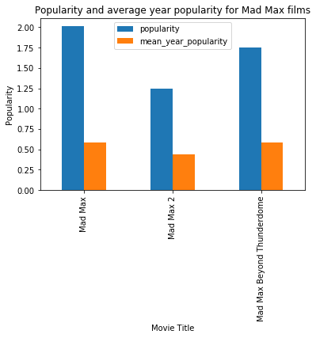

```python
madmax_plot = create_pop_plot(madmax_df, 'Mad Max')
```

This one is interesting. All three movies are well above the average popularity for their years. Mad Max 2 is the least popular which is surprising because it's the one I see on t.v. the most (but that's not a very scientific way to measure popularity). Also, at this point, I decided to stop being a dumb dumb and create a function that would populate a data frame for me, instead of doing a bunch of work for each movie series. Using this function will save a great deal of time, which will allow me to look at more series, giving more comprehensive data.

## Furious 7 (Fast and Furious series)

So I'll use my function to look for all movies with 'Furious' in the name to find the *Fast and the Furious* films.

```python
find_movies_by_title('Furious')
```

|  | popularity | original_title | cast | director | keywords | overview | runtime | genres | production_companies | release_date | vote_count | vote_average | release_year |
| --- | --- | --- | --- | --- | --- | --- | --- | --- | --- | --- | --- | --- | --- |
| 4 | 9.335014 | Furious 7 | Vin Diesel\|Paul Walker\|Jason Statham\|Michelle ... | James Wan | car race\|speed\|revenge\|suspense\|car | Deckard Shaw seeks revenge against Dominic Tor... | 137 | Action\|Crime\|Thriller | Universal Pictures\|Original Film\|Media Rights ... | 4/1/15 | 2947 | 7.3 | 2015 |
| 1539 | 0.580292 | Fast & Furious | Vin Diesel\|Paul Walker\|Jordana Brewster\|Michel... | Justin Lin | gambling\|brother sister relationship\|ex-lover\|... | When a crime brings them back to L.A., fugitiv... | 107 | Action\|Crime\|Drama\|Thriller | Universal Pictures\|Original Film\|One Race Prod... | 4/2/09 | 1661 | 6.4 | 2009 |
| 2753 | 0.414311 | The Fast and the Furious | Paul Walker\|Vin Diesel\|Michelle Rodriguez\|Jord... | Rob Cohen | street gang\|car race\|undercover\|auto-tuning\|lo... | Domenic Toretto is a Los Angeles street racer ... | 106 | Action\|Crime\|Thriller | Universal Pictures\|Original Film\|Ardustry Ente... | 6/22/01 | 2505 | 6.4 | 2001 |
| 2952 | 0.957704 | Kung Fu Panda: Secrets of the Furious Five | Jack Black\|Dustin Hoffman\|David Cross\|Randall ... | Raman Hui | martial arts\|kung fu\|animation\|anthropomorphic... | Ordered to teach a martial arts class of rambu... | 25 | Animation\|Comedy\|Family | DreamWorks Animation | 11/8/08 | 43 | 6.4 | 2008 |
| 5025 | 0.723225 | 2 Fast 2 Furious | Paul Walker\|Tyrese Gibson\|Eva Mendes\|Cole Haus... | John Singleton | miami\|car race\|sports car\|los angeles\|car | It's a major double-cross when former police o... | 107 | Action\|Crime\|Thriller | Mikona Productions GmbH & Co. KG\|Universal Pic... | 6/5/03 | 1275 | 6.1 | 2003 |
| 5226 | 0.027928 | Turbo Charged Prelude to 2 Fast 2 Furious | Paul Walker\|Minka Kelly\|Rodney Neil\|Peter Aylw... | Philip G. Atwell | NaN | Turbo-Charged Prelude is a 2003 short film, di... | 6 | Action | Original Film | 6/1/03 | 32 | 6.8 | 2003 |
| 5650 | 0.522347 | Fast & Furious 6 | Paul Walker\|Vin Diesel\|Dwayne Johnson\|Jordana ... | Justin Lin | car race\|sequel\|crime\|car\|automobile racing | Hobbs has Dominic and Brian reassemble their c... | 130 | Action\|Thriller\|Crime | Universal Pictures\|Original Film\|One Race Prod... | 5/6/13 | 4368 | 6.6 | 2013 |
| 6684 | 0.628730 | The Fast and the Furious: Tokyo Drift | Lucas Black\|Sung Kang\|Brian Tee\|Nathalie Kelle... | Justin Lin | car race\|car journey\|car mechanic\|auto\|car garage | In order to avoid a jail sentence, Sean Boswel... | 104 | Action\|Crime\|Drama\|Thriller | Universal Pictures | 6/3/06 | 1074 | 6.1 | 2006 |

This function is not perfect, however, and so I did a Google search to find any movies which don't have 'Furious' in the name. There are a few short films in the series, but I won't include those. Only the official, feature length movies.

```python
furious_list = ['The Fast and the Furious', '2 Fast 2 Furious', 'The Fast and the Furious: Tokyo Drift',
               'Fast & Furious', 'Fast Five', 'Fast & Furious 6']
furious_df = create_dataframe(furious_list)
furious_df
```

|  | mean_year_popularity | popularity | release_year | title | vote_average | vote_count |
| --- | --- | --- | --- | --- | --- | --- |
| 2753 | 0.702658 | 0.414311 | 2001 | The Fast and the Furious | 6.4 | 2505 |
| 5025 | 0.719083 | 0.723225 | 2003 | 2 Fast 2 Furious | 6.1 | 1275 |
| 6684 | 0.606371 | 0.628730 | 2006 | The Fast and the Furious: Tokyo Drift | 6.1 | 1074 |
| 1539 | 0.600178 | 0.580292 | 2009 | Fast & Furious | 6.4 | 1661 |
| 3619 | 0.675069 | 0.436803 | 2011 | Fast Five | 7.1 | 1591 |
| 5650 | 0.627627 | 0.522347 | 2013 | Fast & Furious 6 | 6.6 | 4368 |

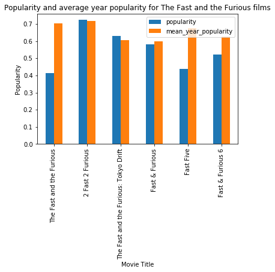

```python
furious_plot = create_pop_plot(furious_df, 'The Fast and the Furious')
```

As per usual, I'm not including the 2015 movie in the dataframe or graph. This graph is strange. The first movie in this series is about the worst in terms of popularity compared to the mean popularity for the year. The next three aren't too bad, and then the two after that are low again. There doesn't seem to be a clear pattern emerging about how a movie release within a year affects the popularity of past movies in the same series.

## Terminator Genisys (Terminator Series)

```python
find_movies_by_title('Terminator')
```

|  | popularity | original_title | cast | director | keywords | overview | runtime | genres | production_companies | release_date | vote_count | vote_average | release_year |
| --- | --- | --- | --- | --- | --- | --- | --- | --- | --- | --- | --- | --- | --- |
| 6 | 8.654359 | Terminator Genisys | Arnold Schwarzenegger\|Jason Clarke\|Emilia Clar... | Alan Taylor | saving the world\|artificial intelligence\|cybor... | The year is 2029. John Connor, leader of the r... | 125 | Science Fiction\|Action\|Thriller\|Adventure | Paramount Pictures\|Skydance Productions | 6/23/15 | 2598 | 5.8 | 2015 |
| 1392 | 3.789633 | Terminator Salvation | Christian Bale\|Sam Worthington\|Anton Yelchin\|M... | McG | saving the world\|artificial intelligence\|proph... | All grown up in post-apocalyptic 2018, John Co... | 115 | Drama\|Action\|Thriller\|Science Fiction | Columbia Pictures\|The Halcyon Company\|Wonderla... | 5/20/09 | 1670 | 5.8 | 2009 |
| 1767 | 0.235186 | The Terminators | Jeremy London\|A Martinez\|Paul Logan\|Lauren Wal... | Xavier S. Puslowski | cyborg | A small band of resistance fighters battle the... | 89 | Action\|Horror\|Science Fiction | NaN | 4/28/09 | 14 | 3.1 | 2009 |
| 2266 | 0.339125 | ExTerminators | Heather Graham\|Jennifer Coolidge\|Matthew Settl... | John Inwood | texas\|beautiful woman\|female protagonist\|anger... | Alex is a lonely accountant whose one act of r... | 92 | Comedy\|Drama | UTV Motion Pictures\|Michaelson Films | 1/5/10 | 17 | 5.2 | 2010 |
| 4959 | 2.686888 | Terminator 3: Rise of the Machines | Arnold Schwarzenegger\|Nick Stahl\|Claire Danes\|... | Jonathan Mostow | saving the world\|artificial intelligence\|man v... | It's been 10 years since John Connor saved Ear... | 109 | Action\|Thriller\|Science Fiction | Columbia Pictures\|Intermedia Films\|Warner Bros... | 7/2/03 | 1314 | 5.8 | 2003 |
| 7882 | 4.831966 | The Terminator | Arnold Schwarzenegger\|Michael Biehn\|Linda Hami... | James Cameron | saving the world\|artificial intelligence\|rebel... | In the post-apocalyptic future, reigning tyran... | 108 | Action\|Thriller\|Science Fiction | Orion Pictures\|Pacific Western\|Hemdale Film\|Ci... | 10/26/84 | 2692 | 7.1 | 1984 |
| 9317 | 3.584406 | Terminator 2: Judgment Day | Arnold Schwarzenegger\|Linda Hamilton\|Edward Fu... | James Cameron | cyborg\|shotgun\|post-apocalyptic\|dystopia\|stabb... | Nearly 10 years have passed since Sarah Connor... | 137 | Action\|Thriller\|Science Fiction | Lightstorm Entertainment\|Pacific Western\|Canal... | 7/1/91 | 2836 | 7.5 | 1991 |

```python
terminator_list = ['The Terminator', 'Terminator 2: Judgment Day', 'Terminator 3: Rise of the Machines',
                  'Terminator Salvation']
terminator_df = create_dataframe(terminator_list)
terminator_df
```

|  | mean_year_popularity | popularity | release_year | title | vote_average | vote_count |
| --- | --- | --- | --- | --- | --- | --- |
| 7882 | 0.590843 | 4.831966 | 1984 | The Terminator | 7.1 | 2692 |
| 9317 | 0.501090 | 3.584406 | 1991 | Terminator 2: Judgment Day | 7.5 | 2836 |
| 4959 | 0.719083 | 2.686888 | 2003 | Terminator 3: Rise of the Machines | 5.8 | 1314 |
| 1392 | 0.600178 | 3.789633 | 2009 | Terminator Salvation | 5.8 | 1670 |

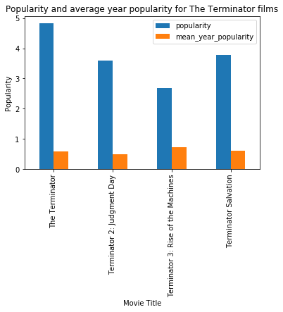

```python
terminator_plot = create_pop_plot(terminator_df, 'The Terminator')
```

All movies in the Terminator series are HIGH above the average for their years. I'll make a function that subtracts the mean mean_year_popularity from the mean popularity for each movie. When a movie series has a higher score, it means that the movies in that series genearally were more popular than the mean popularity for that year. If the score is negative then the movies in that series were, in general, less popular than the mean popularity for each year.

## Spectre (James Bond Series)

This will be interesting. I believe the James Bond series has more movies than all of the other series we've looked at. There have been several different actors to play James Bond over several different eras as well.

```python
find_movies_by_title('James Bond')
```

|  | popularity | original_title | cast | director | keywords | overview | runtime | genres | production_companies | release_date | vote_count | vote_average | release_year |
| --- | --- | --- | --- | --- | --- | --- | --- | --- | --- | --- | --- | --- | --- |

```python
find_movies_by_title('Bond')
```

|  | popularity | original_title | cast | director | keywords | overview | runtime | genres | production_companies | release_date | vote_count | vote_average | release_year |
| --- | --- | --- | --- | --- | --- | --- | --- | --- | --- | --- | --- | --- | --- |
| 2403 | 0.06762 | Yu-Gi-Oh! 3D: Bonds Beyond Time | Greg Abbey\|Dan Green\|Matthew Charles\|Sean Sche... | NaN | NaN | After falling through a time-slip, Yusei Fudo ... | 60 | Animation\|Fantasy | NaN | 1/23/10 | 10 | 6.0 | 2010 |

Well my find_movies_by_title function is going to be pretty much useless for this series apparently. To Google I go!'

```python
find_movies_by_title("From Russia With Love")
```

|  | popularity | original_title | cast | director | keywords | overview | runtime | genres | production_companies | release_date | vote_count | vote_average | release_year |
| --- | --- | --- | --- | --- | --- | --- | --- | --- | --- | --- | --- | --- | --- |
| 10438 | 2.508235 | From Russia With Love | Sean Connery\|Daniela Bianchi\|Lotte Lenya\|Rober... | Terence Young | venice\|london\|terror\|england\|assassination | Agent 007 is back in the second installment of... | 115 | Action\|Thriller\|Adventure | Eon Productions\|Metro-Goldwyn-Mayer (MGM)\|Danjaq | 10/11/63 | 458 | 6.7 | 1963 |

I Googled all the movies in the James Bond series, then looked up their information individually.

```python
jamesbond_list = [
'Dr. No',
'From Russia With Love',
'Goldfinger',
'Thunderball',
'You Only Live Twice',
"On Her Majesty's Secret Service",
'Diamonds Are Forever',
'Live and Let Die',
'The Man with the Golden Gun',
'The Spy Who Loved Me',
'Moonraker',
'For Your Eyes Only',
'Octopussy',
'Never Say Never Again',
'A View to a Kill',
'The Living Daylights',
'Licence to Kill',
'GoldenEye',
'Tomorrow Never Dies',
'The World Is Not Enough',
'Die Another Day',
'Casino Royale',
'Quantum of Solace',
'Skyfall']

# If anyone is wondering, according to Google, the first Casino Royale is not an official
# James Bond movie.
jamesbond_df = create_dataframe(jamesbond_list)
jamesbond_df
```

|  | mean_year_popularity | popularity | release_year | title | vote_average | vote_count |
| --- | --- | --- | --- | --- | --- | --- |
| 9849 | 0.454783 | 3.170651 | 1962 | Dr. No | 6.7 | 560 |
| 10438 | 0.502706 | 2.508235 | 1963 | From Russia With Love | 6.7 | 458 |
| 9881 | 0.412428 | 3.153791 | 1964 | Goldfinger | 7.0 | 602 |
| 10689 | 0.342587 | 1.910465 | 1965 | Thunderball | 6.3 | 331 |
| 10401 | 0.471154 | 1.554808 | 1967 | You Only Live Twice | 6.2 | 301 |
| 10724 | 0.422778 | 1.778746 | 1969 | On Her Majesty's Secret Service | 6.4 | 258 |
| 9925 | 0.448112 | 1.755117 | 1971 | Diamonds Are Forever | 6.2 | 331 |
| 10595 | 0.494462 | 1.549139 | 1973 | Live and Let Die | 6.1 | 293 |
| 9760 | 0.447829 | 1.619555 | 1974 | The Man with the Golden Gun | 6.1 | 283 |
| 1330 | 0.626387 | 2.379469 | 1977 | The Spy Who Loved Me | 6.2 | 279 |
| 7829 | 0.589312 | 1.691143 | 1979 | Moonraker | 5.7 | 299 |
| 8377 | 0.442413 | 1.771093 | 1981 | For Your Eyes Only | 6.0 | 268 |
| 7990 | 0.541445 | 1.575742 | 1983 | Octopussy | 5.9 | 289 |
| 7989 | 0.541445 | 1.774018 | 1983 | Never Say Never Again | 5.8 | 183 |
| 6085 | 0.584058 | 1.623978 | 1985 | A View to a Kill | 5.8 | 272 |
| 9598 | 0.504637 | 1.511663 | 1987 | The Living Daylights | 6.0 | 238 |
| 9186 | 0.563658 | 2.176623 | 1989 | Licence to Kill | 5.6 | 332 |
| 8071 | 0.710722 | 2.440099 | 1995 | GoldenEye | 6.4 | 741 |
| 5238 | 0.712003 | 2.391809 | 1997 | Tomorrow Never Dies | 5.9 | 565 |
| 2416 | 0.645799 | 2.129874 | 1999 | The World Is Not Enough | 6.0 | 509 |
| 3926 | 0.701454 | 1.846196 | 2002 | Die Another Day | 5.8 | 692 |
| 6557 | 0.606371 | 3.789580 | 2006 | Casino Royale | 7.1 | 2738 |
| 2881 | 0.584817 | 3.086676 | 2008 | Quantum of Solace | 6.0 | 2149 |
| 4365 | 0.607197 | 5.603587 | 2012 | Skyfall | 6.8 | 6137 |

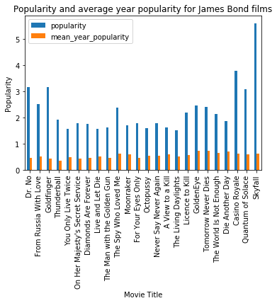

```python
jamesbond_plot = create_pop_plot(jamesbond_df, 'James Bond')
```

So this series has been very successful. Over the span of several decades with several different lead actors, not a single film is even close to its mean year popularity. Very impressive.

Side note on the James Bond graph. In my above remark, I did not realize how I was being duped by the numbers. Yes, it may look like the popularities are stratospherically higher than the mean year popularities, but in reality they're not.

## Movie Rankings

Now that we have examined all the different movie series and their data, lets see which series have been the most successful -or are at least the most popular. To do this I will be using my popularity_score function on each of the dataframes.

I'll explain how these scores work so they are more meaningful. The score is calculated by taking the mean of the popularities for the movies in a series and subtracting the mean for the mean year popularities for each movie from it. For example, say there are three movies in a series and their popularities are: 2,4,6. The mean year popularities are 1,2,3. The mean for the movie popularities = (2+4+6)/3 = 4. The mean for the mean year popularities = (1+2+3)/3 = 2. Subtract 2 from 4 and you are left with 2, so 2 is your score. The higher score, the better.

```python
starwars_pop = popularity_score(starwars_df)
jurassicpark_pop = popularity_score(jurassicpark_df)
madmax_pop = popularity_score(madmax_df)
terminator_pop = popularity_score(terminator_df)
jamesbond_pop = popularity_score(jamesbond_df)
furious_pop = popularity_score(furious_df)
pop_scores_2015 = pd.Series([starwars_pop, jurassicpark_pop, madmax_pop, terminator_pop, jamesbond_pop, furious_pop])
recent_series_rankings = "{} pop score is {}, " * 6
recent_series_rankings.format('Starwars', starwars_pop, 'Jurassic Park', jurassicpark_pop, \
                              'Mad Max', madmax_pop,'Terminator', terminator_pop, 'Fast and Furious', \
                              furious_pop, 'James Bond', jamesbond_pop)
```

```
'Starwars pop score is 4.804617917287008, Jurassic Park pop score is 0.20693070155751847, Mad Max pop score is 1.1303496608769446, Terminator pop score is 3.120424691941778, Fast and Furious pop score is -0.10421304619282701, James Bond pop score is 1.7430624879817151, '
```

```python
pop_scores_2015.describe()
```

```
count    6.000000
mean     1.816862
std      1.864678
min     -0.104213
25%      0.437785
50%      1.436706
75%      2.776084
max      4.804618
dtype: float64
```

Looking at the popularity scores of each of these movie series, they all (except for one) are positive. This means that, on average, each movie in each series is more popular than the average popularity per year. And even the *Fast and the Furious* film series is only barely negative. However, these numbers mean very little if we have nothing to compare them to. For all we know, most movie series could have a positive score that reflect the pattern seen here. Maybe the only reason they keep continuing a series is because each film in it tends to be more popular than average (I don't believe that's the reason but I think it's a good though process to keep me accountable to accuracy). The only way to find out is to examine some movie series that havent had a recent release. Shall we?

## Looking further

For this section, I will do what I did for all the previous film series, except now I will only examine series that have not had a film released in recent years. To detrmine which series to examine, I will look at the max popularities for each year to see where the movies stop spiking in popularity.

```python
movies_df.groupby('release_year')['popularity'].max()
```

```
release_year
1960     2.610362
1961     2.631987
1962     3.170651
1963     2.508235
1964     3.153791
1965     1.910465
1966     1.227582
1967     2.550704
1968     3.309196
1969     1.778746
1970     1.936962
1971     3.072555
1972     5.738034
1973     2.272486
```

[output cut: 43 more lines]

## Examining 2013 movies

```python
movies_df[(movies_df['release_year'] == 2013)]
```

|  | popularity | original_title | cast | director | keywords | overview | runtime | genres | production_companies | release_date | vote_count | vote_average | release_year |
| --- | --- | --- | --- | --- | --- | --- | --- | --- | --- | --- | --- | --- | --- |
| 5422 | 6.112766 | Frozen | Kristen Bell\|Idina Menzel\|Jonathan Groff\|Josh ... | Chris Buck\|Jennifer Lee | queen\|musical\|princess\|betrayal\|snowman | Young princess Anna of Arendelle dreams about ... | 102 | Animation\|Adventure\|Family | Walt Disney Pictures\|Walt Disney Animation Stu... | 11/27/13 | 3369 | 7.5 | 2013 |
| 5423 | 5.242753 | Gravity | Sandra Bullock\|George Clooney\|Ed Harris\|Orto I... | Alfonso Cuarón | space mission\|space\|astronaut\|trapped in space\|3d | Dr. Ryan Stone (Sandra Bullock), a brilliant m... | 91 | Science Fiction\|Thriller\|Drama | Warner Bros.\|Heyday Films\|Esperanto Filmoj | 9/27/13 | 3775 | 7.4 | 2013 |
| 5424 | 5.111900 | Thor: The Dark World | Chris Hemsworth\|Natalie Portman\|Tom Hiddleston... | Alan Taylor | marvel comic\|comic\|superhero\|hostile takeover\|... | Thor fights to restore order across the cosmos... | 112 | Action\|Adventure\|Fantasy | Marvel Studios | 10/29/13 | 3025 | 6.8 | 2013 |
| 5425 | 4.946136 | Iron Man 3 | Robert Downey Jr.\|Gwyneth Paltrow\|Guy Pearce\|D... | Shane Black | terrorist\|war on terror\|tennessee\|malibu\|marve... | When Tony Stark's world is torn apart by a for... | 130 | Action\|Adventure\|Science Fiction | Marvel Studios | 4/18/13 | 6882 | 6.9 | 2013 |
| 5426 | 4.942928 | Now You See Me | Jesse Eisenberg\|Mark Ruffalo\|Woody Harrelson\|M... | Louis Leterrier | paris\|bank\|secret\|fbi\|vault | An FBI agent and an Interpol detective track a... | 115 | Thriller\|Crime | Summit Entertainment\|K/O Paper Products\|SOIXAN... | 5/29/13 | 3453 | 7.3 | 2013 |
| 5427 | 4.921275 | The Hunger Games: Catching Fire | Jennifer Lawrence\|Josh Hutcherson\|Liam Hemswor... | Francis Lawrence | based on novel\|mentor\|secret\|factory\|television | Katniss Everdeen has returned home safe after ... | 146 | Science Fiction\|Thriller\|Action\|Adventure | Lionsgate\|Color Force | 11/15/13 | 4269 | 7.4 | 2013 |
| 5428 | 4.877927 | The Wolf of Wall Street | Leonardo DiCaprio\|Jonah Hill\|Margot Robbie\|Kyl... | Martin Scorsese | corruption\|sex\|sexuality\|bank\|humor | A New York stockbroker refuses to cooperate in... | 180 | Crime\|Drama\|Comedy | Paramount Pictures\|Appian Way\|EMJAG Production... | 12/25/13 | 4027 | 7.9 | 2013 |
| 5429 | 4.705208 | Pacific Rim | Idris Elba\|Charlie Hunnam\|Charlie Day\|Ron Perl... | Guillermo del Toro | dystopia\|giant robot\|giant monster\|apocalypse\|... | When legions of monstrous creatures, known as ... | 131 | Action\|Science Fiction\|Adventure | Legendary Pictures\|Warner Bros.\|Disney Double ... | 7/11/13 | 3590 | 6.7 | 2013 |
| 5430 | 4.405923 | Oblivion | Tom Cruise\|Morgan Freeman\|Olga Kurylenko\|Andre... | Joseph Kosinski | spacecraft\|dystopia\|space\|drone\|imax | Jack Harper (Tom Cruise) is one of the last fe... | 126 | Action\|Science Fiction\|Adventure\|Mystery | Universal Pictures\|Chernin Entertainment\|Relat... | 4/10/13 | 3729 | 6.3 | 2013 |
| 5431 | 4.310786 | The Hobbit: The Desolation of Smaug | Martin Freeman\|Ian McKellen\|Richard Armitage\|K... | Peter Jackson | elves\|dwarves\|orcs\|middle-earth (tolkien)\|hobbits | The Dwarves, Bilbo and Gandalf have successful... | 161 | Adventure\|Fantasy | WingNut Films\|New Line Cinema\|Metro-Goldwyn-Ma... | 12/11/13 | 2952 | 7.6 | 2013 |
| 5432 | 3.972460 | Man of Steel | Henry Cavill\|Amy Adams\|Michael Shannon\|Diane L... | Zack Snyder | saving the world\|dc comics\|superhero\|based on ... | A young boy learns that he has extraordinary p... | 143 | Action\|Adventure\|Fantasy\|Science Fiction | Legendary Pictures\|Warner Bros.\|DC Entertainme... | 6/12/13 | 4729 | 6.5 | 2013 |
| 5433 | 3.951582 | Her | Joaquin Phoenix\|Scarlett Johansson\|Rooney Mara... | Spike Jonze | artificial intelligence\|computer\|loneliness | In the not so distant future, Theodore, a lone... | 126 | Romance\|Science Fiction\|Drama | Annapurna Pictures | 12/18/13 | 2422 | 7.8 | 2013 |
| 5434 | 3.928789 | Despicable Me 2 | Steve Carell\|Kristen Wiig\|Benjamin Bratt\|Miran... | Pierre Coffin\|Chris Renaud | secret agent\|bakery\|falling in love\|father dau... | Gru is recruited by the Anti-Villain League to... | 98 | Animation\|Comedy\|Family | Universal Pictures\|Illumination Entertainment | 6/25/13 | 3436 | 7.0 | 2013 |
| 5435 | 3.877342 | Star Trek Into Darkness | Chris Pine\|Zachary Quinto\|Zoe Saldana\|Karl Urb... | J.J. Abrams | spacecraft\|friendship\|sequel\|futuristic\|space | When the crew of the Enterprise is called back... | 132 | Action\|Adventure\|Science Fiction | Paramount Pictures\|Skydance Productions\|Bad Ro... | 5/5/13 | 3363 | 7.4 | 2013 |
| 5436 | 3.625529 | 12 Years a Slave | Chiwetel Ejiofor\|Michael Fassbender\|Lupita Nyo... | Steve McQueen | whip\|slavery\|plantation\|night shift\|kidnapping | In the pre-Civil War United States, Solomon No... | 134 | Drama\|History | Plan B Entertainment\|Regency Enterprises\|River... | 10/18/13 | 2241 | 7.9 | 2013 |
| 5437 | 3.518275 | Riddick | Vin Diesel\|Karl Urban\|Katee Sackhoff\|Jordi Mol... | David Twohy | dystopia\|revenge\|alien\|planet\|imax | Betrayed by his own kind and left for dead on ... | 119 | Science Fiction\|Action\|Thriller | One Race Productions\|Radar Pictures\|Riddick Ca... | 9/2/13 | 1530 | 6.2 | 2013 |
| 5438 | 3.472358 | The Conjuring | Patrick Wilson\|Vera Farmiga\|Ron Livingston\|Lil... | James Wan | sister sister relationship\|exorcism\|rhode isla... | Paranormal investigators Ed and Lorraine Warre... | 112 | Horror\|Thriller | New Line Cinema\|The Safran Company\|Evergreen M... | 7/18/13 | 1910 | 7.4 | 2013 |
| 5439 | 3.200427 | The Great Gatsby | Leonardo DiCaprio\|Tobey Maguire\|Carey Mulligan... | Baz Luhrmann | based on novel\|infidelity\|obsession\|hope\|3d | An adaptation of F. Scott Fitzgerald's Long Is... | 143 | Drama\|Romance | Village Roadshow Pictures\|Bazmark Films\|Warner... | 5/10/13 | 2403 | 7.2 | 2013 |
| 5440 | 3.006256 | Nymphomaniac: Vol. II | Charlotte Gainsbourg\|Stellan Skarsgård\|Shia L... | Lars von Trier | sex\|bondage\|whip\|nudity\|masochism | The continuation of Joe's sexually dictated li... | 123 | Drama\|Mystery | Zentropa Entertainments | 12/25/13 | 465 | 6.6 | 2013 |
| 5441 | 2.951594 | Elysium | Matt Damon\|Jodie Foster\|Sharlto Copley\|Alice B... | Neill Blomkamp | dystopia\|space station\|class conflict | In the year 2159, two classes of people exist:... | 109 | Science Fiction\|Action\|Drama\|Thriller | TriStar Pictures\|Media Rights Capital\|Sony Pic... | 8/7/13 | 2366 | 6.5 | 2013 |
| 5442 | 2.815499 | A Good Day to Die Hard | Bruce Willis\|Jai Courtney\|Sebastian Koch\|Mary ... | John Moore | bomb\|cia\|russia\|escape\|courthouse | Iconoclastic, take-no-prisoners cop John McCla... | 98 | Action\|Thriller | Ingenious Media\|Twentieth Century Fox Film Cor... | 2/6/13 | 3003 | 5.2 | 2013 |
| 5443 | 2.811403 | The Purge | Lena Headey\|Ethan Hawke\|Max Burkholder\|Adelaid... | James DeMonaco | dystopia\|barricade\|home invasion\|constitutiona... | Given the country's overcrowded prisons, the U... | 86 | Science Fiction\|Horror\|Thriller | Universal Pictures\|Why Not Productions\|Platinu... | 5/31/13 | 1522 | 5.8 | 2013 |
| 5444 | 2.643496 | Monsters University | Billy Crystal\|John Goodman\|Steve Buscemi\|Helen... | Dan Scanlon | monster\|dormitory\|games\|prequel\|animation | A look at the relationship between Mike and Su... | 104 | Animation\|Family | Walt Disney Pictures\|Pixar Animation Studios | 6/20/13 | 2251 | 7.0 | 2013 |
| 5445 | 2.604638 | World War Z | Brad Pitt\|Mireille Enos\|Abigail Hargrove\|Sterl... | Marc Forster | dystopia\|apocalypse\|zombies\|nuclear weapons\|fl... | Life for former United Nations investigator Ge... | 116 | Action\|Drama\|Horror\|Science Fiction\|Thriller | Paramount Pictures\|GK Films\|Skydance Productio... | 6/20/13 | 3822 | 6.7 | 2013 |
| 5446 | 2.497001 | The Secret Life of Walter Mitty | Ben Stiller\|Kristen Wiig\|Patton Oswalt\|Shirley... | Ben Stiller | photographer\|magazine\|iceland\|daydream\|photograph | A timid magazine photo manager who lives life ... | 114 | Adventure\|Comedy\|Drama\|Fantasy | New Line Cinema\|Ingenious Media\|Twentieth Cent... | 12/18/13 | 2221 | 7.0 | 2013 |
| 5447 | 2.476989 | Ender's Game | Asa Butterfield\|Harrison Ford\|Hailee Steinfeld... | Gavin Hood | based on novel\|intolerance\|chosen one\|child pr... | Based on the classic novel by Orson Scott Card... | 114 | Science Fiction\|Action\|Adventure | Summit Entertainment\|Chartoff Productions\|Odd ... | 10/23/13 | 1608 | 6.6 | 2013 |
| 5448 | 2.443357 | We're the Millers | Jason Sudeikis\|Jennifer Aniston\|Will Poulter\|E... | Rawson Marshall Thurber | mexico\|police\|gang\|drug smuggling\|drug | A veteran pot dealer creates a fake family as ... | 110 | Comedy\|Crime | New Line Cinema\|BenderSpink\|Heyday Films\|Newma... | 8/7/13 | 1960 | 6.9 | 2013 |
| 5449 | 2.196946 | 2 Guns | Denzel Washington\|Mark Wahlberg\|Paula Patton\|B... | Baltasar Kormákur | undercover\|undercover agent\|based on comic boo... | A DEA agent and an undercover Naval Intelligen... | 109 | Action\|Crime\|Drama\|Comedy\|Thriller | Universal Studios\|Marc Platt Productions\|Emmet... | 8/2/13 | 1185 | 6.6 | 2013 |
| 5450 | 2.195536 | About Time | Rachel McAdams\|Bill Nighy\|Domhnall Gleeson\|Tom... | Richard Curtis | london\|father-son relationship\|time travel | The night after another unsatisfactory New Yea... | 123 | Comedy\|Drama\|Science Fiction | Working Title Films\|Translux | 8/16/13 | 1329 | 7.7 | 2013 |
| 5451 | 2.119986 | Rush | Daniel Brühl\|Chris Hemsworth\|Olivia Wilde\|Ale... | Ron Howard | world champion\|sport\|racing car\|formula 1\|auto... | A biographical drama centered on the rivalry b... | 123 | Drama\|Action | Revolution Films\|Working Title Films\|Cross Cre... | 9/2/13 | 1472 | 7.7 | 2013 |
| ... | ... | ... | ... | ... | ... | ... | ... | ... | ... | ... | ... | ... | ... |
| 6051 | 0.112041 | Aziz Ansari: Buried Alive | Aziz Ansari | Will Lovelace\|Dylan Southern | stand-up\|stand up comedy | Standup comedian Aziz Ansari ("Parks and Recre... | 79 | Comedy | NaN | 11/1/13 | 40 | 7.5 | 2013 |
| 6052 | 0.021150 | Känn ingen sorg | Adam Lundgren\|Josefin Neldén\|Disa Östrand\|Jo... | Måns Mårlind\|Björn Stein | NaN | Pål dreams about becoming successful with his... | 119 | Drama\|Music\|Romance | NaN | 7/19/13 | 11 | 6.2 | 2013 |
| 6053 | 0.146962 | The Dirties | Matt Johnson\|Owen Williams\|Krista Madison\|Bran... | Matt Johnson | NaN | Two best friends are filming a comedy about ge... | 83 | Drama | XYZ Films | 10/4/13 | 15 | 6.2 | 2013 |
| 6054 | 0.019930 | Sacro GRA | Roberto Giuliani\|Franceso De Santis | Gianfranco Rosi | society\|environment\|everyday life | After the India of Varanasi’s boatmen, the A... | 93 | Documentary | Rai Cinema\|La Femme Endormie | 9/19/13 | 10 | 4.6 | 2013 |
| 6055 | 0.019755 | Somm | NaN | Jason Wise | competition\|exam\|wine\|documentary\|culinary arts | Somm takes the viewer on a humorous, emotional... | 93 | Documentary | NaN | 6/21/13 | 20 | 7.0 | 2013 |
| 6056 | 0.080410 | Yip Man: The Final Fight | Anthony Wong\|Anita Yuen\|Gillian Chung\|Jordan C... | Herman Yau | biography | In postwar Hong Kong, legendary Wing Chun gran... | 100 | Action\|Drama | Emperor Motion Pictures | 3/22/13 | 110 | 6.0 | 2013 |
| 6057 | 0.016326 | 100% Cachemire | Valérie Lemercier\|Gilles Lellouche\|Marina FoÃ... | Valérie Lemercier | woman director | The story of Aleksandra and Cyrille, a promine... | 98 | Comedy | Rectangle Productions.\|Scope Pictures | 12/11/13 | 33 | 5.0 | 2013 |
| 6058 | 0.015951 | Escape from Tomorrow | Roy Abramsohn\|Elena Schuber\|Katelynn Rodriguez... | Randy Moore | NaN | In a world of fake castles and anthropomorphic... | 90 | Horror\|Fantasy | Mankurt Media | 10/11/13 | 50 | 4.1 | 2013 |
| 6059 | 0.015722 | The Stone Roses: Made of Stone | Ian Brown\|Gary 'Mani' Mounfield\|John Squire\|Al... | Shane Meadows | NaN | A documentary about the English alternative ro... | 96 | Documentary | NaN | 5/28/13 | 10 | 6.0 | 2013 |
| 6060 | 0.007821 | TINY: A Story About Living Small | Daryl Gibson\|Christopher Smith\|Paul H. Smith\|W... | Merete Mueller\|Christopher Smith | woman director | What is home? And how do we find it? TINY foll... | 62 | Documentary | Speak Thunder Films | 3/9/13 | 10 | 6.7 | 2013 |
| 6061 | 0.015247 | The Starving Games | Brant Daugherty\|Maiara Walsh\|Lauren Bowles\|Cod... | Jason Friedberg\|Aaron Seltzer | parody\|toilet humor | A spoof movie that references The Hunger Games... | 83 | Comedy | Louisiana Production Consultants | 11/7/13 | 151 | 4.1 | 2013 |
| 6062 | 0.013510 | I Know That Voice | Kevin Conroy\|Jim Cummings\|Rachael MacFarlane\|J... | Lawrence Shapiro | voice over\|voice acting | A documentary about voice-over actors. | 90 | Documentary | Dundee Entertainment\|Record Farm Industries\|Ci... | 11/6/13 | 31 | 6.9 | 2013 |
| 6063 | 0.011298 | How to Be a Man | Gavin McInnes\|Liam Aiken\|Paulo Costanzo\|Brian ... | Chadd Harbold | NaN | When former comedian Mark McCarthy is faced wi... | 90 | Comedy | NaN | 8/10/13 | 15 | 6.6 | 2013 |
| 6064 | 0.017565 | ABE | Sam Hoare\|Claire Huskisson\|Emily Baxter | Rob McLellan | NaN | A short film about a robot programmed for love... | 8 | Science Fiction\|Thriller | NaN | 4/16/13 | 17 | 6.1 | 2013 |
| 6065 | 0.010335 | Ð¡Ñ‚Ð°Ð»Ð¸Ð½Ð³Ñ€Ð°Ð´ | Thomas Kretschmann\|Yanina Studilina\|Philippe R... | Fyodor Bondarchuk | world war ii\|soviet troops\|adolf hitler\|stalin... | Drama set in 1942, during one of the most impo... | 131 | War\|Action | Art Pictures Studio | 10/9/13 | 64 | 5.5 | 2013 |
| 6066 | 0.010213 | A Viking Saga: The Darkest Day | Elen Rhys\|Mark Lewis Jones\|Gary Mavers\|Marc Pi... | Chris Crow | monk\|viking | Cast into a violent and bloody world of murder... | 82 | Adventure\|Action\|Thriller | Lions Gate Films | 6/10/13 | 16 | 3.6 | 2013 |
| 6067 | 0.008540 | Beyonce: Life Is But A Dream | Beyoncé Knowles\|Jay-Z\|Tina Knowles | Ed Burke\|Beyoncé Knowles | woman director | Beyonce’s Life Is But A Dream documentary fi... | 88 | Documentary | HBO\|Parkwood Entertainment | 3/5/13 | 12 | 7.8 | 2013 |
| 6068 | 0.035367 | A Very Merry Mix-Up | Alicia Witt\|Mark Wiebe\|Scott Gibson\|Susan Hoga... | Jonathan Wright | mistake in person\|lost baggage\|destiny\|in-laws... | Shop owner Alice Chapman is nervous to meet he... | 90 | TV Movie\|Romance\|Comedy\|Drama | Chesler/Perlmutter Productions | 11/10/13 | 15 | 5.7 | 2013 |
| 6069 | 0.008078 | Dark Circles | Johnathon Schaech\|Andrea Frankle\|Philippe Bren... | Paul Soter | NaN | When new parents Alex and Penny retreat from t... | 87 | Horror | After Dark Films | 1/1/13 | 15 | 4.4 | 2013 |
| 6070 | 0.005853 | Master of the Universe | Rainer Voss\|Angela Merkel | Marc Bauder | germany\|capitalism\|banker\|banking\|economics | He was one of Germany's leading investment exp... | 88 | Documentary | Arte Deutschland TV GmbH\|SWR | 11/7/13 | 11 | 6.6 | 2013 |
| 6071 | 0.004323 | Portal: Survive! | Monique Blanchard\|Bradley Mixon | Connor McGuire\|Colin McGuire | portal\|aperture | A short, live action fan film by Collin and Co... | 7 | Action\|Science Fiction | NaN | 10/8/13 | 11 | 7.5 | 2013 |
| 6072 | 0.040099 | Minha Mãe é uma Peça | Paulo Gustavo\|Mariana Xavier\|Rodrigo Pandolfo\|... | André Pellenz | brazilian\|comedy | After another spat with her kids, Dona Hermín... | 85 | Comedy | NaN | 6/21/13 | 49 | 7.4 | 2013 |
| 6073 | 0.003611 | Bronies: The Extremely Unexpected Adult Fans o... | Tara Strong\|John de Lancie\|Cathy Weseluck\|Pete... | Laurent Malaquais | pop culture\|pony\|friendship\|fan culture\|animation | A film profiling the unusual cross-demographic... | 88 | Documentary | Big Focus Television | 1/19/13 | 13 | 5.8 | 2013 |
| 6074 | 0.002838 | Russell Peters: Notorious | Russell Peters | David Higby | stand up comedy | Now watch comedy rockstar, Russell Peters up-c... | 71 | Comedy | NaN | 10/15/13 | 12 | 7.2 | 2013 |
| 6075 | 0.002719 | Embrace of the Vampire | Sharon Hinnendael\|Kaniehtiio Horn\|Chelsey Reis... | Carl Bessai | NaN | Sharon Hinnendael stars as Charlotte, a timid ... | 91 | Horror | Bloodline Pictures | 10/15/13 | 19 | 4.9 | 2013 |
| 6076 | 0.006115 | Mistaken for Strangers | Matt Berninger\|Tom Berninger\|Aaron Dessner\|Bry... | Tom Berninger | NaN | Mistaken for Strangers follows The National on... | 75 | Documentary\|Music | Final Frame\|C5 | 9/19/13 | 14 | 7.4 | 2013 |
| 6077 | 0.002648 | Atlantic Rim | Graham Greene\|David Chokachi\|Jackie Moore\|Nico... | Jared Cohn | navy\|underwater threat\|robot suits\|giant monsters | When monsters suddenly appear from the bottom ... | 85 | Action\|Science Fiction | The Asylum\|Tiki Terrors | 7/9/13 | 21 | 2.2 | 2013 |
| 6078 | 0.002647 | Trophy Kids | NaN | Chris Bell | NaN | From the director of Bigger Stronger Faster co... | 107 | Documentary | NaN | 12/4/13 | 10 | 7.8 | 2013 |
| 6079 | 0.002165 | The Sound of Music Live! | Laura Benanti\|Stephen Moyer\|Carrie Underwood\|C... | Beth McCarthy-Miller\|Rob Ashford | musical\|live\|woman director | This new version of "The Sound of Music" will ... | 180 | Drama\|Family | NaN | 12/5/13 | 11 | 5.6 | 2013 |
| 6080 | 0.000620 | G.B.F. | Michael J. Willett\|Paul Iacono\|Sasha Pieterse\|... | Darren Stein | gay\|gay kiss\|coming out\|high school\|friends | The bitter fight for supremacy between the thr... | 92 | Comedy | School Pictures\|Parting Shots Media\|Logolite E... | 10/20/13 | 82 | 6.1 | 2013 |

659 rows × 13 columns

So our contestants are: *Iron Man 3 (Iron Man), The Hobbit: The Desolation of Smaug (Lord of the Rings), Star Trek Into Darknes (Star Trek), Riddick (The Chronicles of Riddick),* and *A Good Day to Die Hard (Die Hard)*.

I'm excluding *Frozen* and *Thor: The Dark World* because, while both are part of a larger universe of movies, neither of them are in sufficiently large series within their respective universes (*Frozen* is not part of a series at all and *Thor: The Dark World* is the second installment in its series).

## Iron Man 3 (Iron Man)

```python
ironman_list = ['Iron Man', 'Iron Man 2', 'Iron Man 3']
ironman_df = create_dataframe(ironman_list)
ironman_df
```

|  | mean_year_popularity | popularity | release_year | title | vote_average | vote_count |
| --- | --- | --- | --- | --- | --- | --- |
| 2877 | 0.584817 | 4.977955 | 2008 | Iron Man | 7.3 | 6220 |
| 1920 | 0.644958 | 5.704860 | 2010 | Iron Man 2 | 6.6 | 4920 |
| 5425 | 0.627627 | 4.946136 | 2013 | Iron Man 3 | 6.9 | 6882 |

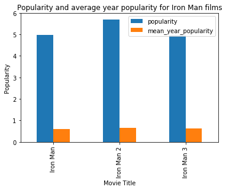

```python
ironman_plot = create_pop_plot(ironman_df, 'Iron Man')
```

## The Hobbit: The Desolation of Smaug (The Lord of the Rings)

```python
find_movies_by_title('The Lord of the Rings')
```

|  | popularity | original_title | cast | director | keywords | overview | runtime | genres | production_companies | release_date | vote_count | vote_average | release_year |
| --- | --- | --- | --- | --- | --- | --- | --- | --- | --- | --- | --- | --- | --- |
| 2633 | 8.575419 | The Lord of the Rings: The Fellowship of the Ring | Elijah Wood\|Ian McKellen\|Viggo Mortensen\|Liv T... | Peter Jackson | elves\|dwarves\|orcs\|middle-earth (tolkien)\|hobbits | Young hobbit Frodo Baggins, after inheriting a... | 178 | Adventure\|Fantasy\|Action | WingNut Films\|New Line Cinema\|The Saul Zaentz ... | 12/18/01 | 6079 | 7.8 | 2001 |
| 3911 | 8.095275 | The Lord of the Rings: The Two Towers | Elijah Wood\|Ian McKellen\|Viggo Mortensen\|Liv T... | Peter Jackson | elves\|orcs\|middle-earth (tolkien)\|hobbits\|base... | Frodo and Sam are trekking to Mordor to destro... | 179 | Adventure\|Fantasy\|Action | WingNut Films\|New Line Cinema\|The Saul Zaentz ... | 12/18/02 | 5114 | 7.8 | 2002 |
| 4949 | 7.122455 | The Lord of the Rings: The Return of the King | Elijah Wood\|Ian McKellen\|Viggo Mortensen\|Liv T... | Peter Jackson | elves\|orcs\|middle-earth (tolkien)\|based on nov... | Aragorn is revealed as the heir to the ancient... | 201 | Adventure\|Fantasy\|Action | WingNut Films\|New Line Cinema | 12/1/03 | 5636 | 7.9 | 2003 |
| 10771 | 0.496029 | The Lord of the Rings | Christopher Guard\|William Squire\|Michael Schol... | Ralph Bakshi | elves\|dwarves\|hobbits\|mission | The Fellowship of the Ring embark on a journey... | 132 | Drama\|Animation\|Adventure | Fantasy Films | 11/15/78 | 91 | 6.0 | 1978 |

```python
find_movies_by_title('The Hobbit')
```

|  | popularity | original_title | cast | director | keywords | overview | runtime | genres | production_companies | release_date | vote_count | vote_average | release_year |
| --- | --- | --- | --- | --- | --- | --- | --- | --- | --- | --- | --- | --- | --- |
| 634 | 10.174599 | The Hobbit: The Battle of the Five Armies | Martin Freeman\|Ian McKellen\|Richard Armitage\|K... | Peter Jackson | corruption\|elves\|dwarves\|orcs\|middle-earth (to... | Immediately after the events of The Desolation... | 144 | Adventure\|Fantasy | WingNut Films\|New Line Cinema\|3Foot7\|Metro-Gol... | 12/10/14 | 3110 | 7.1 | 2014 |
| 1357 | 0.312358 | The Hobbit | Orson Bean\|Richard Boone\|Hans Conried\|John Hus... | Jules Bass\|Arthur Rankin, Jr. | elves\|dwarves\|orcs\|rivendell\|robbery | Bilbo Baggins the Hobbit was just minding his ... | 77 | Adventure\|Animation\|Family | Rankin/Bass Productions | 11/27/77 | 46 | 5.8 | 1977 |
| 4367 | 4.218933 | The Hobbit: An Unexpected Journey | Ian McKellen\|Martin Freeman\|Richard Armitage\|A... | Peter Jackson | riddle\|elves\|dwarves\|orcs\|middle-earth (tolkien) | Bilbo Baggins, a hobbit enjoying his quiet lif... | 169 | Adventure\|Fantasy\|Action | WingNut Films\|New Line Cinema\|Metro-Goldwyn-Ma... | 11/26/12 | 6417 | 6.9 | 2012 |
| 5431 | 4.310786 | The Hobbit: The Desolation of Smaug | Martin Freeman\|Ian McKellen\|Richard Armitage\|K... | Peter Jackson | elves\|dwarves\|orcs\|middle-earth (tolkien)\|hobbits | The Dwarves, Bilbo and Gandalf have successful... | 161 | Adventure\|Fantasy | WingNut Films\|New Line Cinema\|Metro-Goldwyn-Ma... | 12/11/13 | 2952 | 7.6 | 2013 |

```python
LOTR_list = [
'The Lord of the Rings: The Fellowship of the Ring',
'The Lord of the Rings: The Two Towers',
'The Lord of the Rings: The Return of the King',
'The Hobbit: An Unexpected Journey',
'The Hobbit: The Desolation of Smaug',
'The Hobbit: The Battle of the Five Armies']
LOTR_df = create_dataframe(LOTR_list)
LOTR_df
```

|  | mean_year_popularity | popularity | release_year | title | vote_average | vote_count |
| --- | --- | --- | --- | --- | --- | --- |
| 2633 | 0.702658 | 8.575419 | 2001 | The Lord of the Rings: The Fellowship of the Ring | 7.8 | 6079 |
| 3911 | 0.701454 | 8.095275 | 2002 | The Lord of the Rings: The Two Towers | 7.8 | 5114 |
| 4949 | 0.719083 | 7.122455 | 2003 | The Lord of the Rings: The Return of the King | 7.9 | 5636 |
| 4367 | 0.607197 | 4.218933 | 2012 | The Hobbit: An Unexpected Journey | 6.9 | 6417 |
| 5431 | 0.627627 | 4.310786 | 2013 | The Hobbit: The Desolation of Smaug | 7.6 | 2952 |
| 634 | 0.887268 | 10.174599 | 2014 | The Hobbit: The Battle of the Five Armies | 7.1 | 3110 |

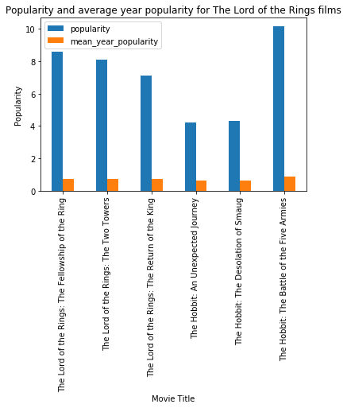

```python
LOTR_plot = create_pop_plot(LOTR_df,'The Lord of the Rings')
```

## Star Trek Into Darkness (Star Trek)

```python
find_movies_by_title('Star Trek')
```

|  | popularity | original_title | cast | director | keywords | overview | runtime | genres | production_companies | release_date | vote_count | vote_average | release_year |
| --- | --- | --- | --- | --- | --- | --- | --- | --- | --- | --- | --- | --- | --- |
| 277 | 0.444193 | Star Trek: Renegades | Walter Koenig\|Sean Young\|Manu Intiraymi\|Bruce ... | Tim Russ | NaN | It is nearly ten years after Voyager's return ... | 88 | Action\|Science Fiction\|Adventure\|Fantasy | ST Renegades | 8/1/15 | 31 | 4.1 | 2015 |
| 1391 | 3.829570 | Star Trek | Chris Pine\|Zachary Quinto\|Leonard Nimoy\|Eric B... | J.J. Abrams | spacecraft\|teleportation\|space mission\|parachu... | The fate of the galaxy rests in the hands of b... | 127 | Science Fiction\|Action\|Adventure | Paramount Pictures\|Spyglass Entertainment\|Bad ... | 5/6/09 | 3417 | 7.3 | 2009 |
| 3948 | 1.204615 | Star Trek: Nemesis | Patrick Stewart\|Jonathan Frakes\|LeVar Burton\|B... | Stuart Baird | clone\|assassination\|ambush\|federation\|starfleet | En route to the honeymoon of William Riker to ... | 117 | Science Fiction\|Action\|Adventure\|Thriller | Paramount Pictures | 12/12/02 | 291 | 6.1 | 2002 |
| 4205 | 0.948788 | Star Trek: Generations | Patrick Stewart\|Jonathan Frakes\|Brent Spiner\|L... | David Carson | based on tv series\|death\|exploding planet\|moun... | Captain Jean-Luc Picard and the crew of the En... | 118 | Science Fiction\|Action\|Adventure\|Thriller | Paramount Pictures | 11/17/94 | 265 | 6.3 | 1994 |
| 5435 | 3.877342 | Star Trek Into Darkness | Chris Pine\|Zachary Quinto\|Zoe Saldana\|Karl Urb... | J.J. Abrams | spacecraft\|friendship\|sequel\|futuristic\|space | When the crew of the Enterprise is called back... | 132 | Action\|Adventure\|Science Fiction | Paramount Pictures\|Skydance Productions\|Bad Ro... | 5/5/13 | 3363 | 7.4 | 2013 |
| 7828 | 1.823058 | Star Trek: The Motion Picture | William Shatner\|Leonard Nimoy\|George Takei\|Jam... | Robert Wise | artificial intelligence\|uss enterprise\|starfle... | When a destructive space entity is spotted app... | 132 | Science Fiction\|Adventure\|Mystery | Paramount Pictures | 12/6/79 | 304 | 6.0 | 1979 |
| 7898 | 0.822880 | Star Trek III: The Search for Spock | William Shatner\|Leonard Nimoy\|DeForest Kelley\|... | Leonard Nimoy | NaN | Admiral Kirk and his bridge crew risk their ca... | 105 | Science Fiction\|Action\|Adventure\|Thriller | Paramount Pictures | 5/31/84 | 239 | 6.1 | 1984 |
| 8472 | 1.323991 | Star Trek: First Contact | James Cromwell\|Alfre Woodard\|Alice Krige\|Neal ... | Jonathan Frakes | federation\|starfleet\|borg\|enterprise-e\|cyborg | The Borg, a relentless race of cyborgs, are on... | 111 | Science Fiction\|Action\|Adventure\|Thriller | Paramount Pictures | 11/21/96 | 426 | 6.8 | 1996 |
| 8898 | 0.946056 | Star Trek II: The Wrath of Khan | William Shatner\|Leonard Nimoy\|DeForest Kelley\|... | Nicholas Meyer | uss enterprise\|genesis\|asteroid\|self sacrifice... | Admiral James T. Kirk is feeling old; the pros... | 113 | Science Fiction\|Action\|Adventure\|Drama\|Thriller | Paramount Pictures | 6/3/82 | 406 | 7.0 | 1982 |
| 9013 | 0.931643 | Star Trek: Insurrection | Patrick Stewart\|Jonathan Frakes\|Brent Spiner\|L... | Jonathan Frakes | space opera\|retribution\|lieutenant commander\|s... | When an alien race and factions within Starfle... | 103 | Science Fiction\|Action\|Adventure\|Thriller | Paramount Pictures | 12/10/98 | 230 | 6.2 | 1998 |
| 9195 | 1.190512 | Star Trek V: The Final Frontier | William Shatner\|Leonard Nimoy\|DeForest Kelley\|... | William Shatner | federation\|starfleet\|uss enterprise-a\|sha-ka-r... | Capt. Kirk and his crew must deal with Mr. Spo... | 107 | Science Fiction\|Action\|Adventure\|Thriller | Paramount Pictures | 6/9/89 | 216 | 5.3 | 1989 |
| 9322 | 1.282930 | Star Trek VI: The Undiscovered Country | William Shatner\|Leonard Nimoy\|DeForest Kelley\|... | Nicholas Meyer | farewell\|federation\|starfleet\|peace conference... | On the eve of retirement, Kirk and McCoy are c... | 113 | Science Fiction\|Action\|Adventure\|Thriller | Paramount Pictures | 12/5/91 | 237 | 6.6 | 1991 |
| 10487 | 0.971594 | Star Trek IV: The Voyage Home | William Shatner\|Leonard Nimoy\|DeForest Kelley\|... | Leonard Nimoy | saving the world\|san francisco\|uss enterprise-... | Fugitives of the Federation for their daring r... | 119 | Science Fiction\|Adventure | Paramount Pictures | 11/25/86 | 275 | 6.6 | 1986 |

Of this whole list, the only film I wont include in the Star Trek dataframe is *Star Trek Renegades* because it was fan made and is not an official film (as I learned via Google search). Also, how nice was it for the film makers to actually put Star Trek into the name of each film? That makes it so much easier to see the official names and data for each film.

```python
startrek_list = [
'Star Trek: The Motion Picture',
'Star Trek II: The Wrath of Khan',
'Star Trek III: The Search for Spock',
'Star Trek IV: The Voyage Home',
'Star Trek V: The Final Frontier',
'Star Trek VI: The Undiscovered Country',
'Star Trek: Generations',
'Star Trek: First Contact',
'Star Trek: Insurrection',
'Star Trek: Nemesis',
'Star Trek',
'Star Trek Into Darkness'
]
startrek_df = create_dataframe(startrek_list)
startrek_df
```

|  | mean_year_popularity | popularity | release_year | title | vote_average | vote_count |
| --- | --- | --- | --- | --- | --- | --- |
| 7828 | 0.589312 | 1.823058 | 1979 | Star Trek: The Motion Picture | 6.0 | 304 |
| 8898 | 0.543353 | 0.946056 | 1982 | Star Trek II: The Wrath of Khan | 7.0 | 406 |
| 7898 | 0.590843 | 0.822880 | 1984 | Star Trek III: The Search for Spock | 6.1 | 239 |
| 10487 | 0.509545 | 0.971594 | 1986 | Star Trek IV: The Voyage Home | 6.6 | 275 |
| 9195 | 0.563658 | 1.190512 | 1989 | Star Trek V: The Final Frontier | 5.3 | 216 |
| 9322 | 0.501090 | 1.282930 | 1991 | Star Trek VI: The Undiscovered Country | 6.6 | 237 |
| 4205 | 0.668825 | 0.948788 | 1994 | Star Trek: Generations | 6.3 | 265 |
| 8472 | 0.604768 | 1.323991 | 1996 | Star Trek: First Contact | 6.8 | 426 |
| 9013 | 0.626165 | 0.931643 | 1998 | Star Trek: Insurrection | 6.2 | 230 |
| 3948 | 0.701454 | 1.204615 | 2002 | Star Trek: Nemesis | 6.1 | 291 |
| 1391 | 0.600178 | 3.829570 | 2009 | Star Trek | 7.3 | 3417 |
| 5435 | 0.627627 | 3.877342 | 2013 | Star Trek Into Darkness | 7.4 | 3363 |

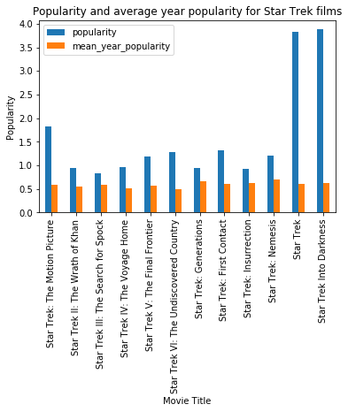

```python
startrek_plot = create_pop_plot(startrek_df, 'Star Trek')
```

## Riddick (The Chronicles of Riddick)

```python
riddick_list = [
'Pitch Black',
'The Chronicles of Riddick',
'Riddick'
]
riddick_df = create_dataframe(riddick_list)
riddick_df
```

|  | mean_year_popularity | popularity | release_year | title | vote_average | vote_count |
| --- | --- | --- | --- | --- | --- | --- |
| 8684 | 0.546799 | 1.144594 | 2000 | Pitch Black | 6.6 | 1245 |
| 7024 | 0.722438 | 1.052176 | 2004 | The Chronicles of Riddick | 6.2 | 1118 |
| 5437 | 0.627627 | 3.518275 | 2013 | Riddick | 6.2 | 1530 |

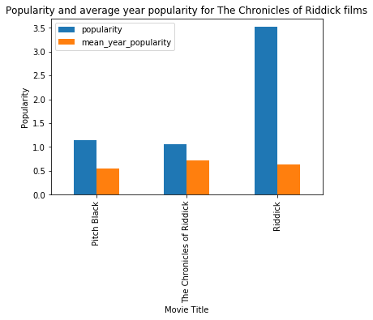

```python
riddick_plot = create_pop_plot(riddick_df, 'The Chronicles of Riddick')
```

## A Good Day to Die Hard (Die Hard)

```python
find_movies_by_title('Die Hard')
```

|  | popularity | original_title | cast | director | keywords | overview | runtime | genres | production_companies | release_date | vote_count | vote_average | release_year |
| --- | --- | --- | --- | --- | --- | --- | --- | --- | --- | --- | --- | --- | --- |
| 5442 | 2.815499 | A Good Day to Die Hard | Bruce Willis\|Jai Courtney\|Sebastian Koch\|Mary ... | John Moore | bomb\|cia\|russia\|escape\|courthouse | Iconoclastic, take-no-prisoners cop John McCla... | 98 | Action\|Thriller | Ingenious Media\|Twentieth Century Fox Film Cor... | 2/6/13 | 3003 | 5.2 | 2013 |
| 7398 | 2.227384 | Live Free or Die Hard | Bruce Willis\|Justin Long\|Timothy Olyphant\|Clif... | Len Wiseman | usa\|washington d.c.\|helicopter\|hostage\|fbi | John McClane is back and badder than ever, and... | 128 | Action\|Thriller | Ingenious Film Partners\|Twentieth Century Fox ... | 6/20/07 | 1393 | 6.3 | 2007 |
| 8073 | 2.230236 | Die Hard: With a Vengeance | Bruce Willis\|Jeremy Irons\|Samuel L. Jackson\|Gr... | John McTiernan | bomb\|taxi\|riddle\|robbery\|detective | New York detective John McClane is back and ki... | 128 | Action\|Thriller | Twentieth Century Fox Film Corporation\|Cinergi... | 5/19/95 | 1358 | 6.7 | 1995 |
| 9449 | 3.777441 | Die Hard | Bruce Willis\|Alan Rickman\|Alexander Godunov\|Bo... | John McTiernan | helicopter\|journalist\|based on novel\|terrorist... | NYPD cop John McClane's plan to reconcile with... | 131 | Action\|Thriller | Twentieth Century Fox Film Corporation\|Gordon ... | 7/15/88 | 2800 | 7.2 | 1988 |
| 9980 | 2.535646 | Die Hard 2 | Bruce Willis\|Bonnie Bedelia\|William Atherton\|R... | Renny Harlin | ambush\|helicopter\|journalist\|based on novel\|ai... | John McClane is an off-duty cop gripped with a... | 124 | Action\|Thriller | Twentieth Century Fox Film Corporation\|Gordon ... | 7/2/90 | 1252 | 6.4 | 1990 |

Again, so nice that all the movies in this series have 'Die Hard' somewhere in the name!

```python
diehard_list = [
'Die Hard',
'Die Hard 2',
'Die Hard: With a Vengeance',
'Live Free or Die Hard',
'A Good Day to Die Hard'
]
diehard_df = create_dataframe(diehard_list)
diehard_df
```

|  | mean_year_popularity | popularity | release_year | title | vote_average | vote_count |
| --- | --- | --- | --- | --- | --- | --- |
| 9449 | 0.465039 | 3.777441 | 1988 | Die Hard | 7.2 | 2800 |
| 9980 | 0.535735 | 2.535646 | 1990 | Die Hard 2 | 6.4 | 1252 |
| 8073 | 0.710722 | 2.230236 | 1995 | Die Hard: With a Vengeance | 6.7 | 1358 |
| 7398 | 0.593161 | 2.227384 | 2007 | Live Free or Die Hard | 6.3 | 1393 |
| 5442 | 0.627627 | 2.815499 | 2013 | A Good Day to Die Hard | 5.2 | 3003 |

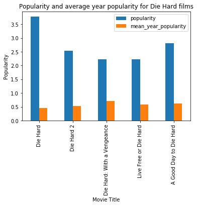

```python
diehard_plot = create_pop_plot(diehard_df, 'Die Hard')
```

### Looking at popularity scores

```python
ironman_pop = popularity_score(ironman_df)
LOTR_pop = popularity_score(LOTR_df)
startrek_pop = popularity_score(startrek_df)
riddick_pop = popularity_score(riddick_df)
diehard_pop = popularity_score(diehard_df)
pop_scores_2013 = pd.Series([ironman_pop, LOTR_pop, startrek_pop, riddick_pop, diehard_pop])
series_rankings_2013 = "{} pop score is {}, " * 5
series_rankings_2013.format('Iron Man', ironman_pop, 'Lord of the Rings', LOTR_pop, 'Star Trek',
                           startrek_pop, 'The Chronicles of Riddick', riddick_pop, 'Die Hard',
                           diehard_pop)
```

```
'Iron Man pop score is 4.590516145786914, Lord of the Rings pop score is 6.375363194221604, Star Trek pop score is 1.0021800178797307, The Chronicles of Riddick pop score is 1.272726645011296, Die Hard pop score is 2.1307844032348893, '
```

```python
pop_scores_2013.describe()
```

```
count    5.000000
mean     3.074314
std      2.325161
min      1.002180
25%      1.272727
50%      2.130784
75%      4.590516
max      6.375363
dtype: float64
```

Well... my hypothesis isn't looking too good right now. The popularity scores from these film series totally blows the ones examined in 2015 out of the water. I honestly thought that the Star Wars film series was vastly superior to all other film series... but Lord of the Rings is way more popular than Star Wars, plus the Iron Man film series strongly contends with the Star Wars series. I still think it's remarkable how the original Star Wars is so incredibly popular, especially considering its time period, but the series as a whole is not as unparalleled as I thought.

## 2011 release movies

```python
movies_df[(movies_df['release_year'] == 2011)]
```

|  | popularity | original_title | cast | director | keywords | overview | runtime | genres | production_companies | release_date | vote_count | vote_average | release_year |
| --- | --- | --- | --- | --- | --- | --- | --- | --- | --- | --- | --- | --- | --- |
| 3371 | 8.411577 | Underworld: Endless War | Trevor Devall\|Brian Dobson\|Paul Dobson\|Laura H... | Juno John Lee | paris\|france\|vampire\|night\|woman with gun | Underworld: Endless War is a collection of thr... | 18 | Action\|Animation\|Horror | NaN | 10/19/11 | 21 | 5.9 | 2011 |
| 3372 | 7.959228 | Captain America: The First Avenger | Chris Evans\|Hugo Weaving\|Tommy Lee Jones\|Hayle... | Joe Johnston | new york\|usa\|world war ii\|nazis\|marvel comic | Predominantly set during World War II, Steve R... | 124 | Action\|Adventure\|Science Fiction | Marvel Studios | 7/22/11 | 5025 | 6.5 | 2011 |
| 3373 | 5.903353 | Drive | Ryan Gosling\|Carey Mulligan\|Christina Hendrick... | Nicolas Winding Refn | drowning\|stuntman\|blood splatter\|extreme viole... | A mysterious Hollywood stuntman who moonlights... | 100 | Drama\|Action\|Thriller\|Crime | Bold Films\|Marc Platt Productions\|Odd Lot Ente... | 1/10/11 | 2347 | 7.3 | 2011 |
| 3374 | 5.711315 | Harry Potter and the Deathly Hallows: Part 2 | Daniel Radcliffe\|Rupert Grint\|Emma Watson\|Alan... | David Yates | self sacrifice\|magic\|frog\|sorcerer\|school | Harry, Ron and Hermione continue their quest t... | 130 | Adventure\|Family\|Fantasy | Warner Bros.\|Heyday Films\|Moving Picture Compa... | 7/7/11 | 3750 | 7.7 | 2011 |
| 3375 | 4.955130 | Pirates of the Caribbean: On Stranger Tides | Johnny Depp\|Penélope Cruz\|Geoffrey Rush\|Ian M... | Rob Marshall | sea\|captain\|mutiny\|sword\|prime minister | Captain Jack Sparrow crosses paths with a woma... | 136 | Adventure\|Action\|Fantasy | Walt Disney Pictures\|Jerry Bruckheimer Films\|M... | 5/11/11 | 3180 | 6.3 | 2011 |
| 3376 | 4.504530 | Rise of the Planet of the Apes | Andy Serkis\|Karin Konoval\|Freida Pinto\|James F... | Rupert Wyatt | intelligence\|zoo\|cage\|dystopia\|golden gate bridge | Scientist Will Rodman is determined to find a ... | 105 | Thriller\|Action\|Drama\|Science Fiction | 20th Century Fox | 8/3/11 | 2578 | 6.9 | 2011 |
| 3377 | 4.123520 | Thor | Chris Hemsworth\|Natalie Portman\|Tom Hiddleston... | Kenneth Branagh | new mexico\|banishment\|shield\|marvel comic\|hammer | Against his father Odin's will, The Mighty Tho... | 115 | Adventure\|Fantasy\|Action | Marvel Studios\|Marvel Entertainment | 4/21/11 | 4485 | 6.5 | 2011 |
| 3378 | 3.596188 | In Time | Justin Timberlake\|Amanda Seyfried\|Cillian Murp... | Andrew Niccol | bank\|future\|time\|dystopia\|cops and robbersÂ | In the not-too-distant future the aging gene h... | 109 | Action\|Thriller\|Science Fiction | Regency Enterprises\|Strike Entertainment\|New R... | 10/27/11 | 2068 | 6.6 | 2011 |
| 3379 | 3.355611 | Drive Angry | Nicolas Cage\|Amber Heard\|William Fichtner\|Bill... | Patrick Lussier | bone\|car explosion\|premarital sex\|satanic cult... | Milton is a hardened felon who has broken out ... | 105 | Fantasy\|Thriller\|Action\|Crime | Summit Entertainment\|Saturn Films\|Nu Image Fil... | 2/24/11 | 378 | 5.3 | 2011 |
| 3380 | 3.186679 | The Mechanic | Jason Statham\|Ben Foster\|Donald Sutherland\|Min... | Simon West | poison\|chicago\|prostitute\|martial arts\|assassin | Arthur Bishop is a 'mechanic' - an elite assas... | 93 | Action\|Thriller\|Crime | CBS Films\|Millennium Films\|Chartoff-Winkler Pr... | 1/13/11 | 678 | 6.3 | 2011 |
| 3381 | 2.994474 | Source Code | Jake Gyllenhaal\|Michelle Monaghan\|Vera Farmiga... | Duncan Jones | bomb\|identity\|fantasy\|bomber\|suspicion | Decorated soldier Captain Colter Stevens wakes... | 93 | Thriller\|Science Fiction\|Mystery | The Mark Gordon Company\|Vendome Pictures | 3/30/11 | 1668 | 7.0 | 2011 |
| 3382 | 2.952740 | Mission: Impossible - Ghost Protocol | Tom Cruise\|Jeremy Renner\|Simon Pegg\|Paula Patt... | Brad Bird | fight\|sequel\|mission\|explosion\|broken arm | In the 4th installment of the Mission Impossib... | 133 | Action\|Thriller\|Adventure | Paramount Pictures\|Skydance Productions\|Bad Ro... | 12/7/11 | 3036 | 6.7 | 2011 |
| 3383 | 2.924415 | Crazy, Stupid, Love. | Steve Carell\|Julianne Moore\|Ryan Gosling\|Emma ... | Glenn Ficarra\|John Requa | soulmates\|midlife crisis\|marriage crisis\|woman... | Cal Weaver is living the American dream. He ha... | 118 | Comedy\|Drama\|Romance | Warner Bros. | 7/29/11 | 1577 | 6.9 | 2011 |
| 3384 | 2.776061 | The Girl with the Dragon Tattoo | Daniel Craig\|Rooney Mara\|Christopher Plummer\|G... | David Fincher | journalist\|based on novel\|hacker\|punk\|investig... | This English-language adaptation of the Swedis... | 158 | Thriller\|Crime\|Mystery\|Drama | Columbia Pictures\|Scott Rudin Productions\|Film... | 12/14/11 | 1679 | 7.1 | 2011 |
| 3385 | 2.754426 | Limitless | Bradley Cooper\|Robert De Niro\|Abbie Cornish\|An... | Neil Burger | fictional place\|politician\|stalking\|superhuman... | A paranoia-fueled action thriller about an uns... | 105 | Thriller\|Mystery\|Science Fiction | Rogue Pictures\|Relativity Media\|Virgin Produce... | 3/8/11 | 2445 | 7.0 | 2011 |
| 3386 | 2.726573 | Kung Fu Panda 2 | Jack Black\|Angelina Jolie\|Dustin Hoffman\|Gary ... | Jennifer Yuh | martial arts\|hope\|fleet\|panda\|mission | Po is now living his dream as The Dragon Warri... | 91 | Animation\|Family | DreamWorks Animation | 5/25/11 | 1207 | 6.6 | 2011 |
| 3387 | 2.690458 | Just Go With It | Jennifer Aniston\|Adam Sandler\|Nicole Kidman\|Ba... | Dennis Dugan | beach\|fictitious marriage\|blackmail\|plastic su... | In Just Go With It, a plastic surgeon, romanci... | 117 | Romance\|Comedy | Columbia Pictures\|Happy Madison Productions | 2/10/11 | 1010 | 6.3 | 2011 |
| 3388 | 2.686643 | Horrible Bosses | Jennifer Aniston\|Jason Bateman\|Charlie Day\|Jas... | Seth Gordon | conspiracy of murder\|bad boss\|employee\|death o... | For Nick (Jason Bateman), Kurt (Jason Sudeikis... | 98 | Comedy\|Crime | New Line Cinema\|Rat Entertainment | 7/8/11 | 1417 | 6.4 | 2011 |
| 3389 | 2.657014 | Real Steel | Hugh Jackman\|Dakota Goyo\|Evangeline Lilly\|Anth... | Shawn Levy | father-son relationship\|fight\|sport\|robot\|priz... | In the near-future, Charlie Kenton is a washed... | 127 | Action\|Science Fiction\|Drama | DreamWorks SKG\|21 Laps Entertainment\|Reliance ... | 9/28/11 | 1856 | 6.5 | 2011 |
| 3390 | 2.633754 | Friends with Benefits | Justin Timberlake\|Mila Kunis\|Patricia Clarkson... | Will Gluck | funeral\|friends\|romance\|comedy\|three word title | While trying to avoid the clichés of Hollywoo... | 109 | Comedy | Castle Rock Entertainment\|Screen Gems\|Olive Br... | 7/21/11 | 1366 | 6.5 | 2011 |
| 3391 | 2.604249 | Bad Teacher | Jason Segel\|Cameron Diaz\|Justin Timberlake\|Luc... | Jake Kasdan | classroom\|teacher\|school\|workplace humor | A lazy, incompetent middle school teacher who ... | 92 | Comedy | Columbia Pictures\|Mosaic Media Group | 5/16/11 | 953 | 5.4 | 2011 |
| 3392 | 2.579776 | Sherlock Holmes: A Game of Shadows | Robert Downey Jr.\|Jude Law\|Jared Harris\|Noomi ... | Guy Ritchie | detective inspector\|steampunk\|criminal mastermind | There is a new criminal mastermind at large--P... | 129 | Adventure\|Action\|Crime\|Mystery | Village Roadshow Pictures\|Silver Pictures\|Lin ... | 11/22/11 | 2710 | 6.9 | 2011 |
| 3393 | 2.454226 | Cars 2 | Larry the Cable Guy\|Owen Wilson\|Michael Caine\|... | John Lasseter\|Brad Lewis | car race\|sequel\|comedy\|animation\|best friend | Star race car Lightning McQueen and his pal Ma... | 106 | Animation\|Family\|Adventure\|Comedy | Walt Disney Pictures\|Pixar Animation Studios | 6/11/11 | 1277 | 5.8 | 2011 |
| 3394 | 2.419805 | Green Lantern | Ryan Reynolds\|Blake Lively\|Peter Sarsgaard\|Tim... | Martin Campbell | dc comics\|transformation\|superhero\|alien\|alien... | For centuries, a small but powerful force of w... | 114 | Adventure\|Action\|Thriller\|Science Fiction | De Line Pictures\|Warner Bros.\|DC Entertainment | 6/16/11 | 1654 | 5.1 | 2011 |
| 3395 | 2.411533 | The Hangover Part II | Bradley Cooper\|Ed Helms\|Zach Galifianakis\|Just... | Todd Phillips | sun glasses\|interpol\|undercover cop\|hangover\|d... | The Hangover crew heads to Thailand for Stu's ... | 102 | Comedy | Legendary Pictures\|Living Films\|Green Hat Film... | 5/25/11 | 2601 | 6.1 | 2011 |
| 3396 | 2.252505 | No Strings Attached | Natalie Portman\|Ashton Kutcher\|Greta Gerwig\|Ke... | Ivan Reitman | alcohol\|waitress\|cemetery\|casual meeting\|resta... | Emma is a busy doctor who sets up a seemingly ... | 108 | Comedy\|Romance | Paramount Pictures\|Spyglass Entertainment\|Kata... | 1/12/11 | 859 | 6.1 | 2011 |
| 3397 | 2.234300 | The Adventures of Tintin | Jamie Bell\|Andy Serkis\|Daniel Craig\|Nick Frost... | Steven Spielberg | riddle\|captain\|treasure\|liquor\|treasure hunt | Intrepid young reporter, Tintin and his loyal ... | 107 | Adventure\|Animation\|Action\|Family\|Mystery | Paramount Pictures\|Columbia Pictures\|WingNut F... | 10/25/11 | 1448 | 6.6 | 2011 |
| 3398 | 2.208685 | Bridesmaids | Kristen Wiig\|Rose Byrne\|Maya Rudolph\|Wendi McL... | Paul Feig | competition\|tattoo\|alcohol\|jealousy\|fight | Annie’s life is a mess. But when she finds o... | 125 | Romance\|Comedy | Universal Pictures\|Relativity Media\|Apatow Pro... | 4/28/11 | 1145 | 6.5 | 2011 |
| 3399 | 2.164361 | Hall Pass | Owen Wilson\|Jason Sudeikis\|Jenna Fischer\|Chris... | Bobby Farrelly\|Peter Farrelly | wife husband relationship\|daydream\|marriage\|fr... | When best buds Rick and Fred begin to show sig... | 105 | Comedy | New Line Cinema\|Conundrum Entertainment | 2/25/11 | 423 | 5.4 | 2011 |
| 3400 | 2.026717 | Super 8 | Joel Courtney\|Elle Fanning\|Riley Griffiths\|Kyl... | J.J. Abrams | secret\|train crash\|pistol\|firecracker\|duringcr... | In 1979 Ohio, several youngsters are making a ... | 112 | Thriller\|Science Fiction\|Mystery | Paramount Pictures\|Amblin Entertainment\|Bad Ro... | 6/8/11 | 1527 | 6.6 | 2011 |
| ... | ... | ... | ... | ... | ... | ... | ... | ... | ... | ... | ... | ... | ... |
| 3881 | 0.055256 | Into the Abyss | Jason Burkett\|Werner Herzog\|Michael Perry\|Jere... | Werner Herzog | NaN | Legendary filmmaker Werner Herzog returns with... | 105 | Documentary\|Crime | Creative Differences | 11/11/11 | 36 | 7.1 | 2011 |
| 3882 | 0.047706 | October Baby | Rachel Hendrix \|Jason Burkey\|Robert Amaya \|Joh... | Andrew Erwin\|Jon Erwin | adoption\|college\|month in title | OCTOBER BABY is the coming of age story of a b... | 107 | Drama | NaN | 10/30/11 | 17 | 6.7 | 2011 |
| 3883 | 0.046695 | Chillar Party | Irrfan Khan\|Sanath Menon\|Rohan Grover\|Bachchan... | Nitesh Tiwari\|Vikas Bahl | NaN | A gang of innocent but feisty kids who lead ca... | 140 | Drama\|Comedy\|Family\|Foreign | NaN | 7/8/11 | 10 | 7.2 | 2011 |
| 3884 | 0.045198 | eCupid | Houston Rhines\|Andy Anderson\|John Callahan\|Gal... | J.C. Calciano | gay couple | From the director of Is It Just Me? comes this... | 0 | Romance | NaN | 6/23/11 | 12 | 4.6 | 2011 |
| 3885 | 0.084058 | Hollow | Emily Plumtree\|Sam Stockman\|Jessica Ellerby\|Ma... | Michael Axelgaard | hanging\|found footage | An old monastery in a small, remote village in... | 91 | Horror\|Thriller | NaN | 7/31/11 | 12 | 3.8 | 2011 |
| 3886 | 0.044221 | Mildred Pierce | Kate Winslet\|Evan Rachel Wood\|Guy Pearce\|Mare ... | Todd Haynes | infidelity\|business woman\|from rags to riches | A newly divorced, uniquely independent woman s... | 336 | Drama | Home Box Office (HBO)\|Metro-Goldwyn-Mayer (MGM) | 3/27/11 | 21 | 6.6 | 2011 |
| 3887 | 0.040690 | The Legend of Awesomest Maximus | Will Sasso\|Rip Torn\|Kristanna Loken\|Ian Zierin... | Jeff Kanew | parody | Spoof of sword-and-sandal flicks such as “Gl... | 87 | Comedy | NaN | 8/5/11 | 11 | 5.2 | 2011 |
| 3888 | 0.040279 | Fertile Ground | Leisha Hailey\|Jami Bassman \|Stephanie Brown\|Ka... | Adam Gierasch | possession | Emily and Nate Weaver leave the city for the r... | 95 | Horror | After Dark Films | 1/28/11 | 13 | 4.0 | 2011 |
| 3889 | 0.007304 | Suburban Knights | Brad Jones\|Lindsay Ellis\|Lewis Lovhaug\|Doug Wa... | Doug Walker | NaN | The Nostalgia Critic and his fellow reviewers ... | 130 | Adventure\|Comedy\|Fantasy | Channel Awesome | 9/20/11 | 10 | 6.3 | 2011 |
| 3890 | 0.030986 | Elle: A Modern Cinderella Tale | Ashlee Hewitt\|Sterling Knight\|Kiely Williams\|T... | John Dunson\|Sean Dunson | NaN | Elle wants to be a singer/songwriter, but her ... | 90 | Fantasy\|Drama\|Science Fiction\|Family | Frame Of Mind Entertainment | 4/26/11 | 17 | 4.9 | 2011 |
| 3891 | 0.028803 | Scrat's Continental Crack-Up: Part 2 | Chris Wedge | Steve Martino\|Mike Thurmeier | NaN | This short film continues the adventures of th... | 3 | Animation\|Comedy\|Adventure | Blue Sky Studios | 11/16/11 | 11 | 6.7 | 2011 |
| 3892 | 0.028207 | Bobby Fischer Against the World | Bobby Fischer\|Henry Kissinger | Liz Garbus | obsession\|child prodigy\|sport\|celebrity\|chess ... | The first documentary feature to explore the t... | 93 | Documentary\|Drama | NaN | 6/6/11 | 22 | 6.4 | 2011 |
| 3893 | 0.026495 | We Were Here | Ed Wolf\|Paul Boneberg\|Daniel Goldstein\|Guy Cla... | David Weissman\|Bill Weber | gay\|san francisco\|aids\|solidarity\|empowerment | 'We Were Here' is the first film to take a dee... | 90 | Documentary | NaN | 9/9/11 | 12 | 7.2 | 2011 |
| 3894 | 0.006925 | The Story of Film: An Odyssey | Mark Cousins\|Jean-Michel Frodon\|Cari Beauchamp... | Mark Cousins | cinema\|nouvelle vague\|hindi cinema\|cinema novo... | The Story of Film: An Odyssey, written and dir... | 900 | Documentary | NaN | 9/3/11 | 14 | 9.2 | 2011 |
| 3895 | 0.025338 | Blinkyâ„¢ | Max Records\|Jenni Fontana\|James Nardini\|Caroli... | Ruairi Robinson | short | A story about a boy, his robot and the consequ... | 13 | Science Fiction\|Horror | NaN | 3/21/11 | 21 | 6.7 | 2011 |
| 3896 | 0.025124 | Les Neiges du Kilimandjaro | Gérard Meylan\|Marilyne Canto\|Grégoire Leprin... | Robert Guédiguian | marseille\|solidarity | A man questions his essential goodness after b... | 90 | Drama\|Comedy\|Foreign | France 3 Cinéma\|Agat Films & Cie | 11/16/11 | 11 | 6.9 | 2011 |
| 3897 | 0.024766 | Donald Glover: Weirdo | Donald Glover | Shannon Hartman | stand up comedy | Donald Glover dispenses excess hysterics in hi... | 60 | Comedy | Art & Industry | 11/19/11 | 10 | 6.9 | 2011 |
| 3898 | 0.066670 | Kevin Hart: Laugh at My Pain | Kevin Hart\|Na'im Lynn | Leslie Small\|Tim Story | stand up comedy | Experience the show that quickly became a nati... | 89 | Comedy\|Documentary | Comedy Central Films\|Codeblack Entertainment\|H... | 9/9/11 | 36 | 7.6 | 2011 |
| 3899 | 0.018633 | Dear Santa | Amy Acker\|David Haydn-Jones\|Gina Holden\|James ... | Jason Priestley | holiday\|little girl\|rich parents\|letter to san... | Crystal, a rich party girl, finds a little gir... | 90 | Comedy\|Drama\|Romance | Nomadic Pictures\|ITV Studios America\|Annuit Co... | 8/11/11 | 11 | 7.4 | 2011 |
| 3900 | 0.017849 | Dhobi Ghat | Aamir Khan\|Prateik Babbar\|Monica Dogra\|Kriti M... | Kiran Rao | woman director | Arun (Aamir Khan) is a reclusive and lonely mo... | 100 | Drama\|Foreign | NaN | 1/21/11 | 10 | 6.4 | 2011 |
| 3901 | 0.017036 | The Other F Word | Tony Adolescent\|Art Alexakis\|Rob Chaos\|Chris D... | Andrea Blaugrund | NaN | What happens when a generation's ultimate anti... | 98 | Documentary\|Drama\|Comedy | NaN | 11/2/11 | 14 | 6.2 | 2011 |
| 3902 | 0.013745 | The Maker | NaN | Christopher Kezelos | NaN | A strange creature races against time to make ... | 6 | Drama\|Animation | Zealous Creative | 6/1/11 | 23 | 8.1 | 2011 |
| 3903 | 0.060639 | Une bouteille Ã la mer | Hiam Abbass\|Abraham Belaga\|Agathe Bonitzer\|Ree... | Thierry Binisti | NaN | Tai is 17 years old. Naim is 20. She's Israeli... | 100 | Drama | TS Productions\|France 3 (FR3) | 10/8/11 | 11 | 7.2 | 2011 |
| 3904 | 0.210188 | You Instead | Luke Treadaway\|Natalia Tena\|Alastair Mackenzie... | David Mackenzie | NaN | Two feuding rock stars get handcuffed together... | 80 | Comedy\|Music\|Romance\|Foreign | Sigma Films | 9/16/11 | 17 | 6.6 | 2011 |
| 3905 | 0.011771 | Dreams of a Life | Zawe Ashton\|Neelam Bakshi\|Lee Colley\|Frances C... | Carol Morley | woman director | A filmmaker sets out to discover the life of J... | 95 | Drama\|Documentary\|Foreign | Cannon and Morley Productions\|Soho Moon Pictures | 11/16/11 | 12 | 7.3 | 2011 |
| 3906 | 0.010997 | Pearl Jam: Twenty | Eddie Vedder\|Stone Gossard\|Jeff Ament\|Mike McC... | Cameron Crowe | seattle\|rock star\|musician\|musical\|grunge | Pearl Jam Twenty chronicles the years leading ... | 109 | Documentary\|Music | NaN | 9/20/11 | 22 | 7.9 | 2011 |
| 3907 | 0.004886 | There's Something Wrong with Aunt Diane | NaN | Liz Garbus | car crash\|dui\|driving under the influence | HBO: Documentary Revisits the mysterious trage... | 100 | Documentary | Moxie Firecracker Films | 7/25/11 | 11 | 6.4 | 2011 |
| 3908 | 0.004748 | August | Murray Bartlett\|Daniel Dugan\|Adrian Gonzalez | Eldar Rapaport | drama\|romance\|gay romance | August tells the story of two former lovers, T... | 100 | Drama | NaN | 6/9/11 | 12 | 6.4 | 2011 |
| 3909 | 0.003311 | The Pill | Noah Bean\|Rachel Boston\|Anna Chlumsky\|Jean Bra... | J.C. Khoury | pregnancy | Worried that he has gotten the free-spirited M... | 83 | Comedy\|Drama\|Romance | NaN | 12/16/11 | 34 | 5.9 | 2011 |
| 3910 | 0.002006 | Steve Jobs: One Last Thing | NaN | NaN | NaN | Through interviews with colleagues and others ... | 60 | Documentary | NaN | 11/2/11 | 11 | 6.6 | 2011 |

540 rows × 13 columns

The movies relesed in 2011 that are part of a big series are: *Harry Potter and the Deathly Hallows: Part 2 (Harry Potter), Pirates of the Caribbean: On Stranger Tides (Pirates of the Caribbean), Rise of the Planet of the Apes (Planet of the Apes), Mission: Impossible - Ghost Protocol (Mission Impossible)* and... those are actually the only movies I found that were part of a big series, so those are the ones I will examine.

## Harry Potter and the Deathly Hallows: Part 2 (Harry Potter)

```python
find_movies_by_title('Harry Potter')
```

|  | popularity | original_title | cast | director | keywords | overview | runtime | genres | production_companies | release_date | vote_count | vote_average | release_year |
| --- | --- | --- | --- | --- | --- | --- | --- | --- | --- | --- | --- | --- | --- |
| 1389 | 5.076472 | Harry Potter and the Half-Blood Prince | Daniel Radcliffe\|Rupert Grint\|Emma Watson\|Tom ... | David Yates | witch\|broom\|school of witchcraft\|magic wand\|ma... | As Harry begins his sixth year at Hogwarts, he... | 153 | Adventure\|Fantasy\|Family | Warner Bros.\|Heyday Films | 7/7/09 | 3220 | 7.3 | 2009 |
| 1923 | 4.840588 | Harry Potter and the Deathly Hallows: Part 1 | Daniel Radcliffe\|Emma Watson\|Rupert Grint\|Ralp... | David Yates | corruption\|isolation\|radio\|magic\|teleportation | Harry, Ron and Hermione walk away from their l... | 146 | Adventure\|Fantasy\|Family | Warner Bros.\|Heyday Films | 10/17/10 | 3467 | 7.4 | 2010 |
| 2634 | 8.021423 | Harry Potter and the Philosopher's Stone | Daniel Radcliffe\|Rupert Grint\|Emma Watson\|John... | Chris Columbus | witch\|christmas party\|magic\|cutting the cord\|h... | Harry Potter has lived under the stairs at his... | 152 | Adventure\|Fantasy\|Family | 1492 Pictures\|Warner Bros.\|Heyday Films | 11/16/01 | 4265 | 7.2 | 2001 |
| 3374 | 5.711315 | Harry Potter and the Deathly Hallows: Part 2 | Daniel Radcliffe\|Rupert Grint\|Emma Watson\|Alan... | David Yates | self sacrifice\|magic\|frog\|sorcerer\|school | Harry, Ron and Hermione continue their quest t... | 130 | Adventure\|Family\|Fantasy | Warner Bros.\|Heyday Films\|Moving Picture Compa... | 7/7/11 | 3750 | 7.7 | 2011 |
| 3912 | 6.012584 | Harry Potter and the Chamber of Secrets | Daniel Radcliffe\|Rupert Grint\|Emma Watson\|Kenn... | Chris Columbus | flying car\|witch\|magic language\|car journey\|cu... | Ignoring threats to his life, Harry returns to... | 161 | Adventure\|Fantasy\|Family | 1492 Pictures\|Warner Bros.\|Heyday Films\|MIRACL... | 11/13/02 | 3458 | 7.2 | 2002 |
| 6190 | 5.939927 | Harry Potter and the Goblet of Fire | Daniel Radcliffe\|Rupert Grint\|Emma Watson\|Ralp... | Mike Newell | diving\|library\|flying\|fireworks\|cutting the cord | Harry starts his fourth year at Hogwarts, comp... | 157 | Adventure\|Fantasy\|Family | Patalex IV Productions Limited\|Warner Bros.\|He... | 11/5/05 | 3406 | 7.3 | 2005 |
| 6962 | 5.827781 | Harry Potter and the Prisoner of Azkaban | Daniel Radcliffe\|Rupert Grint\|Emma Watson\|Gary... | Alfonso CuarÃ³n | flying\|traitor\|cutting the cord\|child hero\|broom | Harry, Ron and Hermione return to Hogwarts for... | 141 | Adventure\|Fantasy\|Family | 1492 Pictures\|Warner Bros.\|Heyday Films\|P of A... | 5/31/04 | 3550 | 7.4 | 2004 |
| 7388 | 4.878162 | Harry Potter and the Order of the Phoenix | Daniel Radcliffe\|Rupert Grint\|Emma Watson\|Mich... | David Yates | prophecy\|witch\|loss of lover\|cutting the cord\|... | Returning for his fifth year of study at Hogwa... | 138 | Adventure\|Fantasy\|Family\|Mystery | Cool Music\|Warner Bros.\|Heyday Films\|Harry Pot... | 6/28/07 | 3382 | 7.2 | 2007 |

```python
harrypotter_list = [
"Harry Potter and the Philosopher's Stone",
"Harry Potter and the Chamber of Secrets",
"Harry Potter and the Prisoner of Azkaban",
"Harry Potter and the Goblet of Fire",
"Harry Potter and the Order of the Phoenix",
"Harry Potter and the Half-Blood Prince",
"Harry Potter and the Deathly Hallows: Part 1",
"Harry Potter and the Deathly Hallows: Part 2"
]
harrypotter_df = create_dataframe(harrypotter_list)
harrypotter_df
```

|  | mean_year_popularity | popularity | release_year | title | vote_average | vote_count |
| --- | --- | --- | --- | --- | --- | --- |
| 2634 | 0.702658 | 8.021423 | 2001 | Harry Potter and the Philosopher's Stone | 7.2 | 4265 |
| 3912 | 0.701454 | 6.012584 | 2002 | Harry Potter and the Chamber of Secrets | 7.2 | 3458 |
| 6962 | 0.722438 | 5.827781 | 2004 | Harry Potter and the Prisoner of Azkaban | 7.4 | 3550 |
| 6190 | 0.628663 | 5.939927 | 2005 | Harry Potter and the Goblet of Fire | 7.3 | 3406 |
| 7388 | 0.593161 | 4.878162 | 2007 | Harry Potter and the Order of the Phoenix | 7.2 | 3382 |
| 1389 | 0.600178 | 5.076472 | 2009 | Harry Potter and the Half-Blood Prince | 7.3 | 3220 |
| 1923 | 0.644958 | 4.840588 | 2010 | Harry Potter and the Deathly Hallows: Part 1 | 7.4 | 3467 |
| 3374 | 0.675069 | 5.711315 | 2011 | Harry Potter and the Deathly Hallows: Part 2 | 7.7 | 3750 |

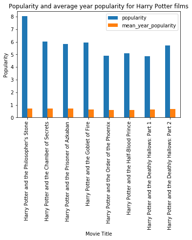

```python
harrypotter_plot = create_pop_plot(harrypotter_df, 'Harry Potter')
```

## Pirates of the Caribbean: On Stranger Tides (Pirates of the Caribbean)

```python
find_movies_by_title('Pirates of the Caribbean')
```

|  | popularity | original_title | cast | director | keywords | overview | runtime | genres | production_companies | release_date | vote_count | vote_average | release_year |
| --- | --- | --- | --- | --- | --- | --- | --- | --- | --- | --- | --- | --- | --- |
| 3375 | 4.955130 | Pirates of the Caribbean: On Stranger Tides | Johnny Depp\|PenÃ©lope Cruz\|Geoffrey Rush\|Ian M... | Rob Marshall | sea\|captain\|mutiny\|sword\|prime minister | Captain Jack Sparrow crosses paths with a woma... | 136 | Adventure\|Action\|Fantasy | Walt Disney Pictures\|Jerry Bruckheimer Films\|M... | 5/11/11 | 3180 | 6.3 | 2011 |
| 4951 | 6.864067 | Pirates of the Caribbean: The Curse of the Bla... | Johnny Depp\|Geoffrey Rush\|Orlando Bloom\|Keira ... | Gore Verbinski | exotic island\|east india trading company\|gold\|... | Jack Sparrow, a freewheeling 17th-century pira... | 143 | Adventure\|Fantasy\|Action | Walt Disney Pictures\|Jerry Bruckheimer Films | 7/9/03 | 4223 | 7.3 | 2003 |
| 6555 | 4.205992 | Pirates of the Caribbean: Dead Man's Chest | Johnny Depp\|Orlando Bloom\|Keira Knightley\|Bill... | Gore Verbinski | witch\|fortune teller\|bondage\|exotic island\|mon... | The high-seas adventures of happy-go-lucky tro... | 151 | Adventure\|Fantasy\|Action | Walt Disney Pictures\|Jerry Bruckheimer Films\|S... | 6/20/06 | 3181 | 6.8 | 2006 |
| 7387 | 4.965391 | Pirates of the Caribbean: At World's End | Johnny Depp\|Orlando Bloom\|Keira Knightley\|Geof... | Gore Verbinski | ocean\|drug abuse\|exotic island\|east india trad... | Captain Barbossa, long believed to be dead, ha... | 169 | Adventure\|Fantasy\|Action | Walt Disney Pictures\|Jerry Bruckheimer Films\|S... | 5/19/07 | 2626 | 6.8 | 2007 |

```python
POTC_list = [
"Pirates of the Caribbean: The Curse of the Black Pearl",
"Pirates of the Caribbean: Dead Man's Chest",
"Pirates of the Caribbean: At World's End",
"Pirates of the Caribbean: On Stranger Tides"
]
POTC_df = create_dataframe(POTC_list)
POTC_df
```

|  | mean_year_popularity | popularity | release_year | title | vote_average | vote_count |
| --- | --- | --- | --- | --- | --- | --- |
| 4951 | 0.719083 | 6.864067 | 2003 | Pirates of the Caribbean: The Curse of the Bla... | 7.3 | 4223 |
| 6555 | 0.606371 | 4.205992 | 2006 | Pirates of the Caribbean: Dead Man's Chest | 6.8 | 3181 |
| 7387 | 0.593161 | 4.965391 | 2007 | Pirates of the Caribbean: At World's End | 6.8 | 2626 |
| 3375 | 0.675069 | 4.955130 | 2011 | Pirates of the Caribbean: On Stranger Tides | 6.3 | 3180 |

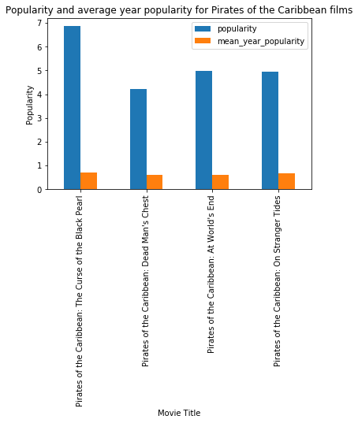

```python
POTC_plot = create_pop_plot(POTC_df, 'Pirates of the Caribbean')
```

## Rise of the Planet of the Apes (Planet of the Apes)

```python
find_movies_by_title('Apes')
```

|  | popularity | original_title | cast | director | keywords | overview | runtime | genres | production_companies | release_date | vote_count | vote_average | release_year |
| --- | --- | --- | --- | --- | --- | --- | --- | --- | --- | --- | --- | --- | --- |
| 651 | 4.452507 | Dawn of the Planet of the Apes | Andy Serkis\|Jason Clarke\|Toby Kebbell\|Keri Rus... | Matt Reeves | leader\|colony\|post-apocalyptic\|dystopia\|sequel | A group of scientists in San Francisco struggl... | 130 | Science Fiction\|Action\|Drama\|Thriller | Ingenious Media\|Chernin Entertainment\|TSG Ente... | 6/26/14 | 2625 | 7.4 | 2014 |
| 2650 | 1.862114 | Planet of the Apes | Mark Wahlberg\|Tim Roth\|Helena Bonham Carter\|Mi... | Tim Burton | gorilla\|space marine\|space suit\|revolution\|chimp | After a spectacular crash-landing on an unchar... | 119 | Thriller\|Science Fiction\|Action\|Adventure | Twentieth Century Fox Film Corporation\|Tim Bur... | 7/25/01 | 702 | 5.5 | 2001 |
| 3376 | 4.504530 | Rise of the Planet of the Apes | Andy Serkis\|Karin Konoval\|Freida Pinto\|James F... | Rupert Wyatt | intelligence\|zoo\|cage\|dystopia\|golden gate bridge | Scientist Will Rodman is determined to find a ... | 105 | Thriller\|Action\|Drama\|Science Fiction | 20th Century Fox | 8/3/11 | 2578 | 6.9 | 2011 |
| 7271 | 0.881814 | Conquest of the Planet of the Apes | Roddy McDowall\|Don Murray\|Joyce Haber\|Ricardo ... | J. Lee Thompson | circus\|pet\|human being\|dystopia\|insurrection | In a futuristic world that has embraced ape sl... | 88 | Action\|Science Fiction | Twentieth Century Fox Film Corporation\|APJAC P... | 6/29/72 | 109 | 6.1 | 1972 |
| 7934 | 0.368967 | Greystoke: The Legend of Tarzan, Lord of the Apes | Christopher Lambert\|Andie MacDowell\|Ralph Rich... | Hugh Hudson | england\|baby\|civilization\|shipwreck\|tarzan | A shipping disaster in the 19th Century has st... | 143 | Adventure\|Drama\|Action\|Romance | Warner Bros.\|Edgar Rice Burroughs Inc. | 3/30/84 | 54 | 6.2 | 1984 |
| 9720 | 1.152937 | Planet of the Apes | Charlton Heston\|Roddy McDowall\|Kim Hunter\|Maur... | Franklin J. Schaffner | human evolution\|gorilla\|bondage\|space marine\|c... | Taylor and two other astronauts come out of de... | 112 | Adventure\|Science Fiction\|Mystery | Twentieth Century Fox Film Corporation\|APJAC P... | 2/7/68 | 469 | 7.2 | 1968 |
| 9928 | 0.861630 | Escape from the Planet of the Apes | Roddy McDowall\|Kim Hunter\|Bradford Dillman\|Nat... | Don Taylor | spacecraft\|pacifism\|human being\|cage\|dystopia | The world is shocked by the appearance of two ... | 98 | Action\|Science Fiction | Twentieth Century Fox Film Corporation\|APJAC P... | 5/20/71 | 125 | 6.2 | 1971 |
| 10599 | 0.876503 | Battle for the Planet of the Apes | Roddy McDowall\|Lew Ayres\|Bobby Porter\|Richard ... | J. Lee Thompson | post-apocalyptic\|dystopia\|ape | The fifth and final episode in the Planet of t... | 93 | Action\|Science Fiction | Twentieth Century Fox Film Corporation\|Apjac I... | 6/14/73 | 99 | 5.3 | 1973 |
| 10649 | 0.797231 | Beneath the Planet of the Apes | James Franciscus\|Kim Hunter\|Maurice Evans\|Lind... | Ted Post | mutant\|dystopia\|survivor\|astronaut\|ape | Astronaut Brent is sent to rescue Taylor but c... | 95 | Adventure\|Science Fiction\|Mystery | Twentieth Century Fox Film Corporation\|APJAC P... | 5/1/70 | 163 | 5.9 | 1970 |

```python
POTA_list = [
"Beneath the Planet of the Apes",
"Escape from the Planet of the Apes",
"Conquest of the Planet of the Apes",
"Battle for the Planet of the Apes",
"Planet of the Apes",
"Rise of the Planet of the Apes"
]
POTA_df = create_dataframe(POTA_list)
POTA_original_film_df = pd.DataFrame({
    'mean_year_popularity' : [(popularity_by_year.get_group(1979).mean())],
    'popularity' : [1.152937],
    'release_year' : [1968],
    'title' : ['Planet of the Apes (1968)'],
    'revenue':[33395426],
    'budget':[5800000],
    'runtime':[112]
})
POTA_df = POTA_original_film_df.append(POTA_df)
POTA_df
```

|  | budget | mean_year_popularity | popularity | release_year | revenue | runtime | title | vote_average | vote_count |
| --- | --- | --- | --- | --- | --- | --- | --- | --- | --- |
| 0 | 5800000.0 | 0.589312 | 1.152937 | 1968 | 33395426.0 | 112.0 | Planet of the Apes (1968) | NaN | NaN |
| 10649 | NaN | 0.341700 | 0.797231 | 1970 | NaN | NaN | Beneath the Planet of the Apes | 5.9 | 163.0 |
| 9928 | NaN | 0.448112 | 0.861630 | 1971 | NaN | NaN | Escape from the Planet of the Apes | 6.2 | 125.0 |
| 7271 | NaN | 0.449054 | 0.881814 | 1972 | NaN | NaN | Conquest of the Planet of the Apes | 6.1 | 109.0 |
| 10599 | NaN | 0.494462 | 0.876503 | 1973 | NaN | NaN | Battle for the Planet of the Apes | 5.3 | 99.0 |
| 2650 | NaN | 0.702658 | 1.862114 | 2001 | NaN | NaN | Planet of the Apes | 5.5 | 702.0 |
| 3376 | NaN | 0.675069 | 4.504530 | 2011 | NaN | NaN | Rise of the Planet of the Apes | 6.9 | 2578.0 |

I had to manually add the original *Planet of the Apes* because my create_dataframe function does not account for multiple movies with the same title. It will only add the most recently made movie to the dataframe. Also, the row number for the orginal film is 0, which will not be an issue because that number is trivial.

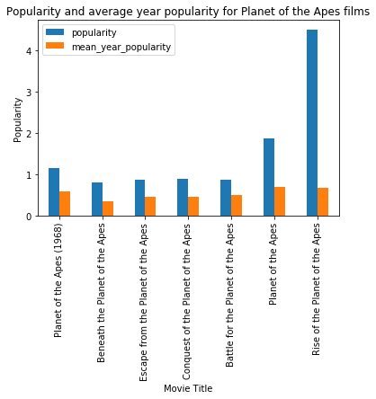

```python
POTA_plot = create_pop_plot(POTA_df, 'Planet of the Apes')
```

## Mission: Impossible - Ghost Protocol (Mission Impossible)

```python
find_movies_by_title('Mission: Impossible')
```

|  | popularity | original_title | cast | director | keywords | overview | runtime | genres | production_companies | release_date | vote_count | vote_average | release_year |
| --- | --- | --- | --- | --- | --- | --- | --- | --- | --- | --- | --- | --- | --- |
| 25 | 4.566713 | Mission: Impossible - Rogue Nation | Tom Cruise\|Jeremy Renner\|Simon Pegg\|Rebecca Fe... | Christopher McQuarrie | spy\|sequel\|mission | Ethan and team take on their most impossible m... | 131 | Action | Paramount Pictures\|Skydance Productions\|China ... | 7/23/15 | 2349 | 7.1 | 2015 |
| 3382 | 2.952740 | Mission: Impossible - Ghost Protocol | Tom Cruise\|Jeremy Renner\|Simon Pegg\|Paula Patt... | Brad Bird | fight\|sequel\|mission\|explosion\|broken arm | In the 4th installment of the Mission Impossib... | 133 | Action\|Thriller\|Adventure | Paramount Pictures\|Skydance Productions\|Bad Ro... | 12/7/11 | 3036 | 6.7 | 2011 |
| 6561 | 3.098051 | Mission: Impossible III | Tom Cruise\|Philip Seymour Hoffman\|Ving Rhames\|... | J.J. Abrams | berlin\|cia\|vatican\|white house\|secret identity | Retired from active duty to train new IMF agen... | 126 | Adventure\|Action\|Thriller | Paramount Pictures\|Cruise/Wagner Productions\|S... | 5/3/06 | 1363 | 6.3 | 2006 |
| 8458 | 3.293387 | Mission: Impossible | Tom Cruise\|Jon Voight\|Emmanuelle BÃ©art\|Henry ... | Brian De Palma | paris\|london\|cia\|terrorist\|secret identity | When Ethan Hunt, the leader of a crack espiona... | 110 | Adventure\|Action\|Thriller | Paramount Pictures\|Cruise/Wagner Productions | 5/21/96 | 1754 | 6.5 | 1996 |
| 8666 | 1.956406 | Mission: Impossible II | Tom Cruise\|Dougray Scott\|Thandie Newton\|Ving R... | John Woo | terror\|spain\|cia\|helicopter\|secret identity | With computer genius Luther Stickell at his si... | 123 | Adventure\|Action\|Thriller | Paramount Pictures\|Cruise/Wagner Productions\|M... | 5/23/00 | 1269 | 5.8 | 2000 |

```python
missionimpossible_list = [
'Mission: Impossible',
'Mission: Impossible II',
'Mission: Impossible III',
'Mission: Impossible - Ghost Protocol'
]
missionimpossible_df = create_dataframe(missionimpossible_list)
missionimpossible_df
```

|  | mean_year_popularity | popularity | release_year | title | vote_average | vote_count |
| --- | --- | --- | --- | --- | --- | --- |
| 8458 | 0.604768 | 3.293387 | 1996 | Mission: Impossible | 6.5 | 1754 |
| 8666 | 0.546799 | 1.956406 | 2000 | Mission: Impossible II | 5.8 | 1269 |
| 6561 | 0.606371 | 3.098051 | 2006 | Mission: Impossible III | 6.3 | 1363 |
| 3382 | 0.675069 | 2.952740 | 2011 | Mission: Impossible - Ghost Protocol | 6.7 | 3036 |

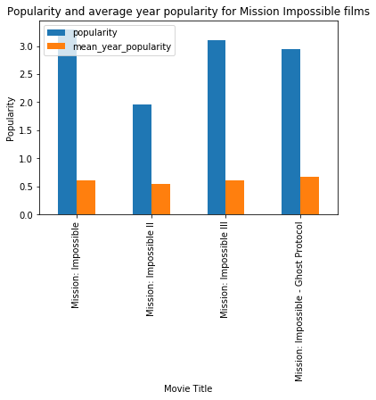

```python
missionimpossible_plot = create_pop_plot(missionimpossible_df, 'Mission Impossible')
```

### Looking at popularity scores

```python
harrypotter_pop = popularity_score(harrypotter_df)
POTC_pop = popularity_score(POTC_df)
POTA_pop = popularity_score(POTA_df)
missionimpossible_pop = popularity_score(missionimpossible_df)
pop_scores_2011 = pd.Series([harrypotter_pop, POTC_pop, POTA_pop, missionimpossible_pop])
series_rankings_2011 = "{} pop score is {}, " * 4
series_rankings_2011.format('Harry Potter', harrypotter_pop,
                            'Pirates of the Caribbean', POTC_pop,
                            'Planet of the Apes', POTA_pop,
                            'Mission Impossible', missionimpossible_pop)
```

```
'Harry Potter pop score is 5.129958942077217, Pirates of the Caribbean pop score is 4.59922410450455, Planet of the Apes pop score is 1.0337703770019826, Mission Impossible pop score is 2.216894067461826, '
```

```python
pop_scores_2011.describe()
```

```
count    4.000000
mean     3.244962
std      1.943668
min      1.033770
25%      1.921113
50%      3.408059
75%      4.731908
max      5.129959
dtype: float64
```

The more investigate, the more my hypothesis becomes disproved. I'll show again the 2015 popularity scores.

```python
pop_scores_2015.describe()
```

```
count    6.000000
mean     1.816862
std      1.864678
min     -0.104213
25%      0.437785
50%      1.436706
75%      2.776084
max      4.804618
dtype: float64
```

The mean popularity score for 2011 is almost twice that of 2015, and the 2011 minimum is well away from the negative (2015's is negative). The best thing going for 2015 is still that Star Wars has a very high popularity score still. So it appears that movie series trend opposite of what I predicted: They tend to become more popular after more time has passed. I'll now investigate 2009 movie series.

## 2009 Release Movies

```python
movies_df[(movies_df['release_year'] == 2009)]
```

|  | popularity | original_title | cast | director | keywords | overview | runtime | genres | production_companies | release_date | vote_count | vote_average | release_year |
| --- | --- | --- | --- | --- | --- | --- | --- | --- | --- | --- | --- | --- | --- |
| 1386 | 9.432768 | Avatar | Sam Worthington\|Zoe Saldana\|Sigourney Weaver\|S... | James Cameron | culture clash\|future\|space war\|space colony\|so... | In the 22nd century, a paraplegic Marine is di... | 162 | Action\|Adventure\|Fantasy\|Science Fiction | Ingenious Film Partners\|Twentieth Century Fox ... | 12/10/09 | 8458 | 7.1 | 2009 |
| 1387 | 6.098027 | Inglourious Basterds | Brad Pitt\|Mélanie Laurent\|Christoph Waltz\|Eli... | Quentin Tarantino | paris\|guerilla\|cinema\|self sacrifice\|dynamite | In Nazi-occupied France during World War II, a... | 153 | Drama\|Action\|Thriller\|War | Universal Pictures\|A Band Apart\|Zehnte Babelsb... | 8/18/09 | 3969 | 7.7 | 2009 |
| 1388 | 5.806897 | Underworld: Rise of the Lycans | Bill Nighy\|Michael Sheen\|Rhona Mitra\|Shane Bro... | Patrick Tatopoulos | prison\|underworld\|slavery\|castle\|vampire | A prequel to the first two Underworld films, t... | 92 | Fantasy\|Action\|Adventure\|Science Fiction\|Thriller | Lakeshore Entertainment\|Screen Gems\|Sketch Fil... | 1/22/09 | 979 | 6.2 | 2009 |
| 1389 | 5.076472 | Harry Potter and the Half-Blood Prince | Daniel Radcliffe\|Rupert Grint\|Emma Watson\|Tom ... | David Yates | witch\|broom\|school of witchcraft\|magic wand\|ma... | As Harry begins his sixth year at Hogwarts, he... | 153 | Adventure\|Fantasy\|Family | Warner Bros.\|Heyday Films | 7/7/09 | 3220 | 7.3 | 2009 |
| 1390 | 4.908902 | Up | Ed Asner\|Christopher Plummer\|Jordan Nagai\|Bob ... | Bob Peterson\|Pete Docter | central and south america\|balloon\|animation\|ti... | After a lifetime of dreaming of traveling the ... | 96 | Animation\|Comedy\|Family\|Adventure | Walt Disney Pictures\|Pixar Animation Studios | 5/13/09 | 4225 | 7.6 | 2009 |
| 1391 | 3.829570 | Star Trek | Chris Pine\|Zachary Quinto\|Leonard Nimoy\|Eric B... | J.J. Abrams | spacecraft\|teleportation\|space mission\|parachu... | The fate of the galaxy rests in the hands of b... | 127 | Science Fiction\|Action\|Adventure | Paramount Pictures\|Spyglass Entertainment\|Bad ... | 5/6/09 | 3417 | 7.3 | 2009 |
| 1392 | 3.789633 | Terminator Salvation | Christian Bale\|Sam Worthington\|Anton Yelchin\|M... | McG | saving the world\|artificial intelligence\|proph... | All grown up in post-apocalyptic 2018, John Co... | 115 | Drama\|Action\|Thriller\|Science Fiction | Columbia Pictures\|The Halcyon Company\|Wonderla... | 5/20/09 | 1670 | 5.8 | 2009 |
| 1393 | 3.744956 | District 9 | Sharlto Copley\|Jason Cope\|Nathalie Boltt\|Sylva... | Neill Blomkamp | slum\|street gang\|refugee camp\|extraterrestrial... | Aliens land in South Africa and have no way ho... | 112 | Action\|Thriller\|Science Fiction | WingNut Films\|TriStar Pictures\|Key Creatives\|B... | 8/5/09 | 2141 | 7.1 | 2009 |
| 1394 | 3.431559 | Sherlock Holmes | Robert Downey Jr.\|Jude Law\|Rachel McAdams\|Mark... | Guy Ritchie | detective\|scotland yard\|coffin\|black magic\|arrest | Eccentric consulting detective Sherlock Holmes... | 128 | Adventure\|Drama\|Action\|Comedy\|Thriller | Village Roadshow Pictures\|Silver Pictures\|Warn... | 1/7/09 | 4118 | 6.9 | 2009 |
| 1395 | 3.244139 | (500) Days of Summer | Joseph Gordon-Levitt\|Zooey Deschanel\|Chloë Gr... | Marc Webb | date\|sex\|jealousy\|fight\|architect | Tom (Joseph Gordon-Levitt), greeting-card writ... | 95 | Comedy\|Drama\|Romance | Fox Searchlight Pictures\|Watermark\|Dune Entert... | 7/17/09 | 1778 | 7.3 | 2009 |
| 1396 | 3.154914 | Ice Age: Dawn of the Dinosaurs | Ray Romano\|John Leguizamo\|Denis Leary\|Queen La... | Carlos Saldanha | ice age\|bridge\|insanity\|jungle\|dinosaur | Times are changing for moody mammoth Manny, mo... | 94 | Animation\|Comedy\|Family\|Adventure | Blue Sky Studios\|Twentieth Century Fox Animation | 6/29/09 | 1392 | 6.4 | 2009 |
| 1397 | 3.153060 | The Hangover | Bradley Cooper\|Ed Helms\|Zach Galifianakis\|Just... | Todd Phillips | underwear\|tiger\|stag night\|hangover\|lost weekend | When three friends finally come to after a rau... | 100 | Comedy | Legendary Pictures\|Green Hat Films\|Warner Bros... | 6/5/09 | 4134 | 7.1 | 2009 |
| 1398 | 3.038063 | Watchmen | Malin Åkerman\|Billy Crudup\|Carla Gugino\|Jeffr... | Zack Snyder | dc comics\|secret identity\|mass murder\|retireme... | In a gritty and alternate 1985 the glory days ... | 162 | Action\|Mystery\|Science Fiction | Paramount Pictures\|DC Comics\|Lawrence Gordon P... | 3/5/09 | 1751 | 6.8 | 2009 |
| 1399 | 2.979786 | 2012 | John Cusack\|Amanda Peet\|Chiwetel Ejiofor\|Thand... | Roland Emmerich | white house\|u.s. president\|indian\|ambulance\|lo... | Dr. Adrian Helmsley, part of a worldwide geoph... | 158 | Action\|Adventure\|Science Fiction | Columbia Pictures\|Centropolis Entertainment\|Th... | 10/10/09 | 3533 | 5.6 | 2009 |
| 1400 | 2.846465 | 9 | Elijah Wood\|John C. Reilly\|Jennifer Connelly\|C... | Shane Acker | man vs machine\|hope\|post-apocalyptic\|dystopia\|... | When 9 first comes to life, he finds himself i... | 79 | Action\|Adventure\|Animation\|Science Fiction\|Thr... | Focus Films\|Starz Animation\|Relativity Media\|T... | 8/19/09 | 851 | 6.5 | 2009 |
| 1401 | 2.841562 | Angels & Demons | Tom Hanks\|Ewan McGregor\|Ayelet Zurer\|Stellan S... | Ron Howard | rome\|vatican\|symbolism\|christian\|illuminati | Harvard symbologist Robert Langdon investigate... | 138 | Thriller\|Mystery | Columbia Pictures\|Imagine Entertainment\|Panora... | 5/13/09 | 1275 | 6.3 | 2009 |
| 1402 | 2.463982 | The Princess and the Frog | Anika Noni Rose\|Bruno Campos\|Keith David\|Micha... | Ron Clements\|John Musker | based on novel\|voodoo\|kiss\|princess\|animation | A waitress, desperate to fulfill her dreams as... | 97 | Romance\|Family\|Animation\|Music | Walt Disney Pictures\|Walt Disney Animation Stu... | 12/8/09 | 706 | 6.5 | 2009 |
| 1403 | 2.367474 | The Blind Side | Sandra Bullock\|Quinton Aaron\|Kathy Bates\|Tim M... | John Lee Hancock | american football\|adoption\|education\|private s... | Oversized African-American, Michael Oher, the ... | 129 | Drama | Alcon Entertainment\|Left Tackle Pictures\|Zucke... | 11/20/09 | 1078 | 7.1 | 2009 |
| 1404 | 2.041804 | Zombieland | Jesse Eisenberg\|Woody Harrelson\|Emma Stone\|Abi... | Ruben Fleischer | survival\|zombies\|twinkie\|zombie spoof\|body count | Columbus has made a habit of running from what... | 88 | Comedy\|Horror | Columbia Pictures | 10/7/09 | 2165 | 7.1 | 2009 |
| 1405 | 1.971027 | The Twilight Saga: New Moon | Kristen Stewart\|Robert Pattinson\|Taylor Lautne... | Chris Weitz | moon\|cinema\|werewolf | Forks, Washington resident Bella Swan is reeli... | 130 | Adventure\|Fantasy\|Drama\|Romance | Summit Entertainment\|Maverick Films\|Imprint En... | 3/15/09 | 1388 | 5.6 | 2009 |
| 1406 | 1.926432 | He's Just Not That Into You | Jennifer Aniston\|Jennifer Connelly\|Drew Barrym... | Ken Kwapis | relationship\|ensemble cast\|duringcreditsstinger | Remember that really cute guy who said he'd ca... | 129 | Comedy\|Romance\|Drama | New Line Cinema\|Flower Films (II)\|Internationa... | 2/6/09 | 612 | 6.0 | 2009 |
| 1407 | 1.906998 | G.I. Joe: The Rise of Cobra | Dennis Quaid\|Channing Tatum\|Marlon Wayans\|Sien... | Stephen Sommers | terrorist\|secret\|hostage\|technology\|warhead | From the Egyptian desert to deep below the pol... | 118 | Adventure\|Action\|Thriller\|Science Fiction | Paramount Pictures\|Spyglass Entertainment\|Di B... | 8/4/09 | 1470 | 5.7 | 2009 |
| 1408 | 1.895894 | The Proposal | Sandra Bullock\|Ryan Reynolds\|Mary Steenburgen\|... | Anne Fletcher | fictitious marriage\|deportation\|immigration la... | When she learns she's in danger of losing her ... | 108 | Comedy\|Romance\|Drama | Touchstone Pictures\|Mandeville Films\|Kurtzman/... | 6/1/09 | 1084 | 6.7 | 2009 |
| 1409 | 1.874759 | The Pink Panther 2 | Steve Martin\|Jean Reno\|Emily Mortimer\|Andy Gar... | Harald Zwart | diamond\|clouseau\|pink panther | When legendary treasures from around the world... | 92 | Comedy\|Mystery | Columbia Pictures\|Robert Simonds Productions\|M... | 2/6/09 | 180 | 5.5 | 2009 |
| 1410 | 1.860267 | The Ugly Truth | Katherine Heigl\|Gerard Butler\|Eric Winter\|Bree... | Robert Luketic | romantic comedy\|romance\|tv morning show\|relati... | A romantically challenged morning show produce... | 96 | Comedy\|Romance | Lakeshore Entertainment\|Relativity Media | 7/24/09 | 584 | 6.3 | 2009 |
| 1411 | 1.849649 | Cloudy with a Chance of Meatballs | Bill Hader\|Anna Faris\|James Caan\|Mr. T\|Benjami... | Phil Lord\|Christopher Miller | weather\|food\|science | Inventor Flint Lockwood creates a machine that... | 90 | Animation\|Comedy\|Family | Columbia Pictures\|Sony Pictures Animation | 9/17/09 | 1116 | 6.4 | 2009 |
| 1412 | 1.826169 | Fantastic Mr. Fox | George Clooney\|Meryl Streep\|Jason Schwartzman\|... | Wes Anderson | fox\|tree\|peasant\|revenge\|title spoken by chara... | The Fantastic Mr. Fox bored with his current l... | 87 | Adventure\|Animation\|Comedy\|Family | Twentieth Century Fox Film Corporation\|Regency... | 10/23/09 | 711 | 7.5 | 2009 |
| 1413 | 1.753840 | Coraline | Dakota Fanning\|Teri Hatcher\|Jennifer Saunders\|... | Henry Selick | dream\|eye\|stuffed animal\|parallel worlds\|button | When Coraline moves to an old house, she feels... | 100 | Animation\|Family | Focus Features\|Laika Entertainment | 2/5/09 | 711 | 7.1 | 2009 |
| 1414 | 1.752134 | Night at the Museum: Battle of the Smithsonian | Ben Stiller\|Amy Adams\|Owen Wilson\|Hank Azaria\|... | Shawn Levy | museum\|theodore roosevelt\|duringcreditsstinger... | Hapless museum night watchman Larry Daley must... | 105 | Adventure\|Fantasy\|Action\|Comedy\|Family | Twentieth Century Fox Film Corporation\|1492 Pi... | 5/20/09 | 1108 | 5.9 | 2009 |
| 1415 | 1.732516 | 17 Again | Zac Efron\|Leslie Mann\|Matthew Perry\|Tyler Stee... | Burr Steers | high school\|bullying\|high school basketball\|fa... | On the brink of a midlife crisis, 30-something... | 102 | Comedy | New Line Cinema\|Offspring Entertainment | 3/11/09 | 765 | 6.0 | 2009 |
| ... | ... | ... | ... | ... | ... | ... | ... | ... | ... | ... | ... | ... | ... |
| 1889 | 0.058472 | Objectified | NaN | Gary Hustwit | NaN | A feature-length documentary about our complex... | 75 | Documentary | NaN | 3/14/09 | 46 | 7.2 | 2009 |
| 1890 | 0.086490 | Hamlet | David Tennant\|Patrick Stewart\|Penny Downie\|Oli... | Gregory Doran | shakespeare adaptation\|based on play | David Tennant stars in a film of the Royal Sha... | 185 | Drama | NHK Enterprises\|Illuminations\|BBC Wales | 12/26/09 | 13 | 6.4 | 2009 |
| 1891 | 0.050789 | Nightmares in Red, White and Blue | Lance Henriksen\|Larry Cohen\|Joe Dante\|John Car... | Andrew Monument | film director\|interview\|independent film\|filmm... | An exploration of the appeal of horror films, ... | 96 | Documentary\|Horror | NaN | 8/6/09 | 15 | 6.0 | 2009 |
| 1892 | 0.047028 | The Winning Season | Sam Rockwell\|Emma Roberts\|Shareeka Epps\|Emily ... | Jim Strouse | alcohol\|restaurant\|immigrant\|bus ride\|bicycle | A comedy centered on a has-been coach who is g... | 119 | Comedy\|Drama | Gigi Productions\|Sneaky Pete Productions | 1/19/09 | 21 | 6.1 | 2009 |
| 1893 | 0.044425 | Alien Trespass | Eric McCormack\|Jenni Baird\|Dan Lauria\|Robert P... | R. W. Goodwin | alien abduction | In 1957 a fiery object crashes into a mountain... | 90 | Action\|Adventure\|Comedy\|Science Fiction | Rangeland Productions | 4/3/09 | 11 | 5.8 | 2009 |
| 1894 | 0.043209 | Bring It On: Fight to the Finish | Christina Milian\|Nikki SooHoo\|Cody Longo\|Rache... | Bille Woodruff | cheerleader\|sport\|high school\|malibu\|cheerleading | Christina Milian stars as sassy cheer captain ... | 102 | Comedy | Universal Studios Home Entertainment | 7/31/09 | 59 | 5.4 | 2009 |
| 1895 | 0.056777 | Doctor Who: The Waters of Mars | David Tennant | NaN | NaN | The Doctor joins forces with his oldest compan... | 62 | Science Fiction\|Adventure\|Family | BBC Wales | 12/19/09 | 25 | 8.0 | 2009 |
| 1896 | 0.135759 | Logorama | Bob Stephenson\|Sherman Augustus\|Aja Evans\|Joel... | François Alaux\|Hervé de Crécy\|Ludovic Houplain | zoo\|delinquent\|police\|criminal | Logorama's plot involves the adventures of two... | 16 | Animation | H5\|Autour de Minuit Productions\|Little Minx Films | 1/1/09 | 26 | 7.2 | 2009 |
| 1897 | 0.020701 | Jonas Brothers: The Concert Experience | Nick Jonas\|Joe Jonas\|Kevin Jonas\|John Lloyd Ta... | Bruce Hendricks | duringcreditsstinger | Secure your VIP pass to a once-in-a-lifetime e... | 76 | NaN | NaN | 2/27/09 | 11 | 7.0 | 2009 |
| 1898 | 0.029831 | R.T.T. | Kad Merad\|Mélanie Doutey\|Manu Payet\|Francis R... | Frédéric Berthe | NaN | When Florence, his companion of five years, sh... | 88 | Comedy | LGM Productions\|Studio Canal | 12/9/09 | 32 | 4.7 | 2009 |
| 1899 | 0.027045 | Alma | NaN | Rodrigo Blaas | shop\|store window\|toy shop\|child in peril\|doll | Alma, a little girl, skips through the snow co... | 6 | Animation\|Fantasy\|Mystery | NaN | 1/1/09 | 28 | 7.2 | 2009 |
| 1900 | 0.026174 | Waking Sleeping Beauty | Tim Burton\|John Lasseter\|Don Bluth\|Howard Ashm... | Don Hahn | NaN | By the mid-1980s, the fabled animation studios... | 86 | Documentary\|Family | NaN | 9/5/09 | 11 | 6.9 | 2009 |
| 1901 | 0.023254 | Kurbaan | Saif Ali Khan\|Kareena Kapoor\|Vivek Oberoi\|Dia ... | Renzil D'Silva | NaN | When a handsome young Indian couple (Saif Ali ... | 155 | Foreign\|Romance\|Thriller | NaN | 11/20/09 | 10 | 4.9 | 2009 |
| 1902 | 0.024051 | The Yes Men Fix the World | Andy Bichlbaum\|Mike Bonanno\|Reggie Watts | Andy Bichlbaum\|Mike Bonanno\|Kurt Engfehr | NaN | THE YES MEN FIX THE WORLD is a screwball true ... | 87 | Documentary | Renegade Pictures | 1/18/09 | 15 | 6.5 | 2009 |
| 1903 | 0.021121 | Deadline | Brittany Murphy\|Thora Birch\|Tammy Blanchard\|Ma... | Sean McConville | mental breakdown\|independent film\|writer\|bathtub | A screenwriter who travels to an abandoned hou... | 89 | Drama\|Horror\|Thriller | Enso Entertainment\|Films In Motion\|KRU Studios | 1/1/09 | 11 | 5.6 | 2009 |
| 1904 | 0.021041 | Today's Special | Aasif Mandvi\|Jess Weixler\|Naseeruddin Shah\|Aar... | David Kaplan | indian food\|queens new york city\|business card... | In this super-feel-good foodie comedy, young M... | 99 | Comedy\|Romance | Inimitable Pictures\|Sweet180 | 10/14/09 | 18 | 6.3 | 2009 |
| 1905 | 0.015926 | Un'estate ai Caraibi | Enrico Brignano\|Carlo Buccirosso\|Biagio Izzo | Carlo Vanzina | NaN | Several groups of Italians experience amusing ... | 110 | Comedy | Medusa Film | 6/12/09 | 12 | 4.2 | 2009 |
| 1906 | 0.169317 | Table for Three | Jesse Bradford\|Sophia Bush\|Brandon Routh\|Jenni... | Michael Samonek | roommate\|romantic comedy\|independent film\|room... | A suddenly single guy invites what he thinks i... | 93 | Comedy\|Romance | Starz Media | 1/1/09 | 12 | 4.3 | 2009 |
| 1907 | 0.015310 | Los Bandoleros | Vin Diesel\|Michelle Rodriguez\|Sung Kang\|Don Om... | Vin Diesel | NaN | The film tells the back story about the charac... | 20 | Action\|Drama | NaN | 7/28/09 | 42 | 5.9 | 2009 |
| 1908 | 0.013174 | Long Weekend | Jim Caviezel\|Claudia Karvan\|Robert Taylor\|John... | Jamie Blanks | NaN | Mother Nature gets revenge on some careless ca... | 87 | Drama\|Horror\|Thriller\|Foreign | NaN | 8/14/09 | 10 | 6.0 | 2009 |
| 1909 | 0.012170 | Map of the Sounds of Tokyo | Rinko Kikuchi\|Sergi López\|Min Tanaka\|Manabu O... | Isabel Coixet | woman director | Ryu is a solitary girl whose fragile appearanc... | 109 | Drama\|Foreign\|Romance\|Thriller | NaN | 12/2/09 | 12 | 5.4 | 2009 |
| 1910 | 0.002460 | Talhotblond | NaN | Barbara Schroeder | fraud\|woman director\|online lying\|connect to r... | This is the true story of a love triangle that... | 83 | Documentary | NaN | 2/1/09 | 11 | 6.0 | 2009 |
| 1911 | 0.257762 | His Name Was Jason: 30 Years of Friday the 13th | Erich Anderson\|Diane Almeida\|Judie Aronson\|Dia... | Daniel Farrands | mass murder\|murder\|director\|horror movie\|jason... | A retrospective documentary about the groundbr... | 90 | Documentary\|Horror | Paramount Pictures | 2/3/09 | 16 | 6.9 | 2009 |
| 1912 | 0.005502 | Cencoroll | Kana Hanazawa\|RyÅhei Kimura\|Satomi Moriya\|Hiro... | Atsuya Uki | japan\|supernatural powers\|alien | Cencoroll is a short story about a town in Jap... | 25 | Animation\|Science Fiction | Aniplex\|Anime Innovation Tokyo | 7/28/09 | 11 | 6.0 | 2009 |
| 1913 | 0.139545 | De Dana Dan | Akshay Kumar\|Katrina Kaif\|Sunil Shetty\|Paresh ... | Priyadarshan | romantic comedy\|bollywood | Nitin (Akshay Kumar) and Ram (Suniel Shetty) a... | 166 | Action\|Comedy\|Foreign | Baba Arts Limited Productions | 11/27/09 | 11 | 4.4 | 2009 |
| 1914 | 0.004590 | Jean Charles | Selton Mello\|Luis Miranda\|Marek Oravec\|Renu Se... | Henrique Goldman | NaN | The tragic true story of Jean Charles de Menez... | 91 | Documentary\|Drama\|Foreign | NaN | 6/26/09 | 11 | 6.6 | 2009 |
| 1915 | 0.019105 | ThanksKilling | Lance Predmore\|Ryan E. Francis\|Lindsey Anderse... | Jordan Downey | slasher\|bestiality\|raped by animal\|evil puppet... | A homicidal turkey axes off college kids durin... | 66 | Comedy\|Horror\|Thriller | NaN | 11/17/09 | 10 | 4.1 | 2009 |
| 1916 | 0.003432 | Jim Jefferies: I Swear to God | Jim Jefferies | John Moffitt | stand-up\|stand up comedy | Jim Jefferies: I Swear to God: The easily offe... | 58 | Comedy | HBO | 5/16/09 | 11 | 7.0 | 2009 |
| 1917 | 0.005289 | Une semaine sur deux | Mathilde Seigner\|Bernard Campan\|Bertille Chabe... | Ivan Calbérac | NaN | A 12 year old girl and her 8 year old brother ... | 98 | Drama\|Family | Mandarin Films | 7/22/09 | 14 | 5.5 | 2009 |
| 1918 | 0.001423 | Circle of Eight | Austin Highsmith\|Jesse Johnson\|Ryan Doom\|Josh ... | Stephen Cragg | horror\|mystery\|t-horror | Jessica moves into a loft on the eighth floor ... | 84 | Mystery\|Horror | Bronson Avenue\|Paramount Pictures Digital Ente... | 10/27/09 | 11 | 4.3 | 2009 |

533 rows × 13 columns

It is becoming more and more difficult to find movies that are part of a big series. Not because they aren't being made, but because they are overlapping with series that I've already examined. That being said, the movies I'll examine are *Ice Age: Dawn of the Dinosaurs, The Pink Panther 2*, and *Merry Madagascar (Madagascar)*. This will be the last year I examine as well.

### Ice Age: Dawn of the Dinosaurs (Ice Age)

```python
find_movies_by_title('Ice Age')
```

|  | popularity | original_title | cast | director | keywords | overview | runtime | genres | production_companies | release_date | vote_count | vote_average | release_year |
| --- | --- | --- | --- | --- | --- | --- | --- | --- | --- | --- | --- | --- | --- |
| 1396 | 3.154914 | Ice Age: Dawn of the Dinosaurs | Ray Romano\|John Leguizamo\|Denis Leary\|Queen La... | Carlos Saldanha | ice age\|bridge\|insanity\|jungle\|dinosaur | Times are changing for moody mammoth Manny, mo... | 94 | Animation\|Comedy\|Family\|Adventure | Blue Sky Studios\|Twentieth Century Fox Animation | 6/29/09 | 1392 | 6.4 | 2009 |
| 3405 | 1.844119 | Ice Age: A Mammoth Christmas | Billy Gardell\|Ray Romano\|John Leguizamo\|Queen ... | Karen Disher | NaN | When Sid accidentally destroys Manny's heirloo... | 26 | Animation\|Family\|TV Movie | 20th Century Fox\|Blue Sky Studios | 11/24/11 | 107 | 6.1 | 2011 |
| 3574 | 0.534119 | 2012: Ice Age | Patrick Labyorteaux\|Julie McCullough\|Nick Afan... | Trey Stokes\|Travis Fort | NaN | Tells the story of a man trying to get his fam... | 91 | Action\|Adventure\|Science Fiction | NaN | 6/27/11 | 63 | 4.0 | 2011 |
| 3913 | 4.467513 | Ice Age | Ray Romano\|John Leguizamo\|Denis Leary\|Goran Vi... | Chris Wedge\|Carlos Saldanha | human evolution\|parents kids relationship\|squi... | With the impending ice age almost upon them, a... | 81 | Animation\|Comedy\|Family\|Adventure | Twentieth Century Fox Film Corporation\|Blue Sk... | 3/10/02 | 2270 | 6.9 | 2002 |
| 4375 | 3.135776 | Ice Age: Continental Drift | John Leguizamo\|Ray Romano\|Chris Wedge\|Denis Le... | Steve Martino\|Mike Thurmeier | blue footed booby\|prehistoric times\|melting ic... | Manny, Diego, and Sid embark upon another adve... | 88 | Animation\|Comedy\|Adventure\|Family | Blue Sky Studios\|Twentieth Century Fox Animation | 6/26/12 | 1920 | 6.2 | 2012 |
| 6560 | 3.145562 | Ice Age: The Meltdown | Ray Romano\|John Leguizamo\|Denis Leary\|Queen La... | Carlos Saldanha | mammoth\|sloth\|ice age\|barrier ice\|ice melting | Diego, Manny and Sid return in this sequel to ... | 91 | Animation\|Family\|Comedy\|Adventure | Blue Sky Studios\|Twentieth Century Fox Animation | 3/23/06 | 1775 | 6.4 | 2006 |

```python
iceage_list = [
'Ice Age',
'Ice Age: The Meltdown',
'Ice Age: Dawn of the Dinosaurs'
]
iceage_df = create_dataframe(iceage_list)
iceage_df
```

|  | mean_year_popularity | popularity | release_year | title | vote_average | vote_count |
| --- | --- | --- | --- | --- | --- | --- |
| 3913 | 0.701454 | 4.467513 | 2002 | Ice Age | 6.9 | 2270 |
| 6560 | 0.606371 | 3.145562 | 2006 | Ice Age: The Meltdown | 6.4 | 1775 |
| 1396 | 0.600178 | 3.154914 | 2009 | Ice Age: Dawn of the Dinosaurs | 6.4 | 1392 |

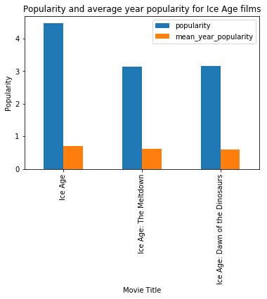

```python
iceage_plot = create_pop_plot(iceage_df, 'Ice Age')
```

### The Pink Panther 2 (Pink Panther)

```python
find_movies_by_title('Pink Panther')
```

|  | popularity | original_title | cast | director | keywords | overview | runtime | genres | production_companies | release_date | vote_count | vote_average | release_year |
| --- | --- | --- | --- | --- | --- | --- | --- | --- | --- | --- | --- | --- | --- |
| 1409 | 1.874759 | The Pink Panther 2 | Steve Martin\|Jean Reno\|Emily Mortimer\|Andy Gar... | Harald Zwart | diamond\|clouseau\|pink panther | When legendary treasures from around the world... | 92 | Comedy\|Mystery | Columbia Pictures\|Robert Simonds Productions\|M... | 2/6/09 | 180 | 5.5 | 2009 |
| 6621 | 0.956715 | The Pink Panther | Steve Martin\|Kevin Kline\|Jean Reno\|Beyoncé Kn... | Shawn Levy | robbery\|investigation\|inspector\|killer\|clouseau | When the coach of the France soccer team is ki... | 93 | Action\|Comedy\|Crime\|Mystery\|Family | Columbia Pictures\|International Production Com... | 1/18/06 | 307 | 5.6 | 2006 |
| 8025 | 0.453516 | Curse of the Pink Panther | David Niven\|Robert Wagner\|Herbert Lom\|Joanna L... | Blake Edwards | NaN | Inspector Clouseau disappears, and the Surete ... | 109 | Comedy | Blake Edwards | 8/12/83 | 13 | 4.3 | 1983 |
| 8908 | 0.582499 | Trail of the Pink Panther | Peter Sellers\|David Niven\|Herbert Lom\|Richard ... | Blake Edwards | robbery\|detective\|diamant\|airplane\|inspector | The Pink Panther diamond is stolen once again ... | 96 | Comedy\|Crime | United Artists\|Titan Productions\|Blake Edwards... | 12/3/82 | 26 | 5.7 | 1982 |
| 9810 | 0.790976 | The Return of the Pink Panther | Peter Sellers\|Christopher Plummer\|Herbert Lom\|... | Blake Edwards | robbery\|diamant\|côte d'azur\|inspector\|panther | The famous Pink Panther jewel has once again b... | 113 | Comedy | United Artists\|Jewel Productions\|Pimlico Films... | 5/21/75 | 58 | 6.6 | 1975 |
| 10191 | 0.360421 | The Pink Panther Strikes Again | Peter Sellers\|Herbert Lom\|Lesley-Anne Down\|Bur... | Blake Edwards | police\|laughing gas | Now seriously mentally ill after working with ... | 103 | Comedy\|Mystery | United Artists\|Amjo Productions | 12/15/76 | 47 | 6.6 | 1976 |
| 10331 | 0.336871 | Son of the Pink Panther | Roberto Benigni\|Herbert Lom\|Claudia Cardinale\|... | Blake Edwards | NaN | The eighth and last of the Pink Panther series... | 93 | Comedy\|Foreign | International Traders | 1/1/93 | 15 | 4.0 | 1993 |
| 10445 | 0.704895 | The Pink Panther | David Niven\|Peter Sellers\|Robert Wagner\|Capuci... | Blake Edwards | slapstick\|clouseau\|pink panther\|bumbling\|clums... | The trademark of The Phantom, a renowned jewel... | 115 | Comedy\|Crime | United Artists | 12/19/63 | 102 | 6.8 | 1963 |
| 10761 | 1.090065 | Revenge of the Pink Panther | Peter Sellers\|Andrew Sachs\|Herbert Lom\|Burt Kw... | Blake Edwards | inspector | Chief Inspector Jacques Clouseau is dead. At l... | 104 | Action\|Comedy\|Thriller\|Crime\|Family | United Artists\|Jewel Productions\|Pimlico Films... | 7/19/78 | 56 | 6.2 | 1978 |

I will employ a Google search to help me find all applicable films, as not all of them have 'Pink Panther' in the name.

```python
find_movies_by_title('The Pink Panther')
```

|  | popularity | original_title | cast | director | keywords | overview | runtime | genres | production_companies | release_date | vote_count | vote_average | release_year |
| --- | --- | --- | --- | --- | --- | --- | --- | --- | --- | --- | --- | --- | --- |
| 1409 | 1.874759 | The Pink Panther 2 | Steve Martin\|Jean Reno\|Emily Mortimer\|Andy Gar... | Harald Zwart | diamond\|clouseau\|pink panther | When legendary treasures from around the world... | 92 | Comedy\|Mystery | Columbia Pictures\|Robert Simonds Productions\|M... | 2/6/09 | 180 | 5.5 | 2009 |
| 6621 | 0.956715 | The Pink Panther | Steve Martin\|Kevin Kline\|Jean Reno\|BeyoncÃ© Kn... | Shawn Levy | robbery\|investigation\|inspector\|killer\|clouseau | When the coach of the France soccer team is ki... | 93 | Action\|Comedy\|Crime\|Mystery\|Family | Columbia Pictures\|International Production Com... | 1/18/06 | 307 | 5.6 | 2006 |
| 10191 | 0.360421 | The Pink Panther Strikes Again | Peter Sellers\|Herbert Lom\|Lesley-Anne Down\|Bur... | Blake Edwards | police\|laughing gas | Now seriously mentally ill after working with ... | 103 | Comedy\|Mystery | United Artists\|Amjo Productions | 12/15/76 | 47 | 6.6 | 1976 |
| 10445 | 0.704895 | The Pink Panther | David Niven\|Peter Sellers\|Robert Wagner\|Capuci... | Blake Edwards | slapstick\|clouseau\|pink panther\|bumbling\|clums... | The trademark of The Phantom, a renowned jewel... | 115 | Comedy\|Crime | United Artists | 12/19/63 | 102 | 6.8 | 1963 |

```python
pinkpanther_list = [
"A Shot in the Dark",
"The Return of the Pink Panther",
"The Pink Panther Strikes Again",
"Revenge of the Pink Panther",
"Trail of the Pink Panther",
"Curse of the Pink Panther",
"Son of the Pink Panther",
"The Pink Panther",
"The Pink Panther 2"
]
pinkpanther_df = create_dataframe(pinkpanther_list)
pinkpanther_original_film_df = pd.DataFrame({
    'title' : ['The Pink Panther (1963)'],
    'release_year' : [1963],
    'popularity' : [0.704895],
    'mean_year_popularity' : [(popularity_by_year.get_group(1963).mean())],
    'revenue':[10878107],
    'budget':[0],
    'runtime':[115]
})
pinkpanther_df = pinkpanther_original_film_df.append(pinkpanther_df)
pinkpanther_df
```

|  | budget | mean_year_popularity | popularity | release_year | revenue | runtime | title | vote_average | vote_count |
| --- | --- | --- | --- | --- | --- | --- | --- | --- | --- |
| 0 | 0.0 | 0.502706 | 0.704895 | 1963 | 10878107.0 | 115.0 | The Pink Panther (1963) | NaN | NaN |
| 9888 | NaN | 0.412428 | 0.626005 | 1964 | NaN | NaN | A Shot in the Dark | 7.1 | 44.0 |
| 9810 | NaN | 0.519445 | 0.790976 | 1975 | NaN | NaN | The Return of the Pink Panther | 6.6 | 58.0 |
| 10191 | NaN | 0.474516 | 0.360421 | 1976 | NaN | NaN | The Pink Panther Strikes Again | 6.6 | 47.0 |
| 10761 | NaN | 0.413314 | 1.090065 | 1978 | NaN | NaN | Revenge of the Pink Panther | 6.2 | 56.0 |
| 8908 | NaN | 0.543353 | 0.582499 | 1982 | NaN | NaN | Trail of the Pink Panther | 5.7 | 26.0 |
| 8025 | NaN | 0.541445 | 0.453516 | 1983 | NaN | NaN | Curse of the Pink Panther | 4.3 | 13.0 |
| 10331 | NaN | 0.547056 | 0.336871 | 1993 | NaN | NaN | Son of the Pink Panther | 4.0 | 15.0 |
| 6621 | NaN | 0.606371 | 0.956715 | 2006 | NaN | NaN | The Pink Panther | 5.6 | 307.0 |
| 1409 | NaN | 0.600178 | 1.874759 | 2009 | NaN | NaN | The Pink Panther 2 | 5.5 | 180.0 |

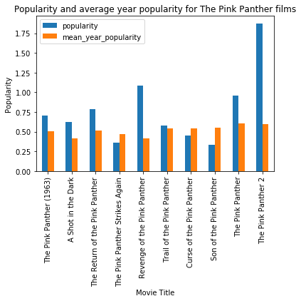

```python
pinkpanther_plot = create_pop_plot(pinkpanther_df, 'The Pink Panther')
```

### Merry Madagascar (Madagascar)

```python
find_movies_by_title('Madagascar')
```

|  | popularity | original_title | cast | director | keywords | overview | runtime | genres | production_companies | release_date | vote_count | vote_average | release_year |
| --- | --- | --- | --- | --- | --- | --- | --- | --- | --- | --- | --- | --- | --- |
| 672 | 3.007018 | Penguins of Madagascar | Tom McGrath\|Chris Miller\|Christopher Knights\|C... | Simon J. Smith\|Eric Darnell | penguin\|madagascar\|3d | Skipper, Kowalski, Rico and Private join force... | 92 | Family\|Animation\|Adventure\|Comedy | DreamWorks Animation | 11/22/14 | 939 | 6.5 | 2014 |
| 1447 | 1.124263 | Merry Madagascar | Cedric the Entertainer\|Andy Richter\|Carl Reine... | David Soren | holiday | The Zoosters are back in an all-new holiday ad... | 30 | Family\|Animation | DreamWorks Animation | 11/16/09 | 45 | 6.3 | 2009 |
| 2889 | 2.217084 | Madagascar: Escape 2 Africa | Ben Stiller\|Jada Pinkett Smith\|David Schwimmer... | Eric Darnell\|Tom McGrath | africa\|jealousy\|dance\|hunger\|lion | Alex, Marty, Melman, Gloria, King Julien, Maur... | 89 | Family\|Animation | DreamWorks Animation | 10/30/08 | 1147 | 6.1 | 2008 |
| 4433 | 1.204406 | Madagascar 3: Europe's Most Wanted | Ben Stiller\|Sacha Baron Cohen\|David Schwimmer\|... | Eric Darnell\|Tom McGrath\|Conrad Vernon | madagascar\|3d | Alex, Marty, Gloria and Melman are still tryin... | 93 | Animation\|Family | DreamWorks Animation | 6/6/12 | 1290 | 6.4 | 2012 |
| 5847 | 0.226483 | Madly Madagascar | Ben Stiller\|Chris Rock\|David Schwimmer\|Jada Pi... | David Soren | africa\|lion\|hippopotamus\|madagascar\|savannah | Your favorite Madagascar pals are back in an a... | 22 | Animation\|Comedy\|Family | DreamWorks Animation | 1/29/13 | 29 | 6.2 | 2013 |
| 6199 | 2.444998 | Madagascar | Ben Stiller\|Chris Rock\|David Schwimmer\|Jada Pi... | Eric Darnell\|Tom McGrath | lion\|hippopotamus\|giraffe\|penguin\|zebra | Zoo animals leave the comforts of man-made hab... | 86 | Family\|Animation | DreamWorks SKG\|Pacific Data Images (PDI)\|Dream... | 5/25/05 | 2107 | 6.4 | 2005 |
| 6366 | 0.417040 | The Madagascar Penguins in a Christmas Caper | Tom McGrath\|Chris Miller\|Christopher Knights\|J... | Gary Trousdale | holiday\|zoo\|penguin\|madagascar\|christmas eve | During the holiday season, when the animals of... | 11 | Animation\|Comedy\|Family | DreamWorks Animation | 9/23/05 | 34 | 6.3 | 2005 |

```python
madagascar_list = [
"Madagascar",
"The Madagascar Penguins in a Christmas Caper",
"Madagascar: Escape 2 Africa",
"Merry Madagascar"
]
madagascar_df = create_dataframe(madagascar_list)
madagascar_df
```

|  | mean_year_popularity | popularity | release_year | title | vote_average | vote_count |
| --- | --- | --- | --- | --- | --- | --- |
| 6199 | 0.628663 | 2.444998 | 2005 | Madagascar | 6.4 | 2107 |
| 6366 | 0.628663 | 0.417040 | 2005 | The Madagascar Penguins in a Christmas Caper | 6.3 | 34 |
| 2889 | 0.584817 | 2.217084 | 2008 | Madagascar: Escape 2 Africa | 6.1 | 1147 |
| 1447 | 0.600178 | 1.124263 | 2009 | Merry Madagascar | 6.3 | 45 |

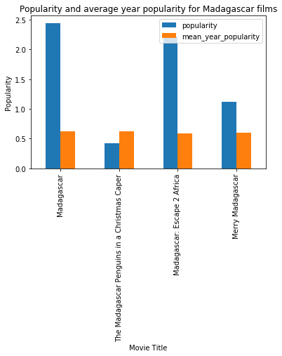

```python
madagascar_plot = create_pop_plot(madagascar_df, 'Madagascar')
```

### Looking at popularity scores

```python
iceage_pop = popularity_score(iceage_df)
pinkpanther_pop = popularity_score(pinkpanther_df)
madagascar_pop = popularity_score(madagascar_df)
pop_scores_2009 = pd.Series([iceage_pop, pinkpanther_pop, madagascar_pop])
series_rankings_2009 = "{} pop score is {}, " * 3
series_rankings_2009.format('Ice Age', iceage_pop,
                            'Pink Panther', pinkpanther_pop,
                            'Madagascar', madagascar_pop)
```

```
'Ice Age pop score is 2.953328531477427, Pink Panther pop score is 0.2615909402032953, Madagascar pop score is 0.9402657606479005, '
```

```python
pop_scores_2009.describe()
```

```
count    3.000000
mean     1.385062
std      1.399909
min      0.261591
25%      0.600928
50%      0.940266
75%      1.946797
max      2.953329
dtype: float64
```

```python
pop_scores_2015.describe()
```

```
count    6.000000
mean     1.816862
std      1.864678
min     -0.104213
25%      0.437785
50%      1.436706
75%      2.776084
max      4.804618
dtype: float64
```

2009 is the first year I've examined for which the mean popularity is actually worse than 2015's. 2015's max is also higher. Yet 2015 still has the record low, having the only movie series with a popularity score in the negative. I'll now create a graph to describe the popularity score mean, max, and min for each year.

## Looking at popularity score variables graphically

```python
pop_scores_df = pd.DataFrame ({
    'year' : [2015, 2013, 2011, 2009],
    'mean' : [
        pop_scores_2015.mean(),
        pop_scores_2013.mean(),
        pop_scores_2011.mean(),
        pop_scores_2009.mean()
    ],
    'min' : [
        pop_scores_2015.min(),
        pop_scores_2013.min(),
        pop_scores_2011.min(),
        pop_scores_2009.min()
    ],
    'max' : [
        pop_scores_2015.max(),
        pop_scores_2013.max(),
        pop_scores_2011.max(),
        pop_scores_2009.max()
    ]
})
```

```
Text(0.5,1,'Popularity scores by year')
```

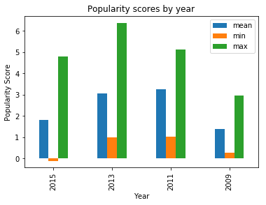

```python
pop_plot = pop_scores_df.plot(pop_scores_df['year'],['mean','min','max'], kind='bar')
pop_plot.set_xlabel('Year')
pop_plot.set_ylabel('Popularity Score')
pop_plot.set_title('Popularity scores by year')
```

Looking at this graph, popularity scores for series with movies released in 2015 are entirely worse than those in 2013 and 2011. 2009 only has a better minumum than 2015. For a pattern to emerge, it would be necessary to analyze many series over many years, not just 2015. I feel that if I widen my criteria to allow movies with only two movies in the series then that would dilute data because there isn't enough variety within that one series to give any clear conclusion (but I could be wrong about that).

## How does vote count correlate to year released?

There is an aspect of this data, vote_count, which I believe is how many people have voted any rating for a particular movie. My hypothesis is that the more recently a movie has been released, the higher vote_count value there will be for the movie. To examine this, I'll calculate the mean vote_count for each year and then compare that to the year released.

```
Text(0.5,1,'Mean vote count by year')
```

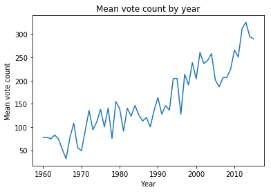

```python
vote_count_average = []
vote_count_by_year = release_year_gbo['vote_count']
plt.plot(vote_count_by_year.mean())
plt.xlabel('Year')
plt.ylabel('Mean vote count')
plt.title('Mean vote count by year')
```

There does appear to be a correlation between vote_count and how recently the movie was released. This graph looks similar to the mean popularity by year graph that was displayed earlier. I'll display that again for comparrison.

```
Text(0.5,1,'Mean popularity for movies by year')
```

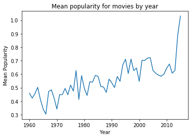

```python
plt.plot(popularity_by_year.mean())
plt.xlabel('Year')
plt.ylabel('Mean Popularity')
plt.title('Mean popularity for movies by year')
```

I'll standardize both of these sets of data and then plot them to see how they correlate.

```
Text(0.5,1,'Correlation between popularity and vote count by year')
```

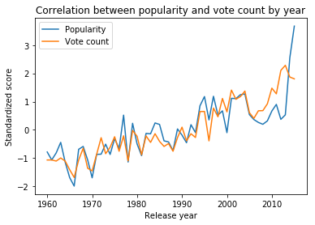

```python
std_pop = standardize_data(release_year_gbo['popularity'].mean())
std_vote_count = standardize_data(release_year_gbo['vote_count'].mean())
plt.plot(std_pop, label='Popularity')
plt.plot(std_vote_count, label='Vote count')
plt.legend()
plt.xlabel('Release year')
plt.ylabel('Standardized score')
plt.title('Correlation between popularity and vote count by year')
```

So graphically, the correlation between the vote count and popularity by year are similar, at least the shapes of the two graphs are. This indicates that there is a strong correlation between the two aspects of the data, which makes sense. The more votes a movie gets then the more popular it should be. That just means that more people are paying attention to it. I'll calculate the correlation coefficient now too.

```python
print ('Correlation coefficient = ' + str(std_pop.corr(std_vote_count)))
```

```
Correlation coefficient = 0.8491185299741839
```

That is pretty good. A correlation coefficient of about .85 strongly indicates that the two variables correlate to one another. There is another aspect of this data, vote_average, which I'll examine. vote_average is, I believe, rated out of 10. I want to compare vote_average to popularity to see if the two correlate at all.

```
Text(0.5,1,'Mean vote average by year')
```

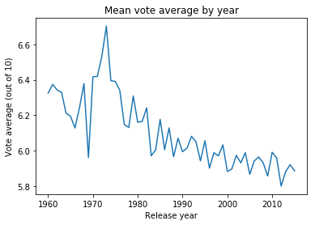

```python
vote_average_by_year = release_year_gbo['vote_average']
vote_average_by_year.mean().plot()
plt.xlabel('Release year')
plt.ylabel('Vote average (out of 10)')
plt.title('Mean vote average by year')
```

Well this is interesting. The average rating of movies has decreased over time. And graphically, this data is very different than the popularity graph. I'll standardize this data and then plot it with the popularity scores.

```
Text(0.5,1,'Mean vote average and popularity by year')
```

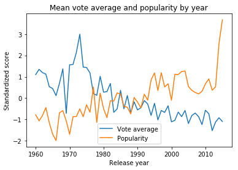

```python
std_vote_average = standardize_data(vote_average_by_year.mean())
plt.plot(std_vote_average, label = 'Vote average')
plt.plot(std_pop, label='Popularity')
plt.legend(loc='best')
plt.xlabel('Release year')
plt.ylabel('Standardized score')
plt.title('Mean vote average and popularity by year')
```

```python
print ('Correlation coefficient = ' + str(std_vote_average.corr(std_pop)))
```

```
Correlation coefficient = -0.5739689242050057
```

## Conclusion

So, to answer the question *Do movies in a movie series become more popular when a movie in that series has been released recently?*, the answer is: maybe. There is far more work that would need to be done to come to a more rigorous conclusion about this data, work such as:

Examining data from several different years of collected data.

Examining data for all years within the collected sets of data.

To anwser the fundamental question *Which factors most strongly influence the popularity of a movie?*, it's clear that the year the movie was releasd is a strong factor in its popularity. The movies released within the last two years of this data being collected have higher mean and max popularities than the rest of the years, with max being the biggest difference. However, this conclusion is only tenative. Far more extensive analysis would have to be done to arrive at a more rigorous conclusion.

The vote count of a movie seems to strongly influence its poularity as well. There was a very strong correlation between the mean vote count and mean popularities for the movies by year. The rating of the movies, however, seem not to be a strong influencer of popularity. The mean popularities of the movies rose (roughly) as time progressed, and, in fact, the average rating of the movies decreased. So the people who compile this data set are far more concerned with how many people are even paying attention to the movie and voting something for it, regardless of how good it actually is. However, this analysis is tenative and I cannot make any firm conclusions yet, so all my conclusions are tenative. Not enough analysis has been done to come to a firm conclusion.

### Limitations

Even if I examined this data set as thoroughly as possible, it is only for one year. To properly answer the question of whether movies in a series become more popular when a new movie in that series is released, it would be necessary to follow the popularity of several, if not all, series over the years as new movies in them are released. This would be impossible for some movies, however, such as movies that were released before this database became collected. There would be no way to know their popularities because this metric (as far as I know) did not exist at the time. Even if I collected data for every series over every year within this 2015 database, I could only partially answer the question. Also, it was a bit difficult to find information on what some of the different aspects of the movies mean. For example, the highest movie popularity was about 33. I was unable to find how high it could possibly be or what the score really meant. So I assumed that the popularity is a combination of several other factors and used to make a movie more likely to be suggested than another. Because I don't fully know what these aspects mean, I could be misinterpreting some of them and drawing a false conclusion because of that.